# Variation in the production of te reo Māori opening vowel sequences: Supplementary Materials

**Click here to view code.**

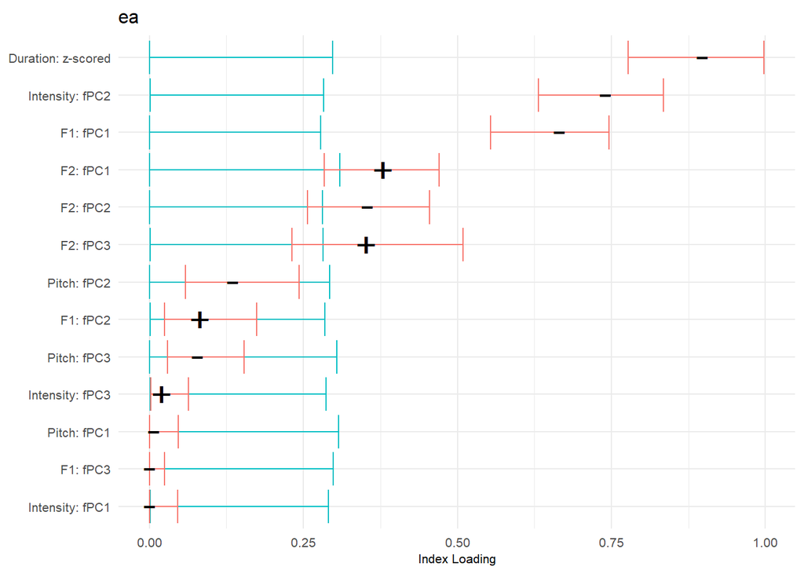

```r
eapc1_loadings_plot_horizonal <- plot_loadings_horizontal(ea_test, pc_no=1, filter_boots = FALSE) +
     theme_minimal() + theme(legend.position = "none", plot.title = element_text(size = 12), axis.title.y = element_blank(), text = element_text(size = 8), axis.text = element_text(size = 8))+  labs(title = "ea", subtitle = NULL)

eapc1_loadings_plot_horizonal
```

4. /oa/ uPC1 index loadings

**Click here to view code.**

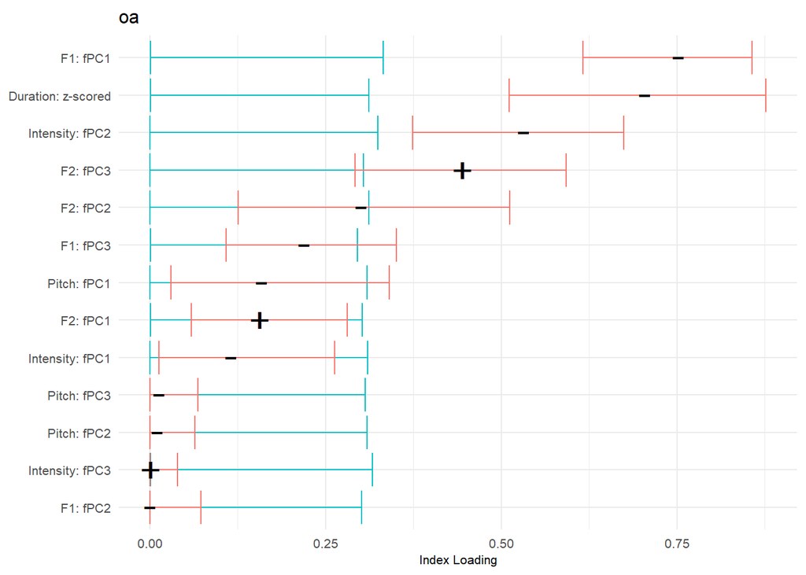

```r
oapc1_loadings_plot_horizonal  <- plot_loadings_horizontal(oa_test, pc_no=1, filter_boots = FALSE) +
     theme_minimal() + theme(legend.position = "none", plot.title = element_text(size = 12), axis.title.y = element_blank(), text = element_text(size = 8), axis.text = element_text(size = 8))+  labs(title = "oa", subtitle = NULL)

oapc1_loadings_plot_horizonal
```

5./ua/ uPC1 index loadings

**Click here to view code.**

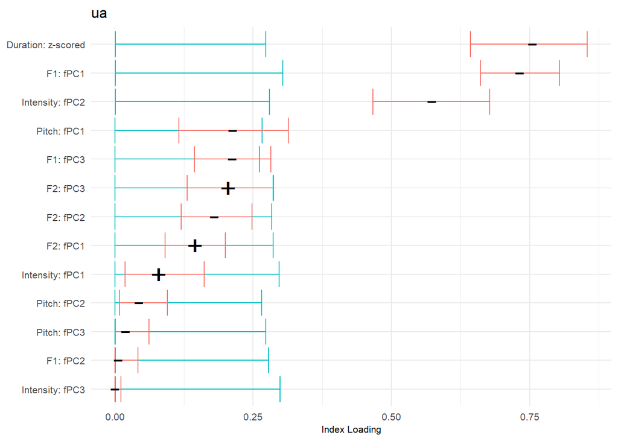

```r
uapc1_loadings_plot_horizonal <- plot_loadings_horizontal(ua_test, pc_no=1, filter_boots = FALSE) +
     theme_minimal() +  theme(legend.position = "none", plot.title = element_text(size = 12), axis.title.y = element_blank(), text = element_text(size = 8), axis.text = element_text(size = 8))+  labs(title = "ua", subtitle = NULL)


uapc1_loadings_plot_horizonal
```

6. Create combined plot of uPC1 loadings and save

**Click here to view code.**

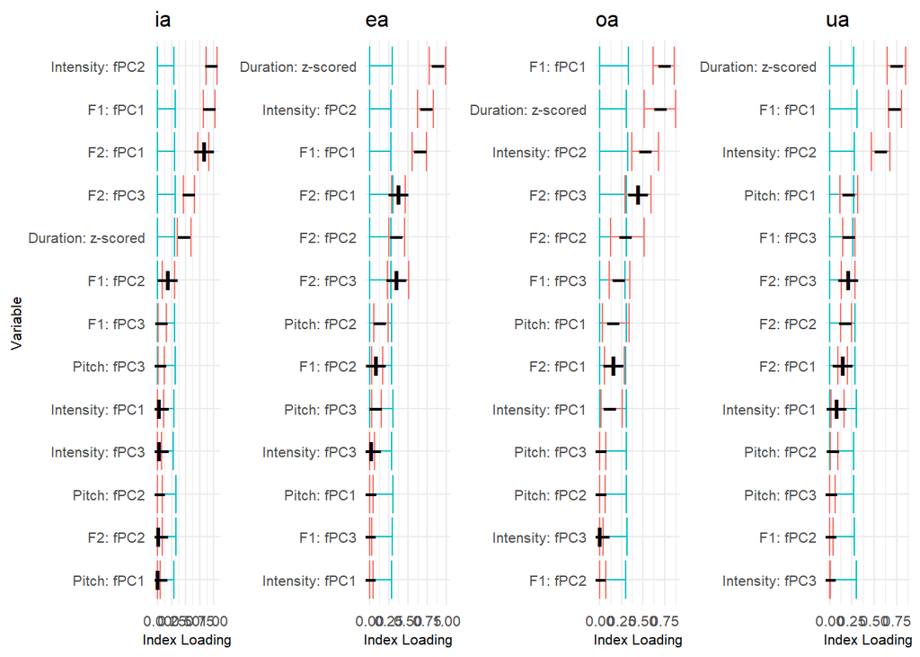

```r
  uPC1AllHorizontal <-  grid.arrange(iapc1_loadings_plot_horizonal, eapc1_loadings_plot_horizonal, oapc1_loadings_plot_horizonal, uapc1_loadings_plot_horizonal, nrow = 1)
```

**Click here to view code.**

```r
 ggsave(here( "Figures", "Plots", "uPCA", "uPC1AllHorizontal.png"), uPC1AllHorizontal,  width = 25, height =7 , units = "cm", bg = "white")
```

## 8.3 Prepare and save uPCA data

1. Prepare uPCA data

**Click here to view code.**

```r
ia_pca <- ia_data %>%
  # Remove the speaker column as this is not wanted by PCA.
  select(-sequence, -MatchId) %>%
  # We scale the variables (more on this in a moment)
  prcomp(scale = TRUE)

ea_pca <- ea_data %>%
  select(-sequence, -MatchId) %>%
  prcomp(scale = TRUE)

ua_pca <- ua_data %>%
  select(-sequence, -MatchId) %>%
  prcomp(scale = TRUE)

oa_pca <- oa_data %>%
  select(-sequence, -MatchId) %>%
  prcomp(scale = TRUE)
```

2. Add sequences details

**Click here to view code.**

```r
seqs_details <- read.csv(here("Data", "opening_seqs_selected_data.csv"))
```

3. Create data frames

**Click here to view code.**

```r
eaPCs = as.data.frame(ea_pca$x)
eaPCs2 = eaPCs %>% select(PC1,PC2,PC3, PC4)
iaPCs = as.data.frame(ia_pca$x)
iaPCs2 = iaPCs %>% select(PC1,PC2,PC3, PC4)
oaPCs = as.data.frame(oa_pca$x)
oaPCs2 = oaPCs %>% select(PC1,PC2,PC3, PC4)
uaPCs = as.data.frame(ua_pca$x)
uaPCs2 = uaPCs %>% select(PC1,PC2,PC3, PC4)
earesults = cbind(ea_data, eaPCs2)
iaresults = cbind(ia_data, iaPCs2)
oaresults = cbind(oa_data, oaPCs2)
uaresults = cbind(ua_data, uaPCs2)

earesults2 = left_join(earesults, seqs_details, by = c("MatchId", "sequence"))
iaresults2 = left_join(iaresults, seqs_details,by = c("MatchId", "sequence"))
oaresults2 = left_join(oaresults, seqs_details, by = c("MatchId", "sequence"))
uaresults2 = left_join(uaresults, seqs_details, by = c("MatchId", "sequence"))
```

4. Save as .csvs

**Click here to view code.**

```r
write.csv(earesults2, here("Data", "ea_uPCAresults.csv"))
write.csv(oaresults2, here("Data","oa_uPCAresults.csv"))
write.csv(iaresults2, here("Data", "ia_uPCAresults.csv"))
write.csv(uaresults2, here("Data","ua_uPCAresults.csv"))
```

## 8.4 uPCA visualisations

1. Read in uPCA data if need be

**Click here to view code.**

```r
earesults = read.csv(here("Data", "ea_uPCAresults.csv"))
oaresults = read.csv(here("Data","oa_uPCAresults.csv"))
iaresults = read.csv(here("Data", "ia_uPCAresults.csv"))
uaresults = read.csv(here("Data","ua_uPCAresults.csv"))
```

2. Define some PC categories, We’re calling everything above one ‘hi’, and below negative one ‘low’. Combine these into a single data frame of ‘extreme’ results.

**Click here to view code.**

```r
earesults$PC1cat = "mid"
earesults[earesults$PC1 > 1,]$PC1cat = "hi"
earesults[earesults$PC1 < -1,]$PC1cat = "low"
earesultsextreme = earesults %>% filter(PC1cat != "mid")


oaresults$PC1cat = "mid"
oaresults[oaresults$PC1 > 1,]$PC1cat = "hi"
oaresults[oaresults$PC1 < -1,]$PC1cat = "low"
oaresultsextreme = oaresults %>% filter(PC1cat != "mid")

#flip ua
uaresults$PC1cat = "mid"
uaresults[uaresults$PC1 > 1,]$PC1cat = "low"
uaresults[uaresults$PC1 < -1,]$PC1cat = "hi"
uaresultsextreme = uaresults %>% filter(PC1cat != "mid")

iaresults$PC1cat = "mid"
iaresults[iaresults$PC1 > 1,]$PC1cat = "hi"
iaresults[iaresults$PC1 < -1,]$PC1cat = "low"
iaresultsextreme = iaresults %>% filter(PC1cat != "mid")


uPC1_results_all <- rbind(earesults, oaresults, uaresults, iaresults)
results_extreme_all  <- rbind(earesultsextreme, oaresultsextreme, uaresultsextreme, iaresultsextreme)
```

3. Read in acoustic data

**Click here to view code.**

```r
int <- read.csv(here("Data", "int_filtered.csv")) %>%
select(MatchId, sequence, time,
            intensity = Measure)


pitch <- read.csv(here( "Data", "pitch_filtered.csv")) %>%
select(MatchId, sequence, time,
       pitch = Measure)

pitch_int <- left_join(int, pitch)


pitch_int = pitch_int %>%  group_by(MatchId) %>%
    mutate(c_pitch = scale(pitch, center=TRUE, scale=FALSE),
         c_intensity = scale(intensity, center=TRUE, scale=FALSE))

pitch = pitch_int


 formants_filtered <- read_csv(here("Data", "formants_filtered_all.csv")) %>%
  dplyr::select(Vowel, MatchId, time, Formant, Frequency)

 formants <- formants_filtered %>%
  pivot_wider(
    names_from = Formant,
    values_from = Frequency
  )
```

4. Combine with uPCA results

**Click here to view code.**

```r
earesultspitch = left_join(earesultsextreme, pitch, by="MatchId")
iaresultspitch = left_join(iaresultsextreme, pitch, by="MatchId")
oaresultspitch = left_join(oaresultsextreme, pitch,  by="MatchId")
uaresultspitch = left_join(uaresultsextreme, pitch,  by="MatchId")

earesultsformants = left_join(earesultsextreme, formants, by="MatchId")
iaresultsformants = left_join(iaresultsextreme, formants, by="MatchId")
oaresultsformants = left_join(oaresultsextreme, formants, by="MatchId")
uaresultsformants = left_join( uaresultsextreme,  formants, by="MatchId")


pc_pitch_results_all <- rbind(earesultspitch,iaresultspitch,oaresultspitch, uaresultspitch)
pc_formants_results_all <- rbind(earesultsformants, iaresultsformants, oaresultsformants, uaresultsformants)
```

### 8.4.1 Combined plot by uPC1 category (Manuscript Figure 3)

1. Plot duration by uPC1 category

**Click here to view code.**

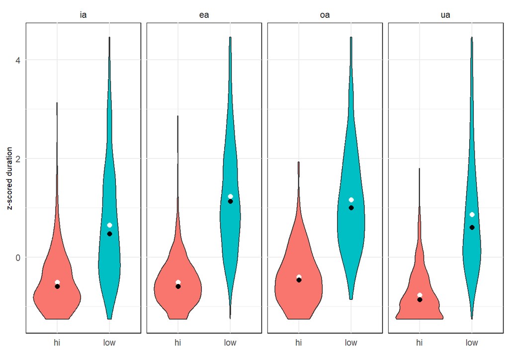

```r
results_extreme_duration <- results_extreme_all %>%
  filter(PC1cat != "mid") %>%
  rename(s_duration = Duration..z.scored)


results_extreme_duration$sequence <- factor(results_extreme_duration$sequence, levels = c("ia", "ea", "oa", "ua"))

duration_plot <- ggplot(results_extreme_duration, aes(x =PC1cat,  y = s_duration, fill = PC1cat)) +
  geom_violin() +  # Change to violin plot
  geom_point(stat = "summary", fun = "mean", color = "white", size = 2) +  # Add points for mean
  stat_summary(fun = "median", geom = "point", color = "black", size = 2) +  # Add points for median
  facet_wrap(~ sequence, nrow = 1) +
  theme_minimal() +
  theme(panel.background = element_rect(fill = "white"), legend.position = "none") +
  labs(y = "z-scored duration", x = "")  +
  theme(axis.title.x = element_text(size = 8), axis.title.y = element_text(size = 8))

duration_plot
```

2. Plot intensity trajectories by uPC1 category

**Click here to view code.**

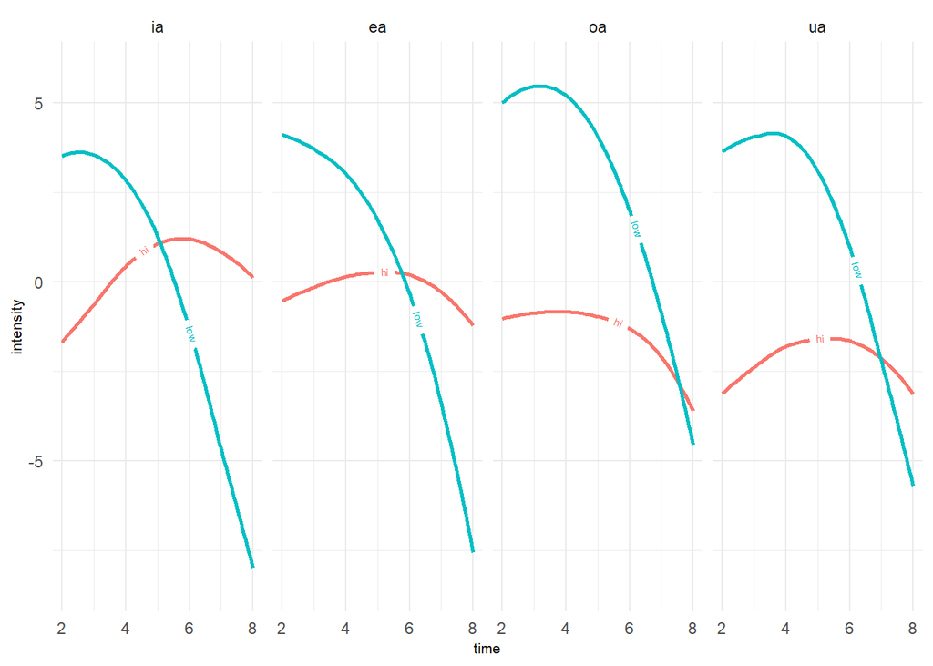

```r
pc_pitch_results_all <-  pc_pitch_results_all %>%
  select(-sequence.x) %>%
  rename(sequence = sequence.y)

 pc_pitch_results_all$sequence <- factor(pc_pitch_results_all$sequence, levels = c("ia", "ea", "oa", "ua"))

 uPCInt <- ggplot(pc_pitch_results_all, aes(x = time, y = intensity, colour = PC1cat, label = PC1cat)) +
  geom_textsmooth(method = "loess", span = 0.5, linewidth = 1,  size = 2) +
  facet_wrap(~ sequence, nrow = 1) +
  theme_minimal() +
  labs(color = "uPC1 Category") +
  theme(legend.position = "none",
        axis.title.x = element_text(size = 8),
        axis.title.y = element_text(size = 8))

uPCInt
```

3. Plot F1 trajectories by uPC1 category

**Click here to view code.**

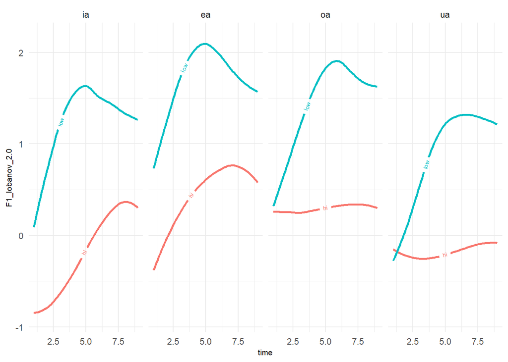

```r
 pc_formants_results_all$sequence <- factor(pc_formants_results_all$sequence, levels = c("ia", "ea", "oa", "ua"))

uPCF1 <- ggplot(pc_formants_results_all, aes(x = time, y = F1_lobanov_2.0, colour = PC1cat, label = PC1cat)) +
  geom_textsmooth(method = "loess", span = 0.5, linewidth = 1, size = 2) +
  facet_wrap(~ sequence, nrow = 1) +
  theme_minimal() +
  labs(color = "uPC1 Category") +
  theme(legend.position = "none",
        axis.title.x = element_text(size = 8),
        axis.title.y = element_text(size = 8))

uPCF1
```

4. Create combined plot

**Click here to view code.**

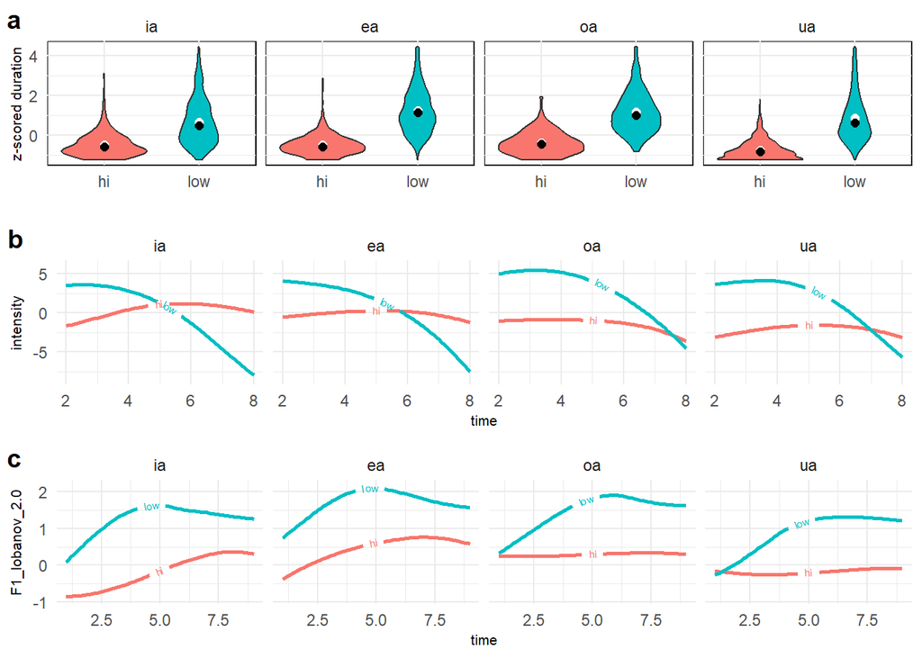

```r
    plots_combined <- cowplot::plot_grid(duration_plot, uPCInt, uPCF1,
                            labels = c("a", "b", "c"), ncol = 1)
    plots_combined
```

5. Save

**Click here to view code.**

```r
ggsave(here( "Figures", "Plots", "uPCA", "uPC1DurationIntF1.png"), plots_combined,  width = 15, height =15 , units = "cm", bg = "white")
```

## 8.5 F2 trajectories: high and low uPC1 tokens /ia/ (Manuscript Figure 4)

This code creates a visualisation of the F2 trajectories of high and low uPC1 tokens of /ia/.

**Click here to view code.**

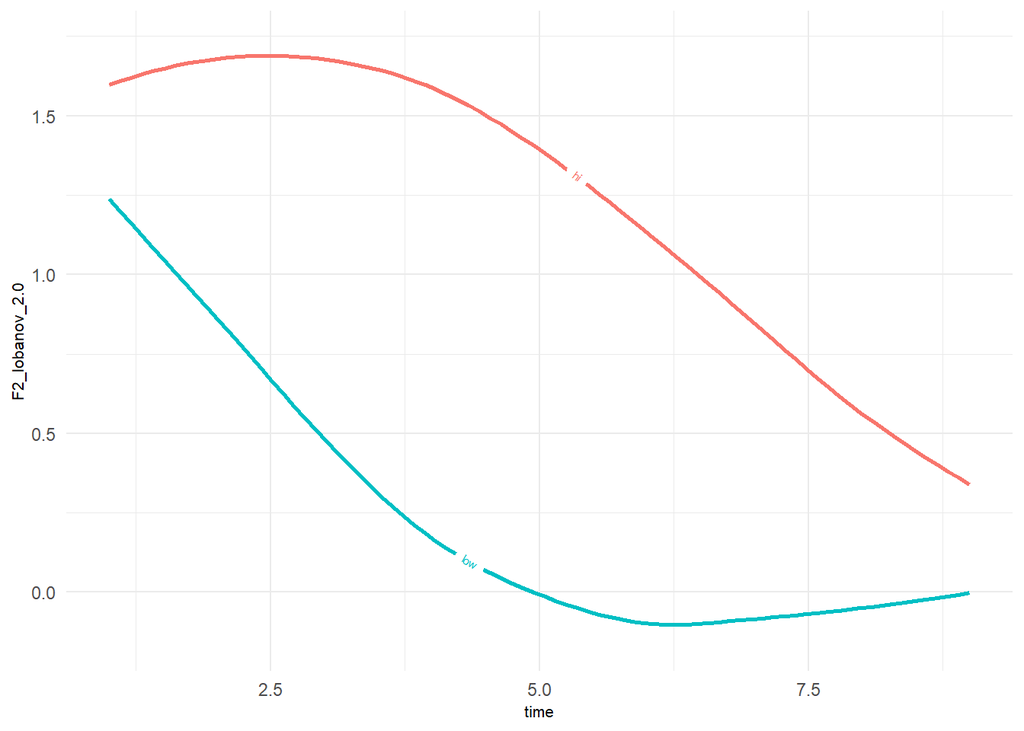

```r
 uPCF2ia <- ggplot(iaresultsformants, aes(x = time, y = F2_lobanov_2.0, colour = PC1cat, label = PC1cat)) +
  geom_textsmooth(method = "loess", span = 0.5, linewidth = 1, size = 2) +
  theme_minimal() +
  theme(legend.position = "none",
        axis.title.x = element_text(size = 8),
        axis.title.y = element_text(size = 8))

uPCF2ia
```

**Click here to view code.**

```r
ggsave(here( "Figures", "Plots", "uPCA", "uPC1F2ia.png"), uPCF2ia,   width=9, height= 7 ,units="cm")
```

## 8.6 Plot of High and low uPC1 formant trajectories with intensity (Manuscript Figure 5)

1. Some initial data prep

**Click here to view code.**

```r
sequences  = pc_formants_results_all
 pitch = pc_pitch_results_all


sequences$participant_gender = as.factor(sequences$participant_gender)
sequences$category = as.factor(sequences$category)
 sequences$sequence = as.factor(sequences$sequence)


sequences$category_gender = interaction(sequences$participant_gender, sequences$category)
```

### 8.6.1 Prepare formant trajectories

1. View the data

**Click here to view code.**

```r
vowels <- sequences


vowels %>%
  head(10) %>%
  kable() %>%
  kable_styling(font_size = 11) %>%
  scroll_box(width = "100%")
```

| X.3 | sequence | MatchId | F1..fPC1 | F1..fPC2 | F1..fPC3 | F2..fPC1 | F2..fPC2 | F2..fPC3 | Pitch..fPC1 | Pitch..fPC2 | Pitch..fPC3 | Intensity..fPC1 | Intensity..fPC2 | Intensity..fPC3 | Duration..z.scored | PC1 | PC2 | PC3 | PC4 | X.2 | X.1 | X | Corpus | Speaker | category | participant_gender | Before.Match | Text | After.Match | … |
| --- | --- | --- | --- | --- | --- | --- | --- | --- | --- | --- | --- | --- | --- | --- | --- | --- | --- | --- | --- | --- | --- | --- | --- | --- | --- | --- | --- | --- | --- | --- |
| 3 | ea | g_10;em_12_707;n_31354-n_31355;p_28;#=ew_69_149873;prefix=00524-;[0]=ew_0_6337 | 1.4364627 | 0.2993751 | 0.0397453 | -0.9850424 | 0.3894143 | -0.0055354 | 31.600232 | 6.860915 | -4.461722 | -0.8902482 | 10.481214 | 4.386573 | 0.3373410 | -1.488767 | 0.1477485 | 1.033077 | -0.2318555 | 68 | 110 | 112 | MAONZE | K001M | PresentElder | M | he | mea | tauhou | … |
| 3 | ea | g_10;em_12_707;n_31354-n_31355;p_28;#=ew_69_149873;prefix=00524-;[0]=ew_0_6337 | 1.4364627 | 0.2993751 | 0.0397453 | -0.9850424 | 0.3894143 | -0.0055354 | 31.600232 | 6.860915 | -4.461722 | -0.8902482 | 10.481214 | 4.386573 | 0.3373410 | -1.488767 | 0.1477485 | 1.033077 | -0.2318555 | 68 | 110 | 112 | MAONZE | K001M | PresentElder | M | he | mea | tauhou | … |
| 3 | ea | g_10;em_12_707;n_31354-n_31355;p_28;#=ew_69_149873;prefix=00524-;[0]=ew_0_6337 | 1.4364627 | 0.2993751 | 0.0397453 | -0.9850424 | 0.3894143 | -0.0055354 | 31.600232 | 6.860915 | -4.461722 | -0.8902482 | 10.481214 | 4.386573 | 0.3373410 | -1.488767 | 0.1477485 | 1.033077 | -0.2318555 | 68 | 110 | 112 | MAONZE | K001M | PresentElder | M | he | mea | tauhou | … |
| 3 | ea | g_10;em_12_707;n_31354-n_31355;p_28;#=ew_69_149873;prefix=00524-;[0]=ew_0_6337 | 1.4364627 | 0.2993751 | 0.0397453 | -0.9850424 | 0.3894143 | -0.0055354 | 31.600232 | 6.860915 | -4.461722 | -0.8902482 | 10.481214 | 4.386573 | 0.3373410 | -1.488767 | 0.1477485 | 1.033077 | -0.2318555 | 68 | 110 | 112 | MAONZE | K001M | PresentElder | M | he | mea | tauhou | … |
| 3 | ea | g_10;em_12_707;n_31354-n_31355;p_28;#=ew_69_149873;prefix=00524-;[0]=ew_0_6337 | 1.4364627 | 0.2993751 | 0.0397453 | -0.9850424 | 0.3894143 | -0.0055354 | 31.600232 | 6.860915 | -4.461722 | -0.8902482 | 10.481214 | 4.386573 | 0.3373410 | -1.488767 | 0.1477485 | 1.033077 | -0.2318555 | 68 | 110 | 112 | MAONZE | K001M | PresentElder | M | he | mea | tauhou | … |
| 3 | ea | g_10;em_12_707;n_31354-n_31355;p_28;#=ew_69_149873;prefix=00524-;[0]=ew_0_6337 | 1.4364627 | 0.2993751 | 0.0397453 | -0.9850424 | 0.3894143 | -0.0055354 | 31.600232 | 6.860915 | -4.461722 | -0.8902482 | 10.481214 | 4.386573 | 0.3373410 | -1.488767 | 0.1477485 | 1.033077 | -0.2318555 | 68 | 110 | 112 | MAONZE | K001M | PresentElder | M | he | mea | tauhou | … |
| 3 | ea | g_10;em_12_707;n_31354-n_31355;p_28;#=ew_69_149873;prefix=00524-;[0]=ew_0_6337 | 1.4364627 | 0.2993751 | 0.0397453 | -0.9850424 | 0.3894143 | -0.0055354 | 31.600232 | 6.860915 | -4.461722 | -0.8902482 | 10.481214 | 4.386573 | 0.3373410 | -1.488767 | 0.1477485 | 1.033077 | -0.2318555 | 68 | 110 | 112 | MAONZE | K001M | PresentElder | M | he | mea | tauhou | … |
| 3 | ea | g_10;em_12_707;n_31354-n_31355;p_28;#=ew_69_149873;prefix=00524-;[0]=ew_0_6337 | 1.4364627 | 0.2993751 | 0.0397453 | -0.9850424 | 0.3894143 | -0.0055354 | 31.600232 | 6.860915 | -4.461722 | -0.8902482 | 10.481214 | 4.386573 | 0.3373410 | -1.488767 | 0.1477485 | 1.033077 | -0.2318555 | 68 | 110 | 112 | MAONZE | K001M | PresentElder | M | he | mea | tauhou | … |
| 3 | ea | g_10;em_12_707;n_31354-n_31355;p_28;#=ew_69_149873;prefix=00524-;[0]=ew_0_6337 | 1.4364627 | 0.2993751 | 0.0397453 | -0.9850424 | 0.3894143 | -0.0055354 | 31.600232 | 6.860915 | -4.461722 | -0.8902482 | 10.481214 | 4.386573 | 0.3373410 | -1.488767 | 0.1477485 | 1.033077 | -0.2318555 | 68 | 110 | 112 | MAONZE | K001M | PresentElder | M | he | mea | tauhou | … |
| 4 | ea | g_10;em_12_710;n_31357-n_31358;p_28;#=ew_69_149890;prefix=00532-;[0]=ew_0_6365 | -0.2938114 | -0.0357030 | -0.3236411 | 0.0990935 | -0.0026037 | 0.3933920 | 9.087662 | -7.878749 | -1.953018 | -5.2253531 | -3.810278 | 2.256708 | -0.3274888 | 1.104122 | 0.2901737 | 0.623884 | 0.0639671 | 70 | 112 | 114 | MAONZE | K001M | PresentElder | M | ngaa | mea | katoa | … |

2. Pivot the data

**Click here to view code.**

```r
vowels <- vowels %>%
  pivot_longer(
    cols = F1_lobanov_2.0:F2_lobanov_2.0, # Select the columns to turn into rows.
    names_to = "Formant", # Name the column to indicate if data is F1 or F2,
    values_to = "Frequency"
  )

vowels %>%
  head(10) %>%
  kable() %>%
  kable_styling(font_size = 11) %>%
  scroll_box(width = "100%")
```

| X.3 | sequence | MatchId | F1..fPC1 | F1..fPC2 | F1..fPC3 | F2..fPC1 | F2..fPC2 | F2..fPC3 | Pitch..fPC1 | Pitch..fPC2 | Pitch..fPC3 | Intensity..fPC1 | Intensity..fPC2 | Intensity..fPC3 | Duration..z.scored | PC1 | PC2 | PC3 | PC4 | X.2 | X.1 | X | Corpus | Speaker | category | participant_gender | Before.Match | Text | After.Match | … |
| --- | --- | --- | --- | --- | --- | --- | --- | --- | --- | --- | --- | --- | --- | --- | --- | --- | --- | --- | --- | --- | --- | --- | --- | --- | --- | --- | --- | --- | --- | --- |
| 3 | ea | g_10;em_12_707;n_31354-n_31355;p_28;#=ew_69_149873;prefix=00524-;[0]=ew_0_6337 | 1.436463 | 0.2993751 | 0.0397453 | -0.9850424 | 0.3894143 | -0.0055354 | 31.60023 | 6.860915 | -4.461722 | -0.8902482 | 10.48121 | 4.386573 | 0.337341 | -1.488767 | 0.1477485 | 1.033077 | -0.2318555 | 68 | 110 | 112 | MAONZE | K001M | PresentElder | M | he | mea | tauhou | … |
| 3 | ea | g_10;em_12_707;n_31354-n_31355;p_28;#=ew_69_149873;prefix=00524-;[0]=ew_0_6337 | 1.436463 | 0.2993751 | 0.0397453 | -0.9850424 | 0.3894143 | -0.0055354 | 31.60023 | 6.860915 | -4.461722 | -0.8902482 | 10.48121 | 4.386573 | 0.337341 | -1.488767 | 0.1477485 | 1.033077 | -0.2318555 | 68 | 110 | 112 | MAONZE | K001M | PresentElder | M | he | mea | tauhou | … |
| 3 | ea | g_10;em_12_707;n_31354-n_31355;p_28;#=ew_69_149873;prefix=00524-;[0]=ew_0_6337 | 1.436463 | 0.2993751 | 0.0397453 | -0.9850424 | 0.3894143 | -0.0055354 | 31.60023 | 6.860915 | -4.461722 | -0.8902482 | 10.48121 | 4.386573 | 0.337341 | -1.488767 | 0.1477485 | 1.033077 | -0.2318555 | 68 | 110 | 112 | MAONZE | K001M | PresentElder | M | he | mea | tauhou | … |
| 3 | ea | g_10;em_12_707;n_31354-n_31355;p_28;#=ew_69_149873;prefix=00524-;[0]=ew_0_6337 | 1.436463 | 0.2993751 | 0.0397453 | -0.9850424 | 0.3894143 | -0.0055354 | 31.60023 | 6.860915 | -4.461722 | -0.8902482 | 10.48121 | 4.386573 | 0.337341 | -1.488767 | 0.1477485 | 1.033077 | -0.2318555 | 68 | 110 | 112 | MAONZE | K001M | PresentElder | M | he | mea | tauhou | … |
| 3 | ea | g_10;em_12_707;n_31354-n_31355;p_28;#=ew_69_149873;prefix=00524-;[0]=ew_0_6337 | 1.436463 | 0.2993751 | 0.0397453 | -0.9850424 | 0.3894143 | -0.0055354 | 31.60023 | 6.860915 | -4.461722 | -0.8902482 | 10.48121 | 4.386573 | 0.337341 | -1.488767 | 0.1477485 | 1.033077 | -0.2318555 | 68 | 110 | 112 | MAONZE | K001M | PresentElder | M | he | mea | tauhou | … |
| 3 | ea | g_10;em_12_707;n_31354-n_31355;p_28;#=ew_69_149873;prefix=00524-;[0]=ew_0_6337 | 1.436463 | 0.2993751 | 0.0397453 | -0.9850424 | 0.3894143 | -0.0055354 | 31.60023 | 6.860915 | -4.461722 | -0.8902482 | 10.48121 | 4.386573 | 0.337341 | -1.488767 | 0.1477485 | 1.033077 | -0.2318555 | 68 | 110 | 112 | MAONZE | K001M | PresentElder | M | he | mea | tauhou | … |
| 3 | ea | g_10;em_12_707;n_31354-n_31355;p_28;#=ew_69_149873;prefix=00524-;[0]=ew_0_6337 | 1.436463 | 0.2993751 | 0.0397453 | -0.9850424 | 0.3894143 | -0.0055354 | 31.60023 | 6.860915 | -4.461722 | -0.8902482 | 10.48121 | 4.386573 | 0.337341 | -1.488767 | 0.1477485 | 1.033077 | -0.2318555 | 68 | 110 | 112 | MAONZE | K001M | PresentElder | M | he | mea | tauhou | … |
| 3 | ea | g_10;em_12_707;n_31354-n_31355;p_28;#=ew_69_149873;prefix=00524-;[0]=ew_0_6337 | 1.436463 | 0.2993751 | 0.0397453 | -0.9850424 | 0.3894143 | -0.0055354 | 31.60023 | 6.860915 | -4.461722 | -0.8902482 | 10.48121 | 4.386573 | 0.337341 | -1.488767 | 0.1477485 | 1.033077 | -0.2318555 | 68 | 110 | 112 | MAONZE | K001M | PresentElder | M | he | mea | tauhou | … |
| 3 | ea | g_10;em_12_707;n_31354-n_31355;p_28;#=ew_69_149873;prefix=00524-;[0]=ew_0_6337 | 1.436463 | 0.2993751 | 0.0397453 | -0.9850424 | 0.3894143 | -0.0055354 | 31.60023 | 6.860915 | -4.461722 | -0.8902482 | 10.48121 | 4.386573 | 0.337341 | -1.488767 | 0.1477485 | 1.033077 | -0.2318555 | 68 | 110 | 112 | MAONZE | K001M | PresentElder | M | he | mea | tauhou | … |
| 3 | ea | g_10;em_12_707;n_31354-n_31355;p_28;#=ew_69_149873;prefix=00524-;[0]=ew_0_6337 | 1.436463 | 0.2993751 | 0.0397453 | -0.9850424 | 0.3894143 | -0.0055354 | 31.60023 | 6.860915 | -4.461722 | -0.8902482 | 10.48121 | 4.386573 | 0.337341 | -1.488767 | 0.1477485 | 1.033077 | -0.2318555 | 68 | 110 | 112 | MAONZE | K001M | PresentElder | M | he | mea | tauhou | … |

3. Nest the data

**Click here to view code.**

```r
vowels$Vowel = vowels$sequence


vowels <- vowels %>%
  group_by(Vowel, Formant, PC1cat) %>%
  nest()
```

4. Fit GAMs to the data

**Click here to view code.**

```r
vowels <- vowels %>%
  mutate(
    model = map(
      data, # We are applying a function to the entries of the `data` column.
      # This is the function we are applying (introduced with a ~)
      ~ bam(
        # Here's our formula.
        Frequency ~ participant_gender +
          s(time, by=participant_gender, k=5),
        data = .x, # Here's our pronoun.
        # Then some arguments to speed up the model fit.
        method = 'fREML',
        discrete = TRUE,
        nthreads = 2
      )
    )
  )
```

5. Get predictions

**Click here to view code.**

```r
to_predict <- list(
  "time" = seq(from=1, to=9, by=1), # All years
  "participant_gender" = c("M", "F")
)

vowels <- vowels %>%
  mutate(
    prediction = map(
      model, # This time we're applying the function to all the models.
      # We again introduce the function with '~', and indicate where the model
      # goes with '.x'.
      ~ get_predictions(model = .x, cond = to_predict, print.summary = FALSE)
    )
  )
```

6. View predictions

**Click here to view code.**

```r
vowels$prediction[[1]] %>%
  head() %>%
  kable() %>%
  kable_styling() %>%
  scroll_box(width = "100%")
```

| participant_gender | time | fit | CI |
| --- | --- | --- | --- |
| M | 1 | 0.7404713 | 0.1037006 |
| F | 1 | 0.7295707 | 0.0940714 |
| M | 2 | 1.2598329 | 0.0689358 |
| F | 2 | 1.2265593 | 0.0627091 |
| M | 3 | 1.7033801 | 0.0748911 |
| F | 3 | 1.6807448 | 0.0681337 |

7. Format predictions

**Click here to view code.**

```r
predictions <- vowels %>%
  select(
    Vowel, Formant, PC1cat, prediction
  ) %>%
  unnest(prediction)

predictions %>%
  head() %>%
  kable() %>%
  kable_styling() %>%
  scroll_box(width = "100%")
```

| Vowel | Formant | PC1cat | participant_gender | time | fit | CI |
| --- | --- | --- | --- | --- | --- | --- |
| ea | F1_lobanov_2.0 | low | M | 1 | 0.7404713 | 0.1037006 |
| ea | F1_lobanov_2.0 | low | F | 1 | 0.7295707 | 0.0940714 |
| ea | F1_lobanov_2.0 | low | M | 2 | 1.2598329 | 0.0689358 |
| ea | F1_lobanov_2.0 | low | F | 2 | 1.2265593 | 0.0627091 |
| ea | F1_lobanov_2.0 | low | M | 3 | 1.7033801 | 0.0748911 |
| ea | F1_lobanov_2.0 | low | F | 3 | 1.6807448 | 0.0681337 |

**Click here to view code.**

```r
predictions <- predictions %>%
  select( # Remove unneeded variables
    -CI
  ) %>%
  pivot_wider( # Pivot
    names_from = Formant,
    values_from = fit
  )

predictions %>%
  head() %>%
  kable() %>%
  kable_styling() %>%
  scroll_box(width = "100%")
```

| Vowel | PC1cat | participant_gender | time | F1_lobanov_2.0 | F2_lobanov_2.0 |
| --- | --- | --- | --- | --- | --- |
| ea | low | M | 1 | 0.7404713 | 0.6698052 |
| ea | low | F | 1 | 0.7295707 | 0.9172131 |
| ea | low | M | 2 | 1.2598329 | 0.5245497 |
| ea | low | F | 2 | 1.2265593 | 0.7956188 |
| ea | low | M | 3 | 1.7033801 | 0.3382139 |
| ea | low | F | 3 | 1.6807448 | 0.5886874 |

8. Get first observations which we will use in the plot

**Click here to view code.**

```r
predictions$Vowelcat = paste(predictions$Vowel,predictions$PC1cat)


first_obs <- predictions %>%
  group_by(Vowelcat, participant_gender) %>%
  slice(which.min(time))

ffirst_obs <- predictions %>% filter(participant_gender == "F") %>%
  group_by(Vowelcat) %>%
  slice(which.min(time))
```

### 8.6.2 Prepare intensity trajectories

1. Some data prep

**Click here to view code.**

```r
pitch$MatchTime = paste(pitch$MatchId, pitch$time)
sequences$MatchTime = paste(sequences$MatchId, sequences$time)

sequenceswithpitch = left_join(sequences, pitch)

sequenceswithpitch$participant_gender = as.factor(sequenceswithpitch$participant_gender)
sequenceswithpitch$category = as.factor(sequenceswithpitch$category)
sequenceswithpitch$sequence = as.factor(sequenceswithpitch$sequence)


sequenceswithpitch$category_gender = interaction(sequenceswithpitch$participant_gender, sequenceswithpitch$category)

vowels <- sequenceswithpitch

vowels %>%
  head(10) %>%
  kable() %>%
  kable_styling(font_size = 11) %>%
  scroll_box(width = "100%")
```

| X.3 | sequence | MatchId | F1..fPC1 | F1..fPC2 | F1..fPC3 | F2..fPC1 | F2..fPC2 | F2..fPC3 | Pitch..fPC1 | Pitch..fPC2 | Pitch..fPC3 | Intensity..fPC1 | Intensity..fPC2 | Intensity..fPC3 | Duration..z.scored | PC1 | PC2 | PC3 | PC4 | X.2 | X.1 | X | Corpus | Speaker | category | participant_gender | Before.Match | Text | After.Match | … |
| --- | --- | --- | --- | --- | --- | --- | --- | --- | --- | --- | --- | --- | --- | --- | --- | --- | --- | --- | --- | --- | --- | --- | --- | --- | --- | --- | --- | --- | --- | --- |
| 3 | ea | g_10;em_12_707;n_31354-n_31355;p_28;#=ew_69_149873;prefix=00524-;[0]=ew_0_6337 | 1.4364627 | 0.2993751 | 0.0397453 | -0.9850424 | 0.3894143 | -0.0055354 | 31.600232 | 6.860915 | -4.461722 | -0.8902482 | 10.481214 | 4.386573 | 0.3373410 | -1.488767 | 0.1477485 | 1.033077 | -0.2318555 | 68 | 110 | 112 | MAONZE | K001M | PresentElder | M | he | mea | tauhou | … |
| 3 | ea | g_10;em_12_707;n_31354-n_31355;p_28;#=ew_69_149873;prefix=00524-;[0]=ew_0_6337 | 1.4364627 | 0.2993751 | 0.0397453 | -0.9850424 | 0.3894143 | -0.0055354 | 31.600232 | 6.860915 | -4.461722 | -0.8902482 | 10.481214 | 4.386573 | 0.3373410 | -1.488767 | 0.1477485 | 1.033077 | -0.2318555 | 68 | 110 | 112 | MAONZE | K001M | PresentElder | M | he | mea | tauhou | … |
| 3 | ea | g_10;em_12_707;n_31354-n_31355;p_28;#=ew_69_149873;prefix=00524-;[0]=ew_0_6337 | 1.4364627 | 0.2993751 | 0.0397453 | -0.9850424 | 0.3894143 | -0.0055354 | 31.600232 | 6.860915 | -4.461722 | -0.8902482 | 10.481214 | 4.386573 | 0.3373410 | -1.488767 | 0.1477485 | 1.033077 | -0.2318555 | 68 | 110 | 112 | MAONZE | K001M | PresentElder | M | he | mea | tauhou | … |
| 3 | ea | g_10;em_12_707;n_31354-n_31355;p_28;#=ew_69_149873;prefix=00524-;[0]=ew_0_6337 | 1.4364627 | 0.2993751 | 0.0397453 | -0.9850424 | 0.3894143 | -0.0055354 | 31.600232 | 6.860915 | -4.461722 | -0.8902482 | 10.481214 | 4.386573 | 0.3373410 | -1.488767 | 0.1477485 | 1.033077 | -0.2318555 | 68 | 110 | 112 | MAONZE | K001M | PresentElder | M | he | mea | tauhou | … |
| 3 | ea | g_10;em_12_707;n_31354-n_31355;p_28;#=ew_69_149873;prefix=00524-;[0]=ew_0_6337 | 1.4364627 | 0.2993751 | 0.0397453 | -0.9850424 | 0.3894143 | -0.0055354 | 31.600232 | 6.860915 | -4.461722 | -0.8902482 | 10.481214 | 4.386573 | 0.3373410 | -1.488767 | 0.1477485 | 1.033077 | -0.2318555 | 68 | 110 | 112 | MAONZE | K001M | PresentElder | M | he | mea | tauhou | … |
| 3 | ea | g_10;em_12_707;n_31354-n_31355;p_28;#=ew_69_149873;prefix=00524-;[0]=ew_0_6337 | 1.4364627 | 0.2993751 | 0.0397453 | -0.9850424 | 0.3894143 | -0.0055354 | 31.600232 | 6.860915 | -4.461722 | -0.8902482 | 10.481214 | 4.386573 | 0.3373410 | -1.488767 | 0.1477485 | 1.033077 | -0.2318555 | 68 | 110 | 112 | MAONZE | K001M | PresentElder | M | he | mea | tauhou | … |
| 3 | ea | g_10;em_12_707;n_31354-n_31355;p_28;#=ew_69_149873;prefix=00524-;[0]=ew_0_6337 | 1.4364627 | 0.2993751 | 0.0397453 | -0.9850424 | 0.3894143 | -0.0055354 | 31.600232 | 6.860915 | -4.461722 | -0.8902482 | 10.481214 | 4.386573 | 0.3373410 | -1.488767 | 0.1477485 | 1.033077 | -0.2318555 | 68 | 110 | 112 | MAONZE | K001M | PresentElder | M | he | mea | tauhou | … |
| 3 | ea | g_10;em_12_707;n_31354-n_31355;p_28;#=ew_69_149873;prefix=00524-;[0]=ew_0_6337 | 1.4364627 | 0.2993751 | 0.0397453 | -0.9850424 | 0.3894143 | -0.0055354 | 31.600232 | 6.860915 | -4.461722 | -0.8902482 | 10.481214 | 4.386573 | 0.3373410 | -1.488767 | 0.1477485 | 1.033077 | -0.2318555 | 68 | 110 | 112 | MAONZE | K001M | PresentElder | M | he | mea | tauhou | … |
| 3 | ea | g_10;em_12_707;n_31354-n_31355;p_28;#=ew_69_149873;prefix=00524-;[0]=ew_0_6337 | 1.4364627 | 0.2993751 | 0.0397453 | -0.9850424 | 0.3894143 | -0.0055354 | 31.600232 | 6.860915 | -4.461722 | -0.8902482 | 10.481214 | 4.386573 | 0.3373410 | -1.488767 | 0.1477485 | 1.033077 | -0.2318555 | 68 | 110 | 112 | MAONZE | K001M | PresentElder | M | he | mea | tauhou | … |
| 4 | ea | g_10;em_12_710;n_31357-n_31358;p_28;#=ew_69_149890;prefix=00532-;[0]=ew_0_6365 | -0.2938114 | -0.0357030 | -0.3236411 | 0.0990935 | -0.0026037 | 0.3933920 | 9.087662 | -7.878749 | -1.953018 | -5.2253531 | -3.810278 | 2.256708 | -0.3274888 | 1.104122 | 0.2901737 | 0.623884 | 0.0639671 | 70 | 112 | 114 | MAONZE | K001M | PresentElder | M | ngaa | mea | katoa | … |

2. Nest data

**Click here to view code.**

```r
vowels$Vowel = vowels$sequence


vowels <- vowels %>%
  group_by(Vowel, PC1cat) %>%
  nest()
```

3. Fit GAMs to the data

**Click here to view code.**

```r
vowels <- vowels %>%
  mutate(
    model = map(
      data, # We are applying a function to the entries of the `data` column.
      # This is the function we are applying (introduced with a ~)
      ~ bam(
        # Here's our formula.
        c_intensity ~ participant_gender +
          s(time, by=participant_gender, k=5),
        data = .x, # Here's our pronoun.
        # Then some arguments to speed up the model fit.
        method = 'fREML',
        discrete = TRUE,
        nthreads = 2
      )
    )
  )
```

4. Get predictions

**Click here to view code.**

```r
to_predict <- list(
  "time" = seq(from=1, to=9, by=1), # All years
  "participant_gender" = c("M", "F")
)
# BTW: Get prediction will just assume the average value for any predictors not
# mentioned (in this case, Speech_rate).

vowels <- vowels %>%
  mutate(
    prediction = map(
      model, # This time we're applying the function to all the models.
      # We again introduce the function with '~', and indicate where the model
      # goes with '.x'.
      ~ get_predictions(model = .x, cond = to_predict, print.summary = FALSE)
    )
  )
```

4. View predictions

**Click here to view code.**

```r
vowels$prediction[[1]] %>%
  head() %>%
  kable() %>%
  kable_styling() %>%
  scroll_box(width = "100%")
```

| participant_gender | time | fit | CI |
| --- | --- | --- | --- |
| M | 1 | 4.511616 | 0.7639374 |
| F | 1 | 3.410783 | 0.6966628 |
| M | 2 | 4.124922 | 0.3373198 |
| F | 2 | 3.234433 | 0.3050947 |
| M | 3 | 3.652382 | 0.2749016 |
| F | 3 | 2.996439 | 0.2501579 |

5. Format predictions

**Click here to view code.**

```r
apredictions <- vowels %>%
  select(
    Vowel, prediction
  ) %>%
  unnest(prediction)

apredictions %>%
  head() %>%
  kable() %>%
  kable_styling() %>%
  scroll_box(width = "100%")
```

| PC1cat | Vowel | participant_gender | time | fit | CI |
| --- | --- | --- | --- | --- | --- |
| low | ea | M | 1 | 4.511616 | 0.7639374 |
| low | ea | F | 1 | 3.410783 | 0.6966628 |
| low | ea | M | 2 | 4.124922 | 0.3373198 |
| low | ea | F | 2 | 3.234433 | 0.3050947 |
| low | ea | M | 3 | 3.652382 | 0.2749016 |
| low | ea | F | 3 | 2.996439 | 0.2501579 |

**Click here to view code.**

```r
apredictions <- apredictions %>%
  select( # Remove unneeded variables
    -CI
  )

apredictions %>%
  head() %>%
  kable() %>%
  kable_styling() %>%
  scroll_box(width = "100%")
```

| PC1cat | Vowel | participant_gender | time | fit |
| --- | --- | --- | --- | --- |
| low | ea | M | 1 | 4.511616 |
| low | ea | F | 1 | 3.410783 |
| low | ea | M | 2 | 4.124922 |
| low | ea | F | 2 | 3.234433 |
| low | ea | M | 3 | 3.652382 |
| low | ea | F | 3 | 2.996439 |

6. Get first predictions for plot

**Click here to view code.**

```r
apredictions$Vowelcat = paste(apredictions$Vowel,apredictions$PC1cat)

predictions$Vowelcat = paste(predictions$Vowel,predictions$PC1cat)

predictions$Intensity = apredictions$fit


ffirst_obs_amp <- apredictions %>% filter(participant_gender == "F") %>%
  group_by(Vowelcat) %>%
  slice(which.min(time))
```

### 8.6.3 Generate monophthong elipses labels + create final plot

1. Read in monophthongs data

**Click here to view code.**

```r
monophthongs = read.csv(here("Data", "monophthongsfinal.csv"))
```

2. Calculate mean for each monophthong

**Click here to view code.**

```r
i_means <- monophthongs %>%
  filter(Target.teAkaSegment == "i") %>%
  mutate(meanF1 = mean(F1_lobanov_2.0)) %>%
  mutate(meanF2 = mean(F2_lobanov_2.0)) %>%
  select(Target.teAkaSegment, meanF1, meanF2) %>%
  unique()

e_means <- monophthongs %>%
  filter(Target.teAkaSegment == "e") %>%
  mutate(meanF1 = mean(F1_lobanov_2.0)) %>%
  mutate(meanF2 = mean(F2_lobanov_2.0)) %>%
  select(Target.teAkaSegment, meanF1, meanF2) %>%
  unique()

a_means <- monophthongs %>%
  filter(Target.teAkaSegment == "a") %>%
  mutate(meanF1 = mean(F1_lobanov_2.0)) %>%
  mutate(meanF2 = mean(F2_lobanov_2.0)) %>%
  select(Target.teAkaSegment, meanF1, meanF2) %>%
  unique()

o_means <- monophthongs %>%
  filter(Target.teAkaSegment == "o") %>%
  mutate(meanF1 = mean(F1_lobanov_2.0)) %>%
  mutate(meanF2 = mean(F2_lobanov_2.0)) %>%
  select(Target.teAkaSegment, meanF1, meanF2) %>%
  unique()


u_means <- monophthongs %>%
  filter(Target.teAkaSegment == "u") %>%
  mutate(meanF1 = mean(F1_lobanov_2.0)) %>%
  mutate(meanF2 = mean(F2_lobanov_2.0)) %>%
  select(Target.teAkaSegment, meanF1, meanF2) %>%
  unique()
```

3. Combine into a data frame

**Click here to view code.**

```r
monophthong_means <- rbind(i_means, e_means, a_means, o_means, u_means) %>%
  rename(F1_lobanov_2.0 = meanF1) %>%
  rename(F2_lobanov_2.0 = meanF2)
```

4. Make combined plot

**Click here to view code.**

```r
femalemono = monophthongs %>% filter(participant_gender == "F")
femaleseq = predictions %>% filter(participant_gender == "F")
fplot <- femalemono %>%
  ggplot(aes(x = F2_lobanov_2.0, y = F1_lobanov_2.0, colour = Target.teAkaSegment)) +
   stat_ellipse(level = 0.67, geom = "polygon", alpha = 0.1, aes(fill = Target.teAkaSegment), show.legend = FALSE) +
  scale_x_reverse() + scale_y_reverse() +
   scale_fill_grey(start = 0.1, end = 0.9) +
    geom_text(data= monophthong_means,
            aes(x = F2_lobanov_2.0, y = F1_lobanov_2.0, label = Target.teAkaSegment),  show.legend = FALSE, size = 2)  +
 geom_path(data = femaleseq, aes(
    x = F2_lobanov_2.0,
    y = F1_lobanov_2.0,
    colour = PC1cat, linewidth = Intensity),
    size = 1, show.legend = TRUE,
    arrow = arrow(length = unit(1, "mm")), size = 1) +
  scale_color_manual(values = c("hi" = "#F8766D", "low" = "#00BFC4")) +
   guides(colour = guide_legend(title = "uPC1 Category"), fill = "none", linewidth = "none")


fplotfinal <- fplot    + theme_classic() + scale_linewidth_continuous(range = c(.001, .85)) +
 facet_wrap(~Vowel, nrow = 2) +
  theme(
    axis.title = element_text(size = 6),
    axis.text = element_text(size = 6),
    legend.position = "bottom",
    legend.title = element_text(size = 6),
    legend.text = element_text(size = 6)
  ) +
   ggtitle("Women")
```

5. Save

**Click here to view code.**

```r
ggsave(here( "Figures", "Plots", "uPCA", "lowhighUPC1TrajectorieswithInt.pdf"),  width= 11, height= 12.5,units="cm")
```

6. Same plot, but using data from men

**Click here to view code.**

```r
malemono = monophthongs %>% filter(participant_gender == "M")
maleseq = predictions %>% filter(participant_gender == "M")

mplot <- malemono %>%
  ggplot(aes(x = F2_lobanov_2.0, y = F1_lobanov_2.0, colour = Target.teAkaSegment)) +
   stat_ellipse(level = 0.67, geom = "polygon", alpha = 0.1, aes(fill = Target.teAkaSegment), show.legend = FALSE) +
  scale_x_reverse() + scale_y_reverse() +
   scale_fill_grey(start = 0.1, end = 0.9) +
    geom_text(data= monophthong_means,
            aes(x = F2_lobanov_2.0, y = F1_lobanov_2.0, label = Target.teAkaSegment),  show.legend = FALSE, size = 2)  +
 geom_path(data = maleseq, aes(
    x = F2_lobanov_2.0,
    y = F1_lobanov_2.0,
    colour = PC1cat, linewidth = Intensity),
    size = 1, show.legend = TRUE,
    arrow = arrow(length = unit(1, "mm")), size = 1) +
  scale_color_manual(values = c("hi" = "#F8766D", "low" = "#00BFC4")) +
   guides(colour = guide_legend(title = "uPC1 Category"), fill = "none", linewidth = "none")


mplotfinal <- mplot    + theme_classic() + scale_linewidth_continuous(range = c(.001, .85)) +
 facet_wrap(~Vowel, nrow = 2) +
  theme(
    axis.title = element_text(size = 6),
    axis.text = element_text(size = 6),
    legend.position = "bottom",
    legend.title = element_text(size = 6),
    legend.text = element_text(size = 6)
  ) +
   ggtitle("Men")
```

**Click here to view code.**

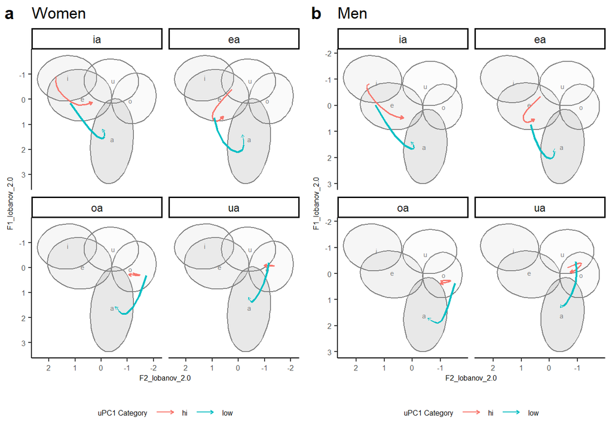

```r
Trajplotcombined <- cowplot::plot_grid(fplotfinal, mplotfinal,
                            labels = c("a", "b"), ncol = 2, align = "c", axis = "l")

Trajplotcombined
```

**Click here to view code.**

```r
ggsave(here( "Figures", "Plots", "uPCA", "lowhighUPC1TrajectorieswithIntCombined.pdf"), Trajplotcombined,  width= 20, height= 12.5,units="cm")
```

# 9 Are the different trajectories for high and low uPC1 tokens a product of different monophthong spaces? (Manuscript footnote 7)

As mentioned in Footnote 7 of the manuscript, it could be possible that speakers with predominantly high uPC1 scores and predominantly low uPC1 scores have different monophthong spaces, and that the different trajectories we see between high and low uPC1 tokens are actually a reflection of these differences. To investigate this, we plot the vowel spaces of men and women who predominantly low uPC1 scores. The following chunks provide the code.

1. Read in data if need be. This section uses results_extreme_all data frame and pc_formants_results_all, defined in Section 8.4

**Click here to view code.**

```r
monophthongs = read.csv(here("Data", "monophthongsfinal.csv"))
```

2. Count number of high and low scoring tokens per speaker

**Click here to view code.**

```r
per_speaker_PC_results_overlall  <- results_extreme_all %>%
  filter(PC1cat != "mid") %>%
  select(MatchId, Speaker, PC1cat, sequence) %>%
  group_by(Speaker,   PC1cat) %>%
  count()
```

3. Essentially pivot the data

**Click here to view code.**

```r
per_speaker_PC_results_counts <- per_speaker_PC_results_overlall %>%
group_by(Speaker, PC1cat) %>%
  summarise(n = sum(n), .groups = "drop") %>%
  pivot_wider(names_from = PC1cat, values_from = n, values_fill = list(n = 0))

colnames(per_speaker_PC_results_counts) <- c("Speaker", "hi_n", "low_n")
```

4. Determine if the have more or high low scoring tokens, or if its a tie

**Click here to view code.**

```r
per_speaker_PC_results_counts <- per_speaker_PC_results_counts %>%
  mutate(predominant_PC1cat = case_when(
    hi_n > low_n ~ "hi",
    hi_n < low_n ~ "low",
    TRUE ~ "tie"
  ))
```

5. Combine with monophthongs, filter out tokens from speakers with tied high and low tokens.

**Click here to view code.**

```r
monophthongs <- left_join(monophthongs, per_speaker_PC_results_counts) %>%
   filter(predominant_PC1cat != "tie")
```

6. Combine with sequences data

**Click here to view code.**

```r
sequences <- left_join(pc_formants_results_all, per_speaker_PC_results_counts, by = "Speaker")
```

7. Do some data prep for the sequences data

**Click here to view code.**

```r
sequences$participant_gender = as.factor(sequences$participant_gender)
sequences$category = as.factor(sequences$category)
sequences$Vowel = as.factor(sequences$Vowel)

sequences$category_gender = interaction(sequences$participant_gender, sequences$category)

sequences <- left_join(sequences, per_speaker_PC_results_counts)
```

This may not be the best way of doing things, but we create separate data frames for the sequences+ monopthongs of high and low scoring speakers, and then plot the sequence trajectories using GAMs.

**Click here to view code.**

```r
high_scoring_sequences <- sequences %>%
  filter(predominant_PC1cat == "hi")

low_scoring_sequences <- sequences %>%
  filter(predominant_PC1cat == "low")



high_scoring_mono <- monophthongs %>%
    filter(predominant_PC1cat == "hi")

low_scoring_mono <-  monophthongs %>%
  filter(predominant_PC1cat == "low")
```

## 9.1 High scoring speakers only, men and women

1. View data for high scoring seqs

**Click here to view code.**

```r
vowels <- high_scoring_sequences


vowels %>%
  head(10) %>%
  kable() %>%
  kable_styling(font_size = 11) %>%
  scroll_box(width = "100%")
```

| X.3 | sequence | MatchId | F1..fPC1 | F1..fPC2 | F1..fPC3 | F2..fPC1 | F2..fPC2 | F2..fPC3 | Pitch..fPC1 | Pitch..fPC2 | Pitch..fPC3 | Intensity..fPC1 | Intensity..fPC2 | Intensity..fPC3 | Duration..z.scored | PC1 | PC2 | PC3 | PC4 | X.2 | X.1 | X | Corpus | Speaker | category | participant_gender | Before.Match | Text | After.Match | … |
| --- | --- | --- | --- | --- | --- | --- | --- | --- | --- | --- | --- | --- | --- | --- | --- | --- | --- | --- | --- | --- | --- | --- | --- | --- | --- | --- | --- | --- | --- | --- |
| 3 | ea | g_10;em_12_707;n_31354-n_31355;p_28;#=ew_69_149873;prefix=00524-;[0]=ew_0_6337 | 1.4364627 | 0.2993751 | 0.0397453 | -0.9850424 | 0.3894143 | -0.0055354 | 31.600232 | 6.860915 | -4.461722 | -0.8902482 | 10.481214 | 4.386573 | 0.3373410 | -1.488767 | 0.1477485 | 1.033077 | -0.2318555 | 68 | 110 | 112 | MAONZE | K001M | PresentElder | M | he | mea | tauhou | … |
| 3 | ea | g_10;em_12_707;n_31354-n_31355;p_28;#=ew_69_149873;prefix=00524-;[0]=ew_0_6337 | 1.4364627 | 0.2993751 | 0.0397453 | -0.9850424 | 0.3894143 | -0.0055354 | 31.600232 | 6.860915 | -4.461722 | -0.8902482 | 10.481214 | 4.386573 | 0.3373410 | -1.488767 | 0.1477485 | 1.033077 | -0.2318555 | 68 | 110 | 112 | MAONZE | K001M | PresentElder | M | he | mea | tauhou | … |
| 3 | ea | g_10;em_12_707;n_31354-n_31355;p_28;#=ew_69_149873;prefix=00524-;[0]=ew_0_6337 | 1.4364627 | 0.2993751 | 0.0397453 | -0.9850424 | 0.3894143 | -0.0055354 | 31.600232 | 6.860915 | -4.461722 | -0.8902482 | 10.481214 | 4.386573 | 0.3373410 | -1.488767 | 0.1477485 | 1.033077 | -0.2318555 | 68 | 110 | 112 | MAONZE | K001M | PresentElder | M | he | mea | tauhou | … |
| 3 | ea | g_10;em_12_707;n_31354-n_31355;p_28;#=ew_69_149873;prefix=00524-;[0]=ew_0_6337 | 1.4364627 | 0.2993751 | 0.0397453 | -0.9850424 | 0.3894143 | -0.0055354 | 31.600232 | 6.860915 | -4.461722 | -0.8902482 | 10.481214 | 4.386573 | 0.3373410 | -1.488767 | 0.1477485 | 1.033077 | -0.2318555 | 68 | 110 | 112 | MAONZE | K001M | PresentElder | M | he | mea | tauhou | … |
| 3 | ea | g_10;em_12_707;n_31354-n_31355;p_28;#=ew_69_149873;prefix=00524-;[0]=ew_0_6337 | 1.4364627 | 0.2993751 | 0.0397453 | -0.9850424 | 0.3894143 | -0.0055354 | 31.600232 | 6.860915 | -4.461722 | -0.8902482 | 10.481214 | 4.386573 | 0.3373410 | -1.488767 | 0.1477485 | 1.033077 | -0.2318555 | 68 | 110 | 112 | MAONZE | K001M | PresentElder | M | he | mea | tauhou | … |
| 3 | ea | g_10;em_12_707;n_31354-n_31355;p_28;#=ew_69_149873;prefix=00524-;[0]=ew_0_6337 | 1.4364627 | 0.2993751 | 0.0397453 | -0.9850424 | 0.3894143 | -0.0055354 | 31.600232 | 6.860915 | -4.461722 | -0.8902482 | 10.481214 | 4.386573 | 0.3373410 | -1.488767 | 0.1477485 | 1.033077 | -0.2318555 | 68 | 110 | 112 | MAONZE | K001M | PresentElder | M | he | mea | tauhou | … |
| 3 | ea | g_10;em_12_707;n_31354-n_31355;p_28;#=ew_69_149873;prefix=00524-;[0]=ew_0_6337 | 1.4364627 | 0.2993751 | 0.0397453 | -0.9850424 | 0.3894143 | -0.0055354 | 31.600232 | 6.860915 | -4.461722 | -0.8902482 | 10.481214 | 4.386573 | 0.3373410 | -1.488767 | 0.1477485 | 1.033077 | -0.2318555 | 68 | 110 | 112 | MAONZE | K001M | PresentElder | M | he | mea | tauhou | … |
| 3 | ea | g_10;em_12_707;n_31354-n_31355;p_28;#=ew_69_149873;prefix=00524-;[0]=ew_0_6337 | 1.4364627 | 0.2993751 | 0.0397453 | -0.9850424 | 0.3894143 | -0.0055354 | 31.600232 | 6.860915 | -4.461722 | -0.8902482 | 10.481214 | 4.386573 | 0.3373410 | -1.488767 | 0.1477485 | 1.033077 | -0.2318555 | 68 | 110 | 112 | MAONZE | K001M | PresentElder | M | he | mea | tauhou | … |
| 3 | ea | g_10;em_12_707;n_31354-n_31355;p_28;#=ew_69_149873;prefix=00524-;[0]=ew_0_6337 | 1.4364627 | 0.2993751 | 0.0397453 | -0.9850424 | 0.3894143 | -0.0055354 | 31.600232 | 6.860915 | -4.461722 | -0.8902482 | 10.481214 | 4.386573 | 0.3373410 | -1.488767 | 0.1477485 | 1.033077 | -0.2318555 | 68 | 110 | 112 | MAONZE | K001M | PresentElder | M | he | mea | tauhou | … |
| 4 | ea | g_10;em_12_710;n_31357-n_31358;p_28;#=ew_69_149890;prefix=00532-;[0]=ew_0_6365 | -0.2938114 | -0.0357030 | -0.3236411 | 0.0990935 | -0.0026037 | 0.3933920 | 9.087662 | -7.878749 | -1.953018 | -5.2253531 | -3.810278 | 2.256708 | -0.3274888 | 1.104122 | 0.2901737 | 0.623884 | 0.0639671 | 70 | 112 | 114 | MAONZE | K001M | PresentElder | M | ngaa | mea | katoa | … |

3. Pivot data

**Click here to view code.**

```r
vowels <- vowels %>%
  pivot_longer(
    cols = F1_lobanov_2.0:F2_lobanov_2.0, # Select the columns to turn into rows.
    names_to = "Formant", # Name the column to indicate if data is F1 or F2,
    values_to = "Frequency"
  )
```

4. Nest data

**Click here to view code.**

```r
vowels <- vowels %>%
  group_by(Vowel, Formant, PC1cat) %>%
  nest()
```

4. Fit GAMs to the data

**Click here to view code.**

```r
vowels <- vowels %>%
  mutate(
    model = map(
      data, # We are applying a function to the entries of the `data` column.
      # This is the function we are applying (introduced with a ~)
      ~ bam(
        # Here's our formula.
        Frequency ~ participant_gender +
          s(time, by=participant_gender, k=5),
        data = .x, # Here's our pronoun.
        # Then some arguments to speed up the model fit.
        method = 'fREML',
        discrete = TRUE,
        nthreads = 2
      )
    )
  )
```

5. Get predictions

**Click here to view code.**

```r
 to_predict <- list(
  "time" = seq(from=1, to=9, by=1), # All years
  "participant_gender" = c("M", "F")
)
# BTW: Get prediction will just assume the average value for any predictors not
# mentioned (in this case, Speech_rate).

vowels <- vowels %>%
  mutate(
    prediction = map(
      model, # This time we're applying the function to all the models.
      # We again introduce the function with '~', and indicate where the model
      # goes with '.x'.
      ~ get_predictions(model = .x, cond = to_predict, print.summary = FALSE)
    )
  )
```

6. View predictions

**Click here to view code.**

```r
vowels$prediction[[1]] %>%
  head() %>%
  kable() %>%
  kable_styling() %>%
  scroll_box(width = "100%")
```

| participant_gender | time | fit | CI |
| --- | --- | --- | --- |
| M | 1 | 0.5800590 | 0.1526756 |
| F | 1 | 0.7463039 | 0.1813609 |
| M | 2 | 1.0391641 | 0.0987235 |
| F | 2 | 1.1826107 | 0.1203777 |
| M | 3 | 1.4379810 | 0.1051796 |
| F | 3 | 1.6225532 | 0.1297158 |

7. Formant predictions

**Click here to view code.**

```r
predictions <- vowels %>%
  select(
    Vowel, Formant, PC1cat, prediction
  ) %>%
  unnest(prediction)

predictions %>%
  head() %>%
  kable() %>%
  kable_styling() %>%
  scroll_box(width = "100%")
```

| Vowel | Formant | PC1cat | participant_gender | time | fit | CI |
| --- | --- | --- | --- | --- | --- | --- |
| ea | F1_lobanov_2.0 | low | M | 1 | 0.5800590 | 0.1526756 |
| ea | F1_lobanov_2.0 | low | F | 1 | 0.7463039 | 0.1813609 |
| ea | F1_lobanov_2.0 | low | M | 2 | 1.0391641 | 0.0987235 |
| ea | F1_lobanov_2.0 | low | F | 2 | 1.1826107 | 0.1203777 |
| ea | F1_lobanov_2.0 | low | M | 3 | 1.4379810 | 0.1051796 |
| ea | F1_lobanov_2.0 | low | F | 3 | 1.6225532 | 0.1297158 |

**Click here to view code.**

```r
predictions <- predictions %>%
  select( # Remove unneeded variables
    -CI
  ) %>%
  pivot_wider( # Pivot
    names_from = Formant,
    values_from = fit
  )

predictions %>%
  head() %>%
  kable() %>%
  kable_styling() %>%
  scroll_box(width = "100%")
```

| Vowel | PC1cat | participant_gender | time | F1_lobanov_2.0 | F2_lobanov_2.0 |
| --- | --- | --- | --- | --- | --- |
| ea | low | M | 1 | 0.5800590 | 0.7383871 |
| ea | low | F | 1 | 0.7463039 | 1.1363690 |
| ea | low | M | 2 | 1.0391641 | 0.6737784 |
| ea | low | F | 2 | 1.1826107 | 1.1063994 |
| ea | low | M | 3 | 1.4379810 | 0.5386139 |
| ea | low | F | 3 | 1.6225532 | 0.9631273 |

8. More predictions formatting

**Click here to view code.**

```r
predictions$Vowelcat = paste(predictions$Vowel,predictions$PC1cat)


first_obs <- predictions %>%
  group_by(Vowelcat, participant_gender) %>%
  slice(which.min(time))
```

9. Calculate means to label monophthong ellipses

**Click here to view code.**

```r
i_means <- monophthongs %>%
  filter(Target.teAkaSegment == "i") %>%
  mutate(meanF1 = mean(F1_lobanov_2.0)) %>%
  mutate(meanF2 = mean(F2_lobanov_2.0)) %>%
  select(Target.teAkaSegment, meanF1, meanF2) %>%
  unique()

e_means <- monophthongs %>%
  filter(Target.teAkaSegment == "e") %>%
  mutate(meanF1 = mean(F1_lobanov_2.0)) %>%
  mutate(meanF2 = mean(F2_lobanov_2.0)) %>%
  select(Target.teAkaSegment, meanF1, meanF2) %>%
  unique()

a_means <- monophthongs %>%
  filter(Target.teAkaSegment == "a") %>%
  mutate(meanF1 = mean(F1_lobanov_2.0)) %>%
  mutate(meanF2 = mean(F2_lobanov_2.0)) %>%
  select(Target.teAkaSegment, meanF1, meanF2) %>%
  unique()

o_means <- monophthongs %>%
  filter(Target.teAkaSegment == "o") %>%
  mutate(meanF1 = mean(F1_lobanov_2.0)) %>%
  mutate(meanF2 = mean(F2_lobanov_2.0)) %>%
  select(Target.teAkaSegment, meanF1, meanF2) %>%
  unique()


u_means <- monophthongs %>%
  filter(Target.teAkaSegment == "u") %>%
  mutate(meanF1 = mean(F1_lobanov_2.0)) %>%
  mutate(meanF2 = mean(F2_lobanov_2.0)) %>%
  select(Target.teAkaSegment, meanF1, meanF2) %>%
  unique()

monophthong_means <- rbind(i_means, e_means, a_means, o_means, u_means) %>%
  rename(F1_lobanov_2.0 = meanF1) %>%
  rename(F2_lobanov_2.0 = meanF2)
```

9. Plot women

**Click here to view code.**

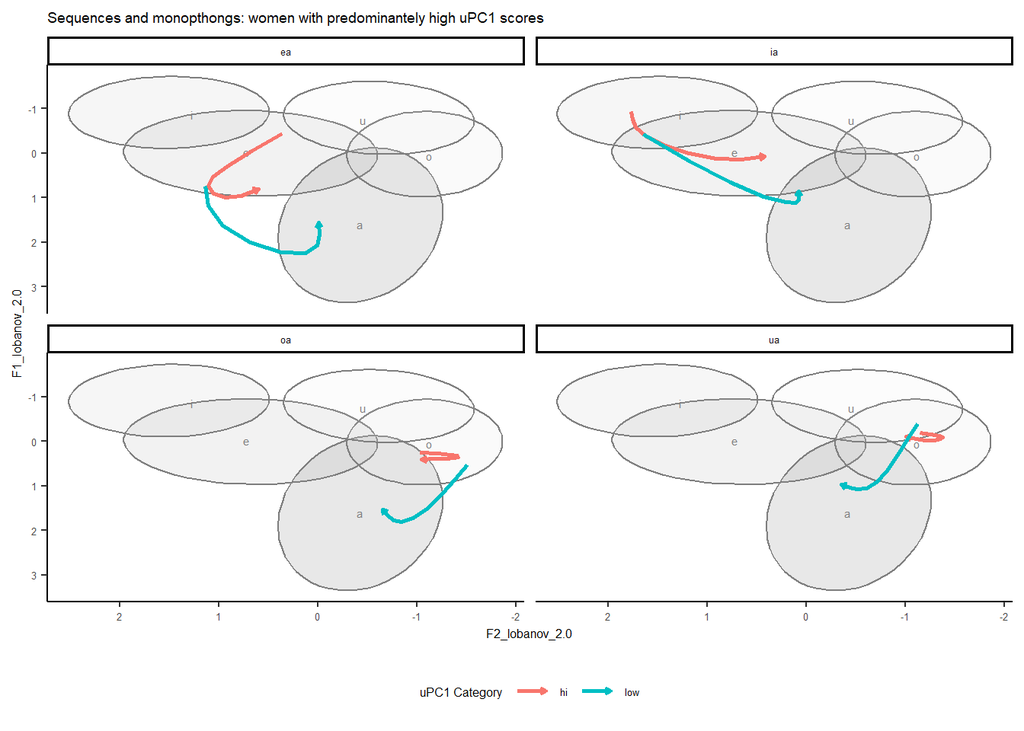

```r
femalemono = high_scoring_mono %>% filter(participant_gender == "F")
femaleseq = predictions %>% filter(participant_gender == "F")

fplot <- femalemono %>%
  ggplot(aes(x = F2_lobanov_2.0, y = F1_lobanov_2.0, colour = Target.teAkaSegment)) +
   stat_ellipse(level = 0.67, geom = "polygon", alpha = 0.1, aes(fill = Target.teAkaSegment), show.legend = FALSE) +
  scale_x_reverse() + scale_y_reverse() +
   scale_fill_grey(start = 0.1, end = 0.9) +
    geom_text(data= monophthong_means,
            aes(x = F2_lobanov_2.0, y = F1_lobanov_2.0, label = Target.teAkaSegment),  show.legend = FALSE, size = 2)  +
 geom_path(data = femaleseq, aes(
    x = F2_lobanov_2.0,
    y = F1_lobanov_2.0,
    colour = PC1cat),
    size = 1, show.legend = TRUE,
    arrow = arrow(length = unit(1, "mm")), size = 1) +
  scale_color_manual(values = c("hi" = "#F8766D", "low" = "#00BFC4")) +
   guides(colour = guide_legend(title = "uPC1 Category"), fill = "none", linewidth = "none")


fplot    + theme_classic() +
 facet_wrap(~Vowel, nrow = 2) +
  labs(title = "Sequences and monopthongs: women with predominantely high uPC1 scores") +
  theme(
    text = element_text(size = 6),
    legend.position = "bottom"
  )
```

10. Plot men

**Click here to view code.**

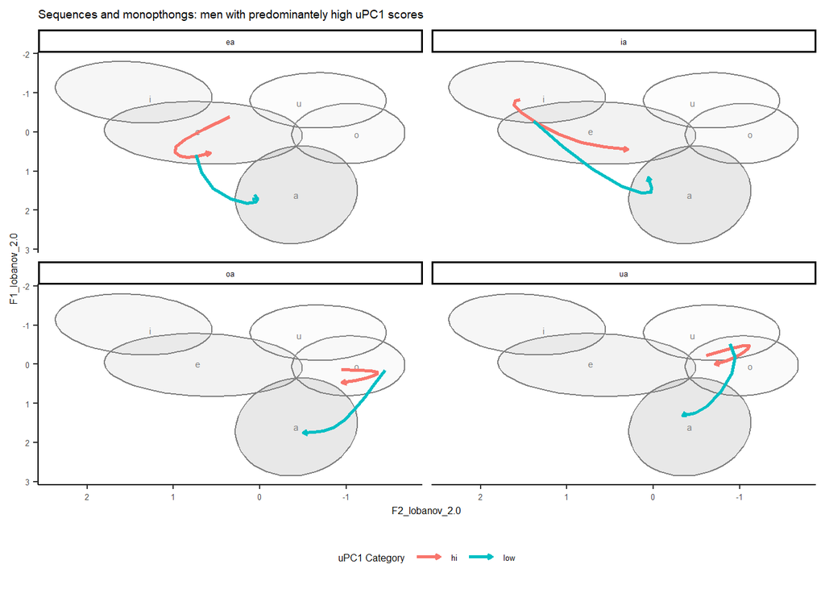

```r
malemono = high_scoring_mono %>% filter(participant_gender == "M")
maleseq = predictions %>% filter(participant_gender == "M")

mplot <- malemono %>%
  ggplot(aes(x = F2_lobanov_2.0, y = F1_lobanov_2.0, colour = Target.teAkaSegment)) +
   stat_ellipse(level = 0.67, geom = "polygon", alpha = 0.1, aes(fill = Target.teAkaSegment), show.legend = FALSE) +
  scale_x_reverse() + scale_y_reverse() +
   scale_fill_grey(start = 0.1, end = 0.9) +
    geom_text(data= monophthong_means,
            aes(x = F2_lobanov_2.0, y = F1_lobanov_2.0, label = Target.teAkaSegment),  show.legend = FALSE, size = 2)  +
 geom_path(data = maleseq, aes(
    x = F2_lobanov_2.0,
    y = F1_lobanov_2.0,
    colour = PC1cat),
    size = 1, show.legend = TRUE,
    arrow = arrow(length = unit(1, "mm")), size = 1) +
  scale_color_manual(values = c("hi" = "#F8766D", "low" = "#00BFC4")) +
   guides(colour = guide_legend(title = "uPC1 Category"), fill = "none", linewidth = "none")


mplot    + theme_classic()+
 facet_wrap(~Vowel, nrow = 2) +
  labs(title = "Sequences and monopthongs: men with predominantely high uPC1 scores") +
  theme(
    text = element_text(size = 6),
    legend.position = "bottom"
  )
```

## 9.2 Low scoring speakers only, men and women

1. View data for low scoring seqs

**Click here to view code.**

```r
vowels <- low_scoring_sequences


vowels %>%
  head(10) %>%
  kable() %>%
  kable_styling(font_size = 11) %>%
  scroll_box(width = "100%")
```

| X.3 | sequence | MatchId | F1..fPC1 | F1..fPC2 | F1..fPC3 | F2..fPC1 | F2..fPC2 | F2..fPC3 | Pitch..fPC1 | Pitch..fPC2 | Pitch..fPC3 | Intensity..fPC1 | Intensity..fPC2 | Intensity..fPC3 | Duration..z.scored | PC1 | PC2 | PC3 | PC4 | X.2 | X.1 | X | Corpus | Speaker | category | participant_gender | Before.Match | Text | After.Match | … |
| --- | --- | --- | --- | --- | --- | --- | --- | --- | --- | --- | --- | --- | --- | --- | --- | --- | --- | --- | --- | --- | --- | --- | --- | --- | --- | --- | --- | --- | --- | --- |
| 15 | ea | g_1007;em_12_95259;n_108219-n_108220;p_284;#=ew_69_210492;prefix=58163-;[0]=ew_0_623659 | 1.8414877 | 0.186432 | -0.2839358 | -0.6724291 | 0.5781306 | -0.4208177 | -12.120353 | -4.034826 | 0.8405222 | 9.772280 | 0.587162 | -0.2066952 | 0.0714091 | -1.031297 | -0.8540191 | -0.0800264 | 0.1915901 | 8215 | 13981 | 14191 | MAONZE | MU01M | Historical | M | e | mea | ko | … |
| 15 | ea | g_1007;em_12_95259;n_108219-n_108220;p_284;#=ew_69_210492;prefix=58163-;[0]=ew_0_623659 | 1.8414877 | 0.186432 | -0.2839358 | -0.6724291 | 0.5781306 | -0.4208177 | -12.120353 | -4.034826 | 0.8405222 | 9.772280 | 0.587162 | -0.2066952 | 0.0714091 | -1.031297 | -0.8540191 | -0.0800264 | 0.1915901 | 8215 | 13981 | 14191 | MAONZE | MU01M | Historical | M | e | mea | ko | … |
| 15 | ea | g_1007;em_12_95259;n_108219-n_108220;p_284;#=ew_69_210492;prefix=58163-;[0]=ew_0_623659 | 1.8414877 | 0.186432 | -0.2839358 | -0.6724291 | 0.5781306 | -0.4208177 | -12.120353 | -4.034826 | 0.8405222 | 9.772280 | 0.587162 | -0.2066952 | 0.0714091 | -1.031297 | -0.8540191 | -0.0800264 | 0.1915901 | 8215 | 13981 | 14191 | MAONZE | MU01M | Historical | M | e | mea | ko | … |
| 15 | ea | g_1007;em_12_95259;n_108219-n_108220;p_284;#=ew_69_210492;prefix=58163-;[0]=ew_0_623659 | 1.8414877 | 0.186432 | -0.2839358 | -0.6724291 | 0.5781306 | -0.4208177 | -12.120353 | -4.034826 | 0.8405222 | 9.772280 | 0.587162 | -0.2066952 | 0.0714091 | -1.031297 | -0.8540191 | -0.0800264 | 0.1915901 | 8215 | 13981 | 14191 | MAONZE | MU01M | Historical | M | e | mea | ko | … |
| 15 | ea | g_1007;em_12_95259;n_108219-n_108220;p_284;#=ew_69_210492;prefix=58163-;[0]=ew_0_623659 | 1.8414877 | 0.186432 | -0.2839358 | -0.6724291 | 0.5781306 | -0.4208177 | -12.120353 | -4.034826 | 0.8405222 | 9.772280 | 0.587162 | -0.2066952 | 0.0714091 | -1.031297 | -0.8540191 | -0.0800264 | 0.1915901 | 8215 | 13981 | 14191 | MAONZE | MU01M | Historical | M | e | mea | ko | … |
| 15 | ea | g_1007;em_12_95259;n_108219-n_108220;p_284;#=ew_69_210492;prefix=58163-;[0]=ew_0_623659 | 1.8414877 | 0.186432 | -0.2839358 | -0.6724291 | 0.5781306 | -0.4208177 | -12.120353 | -4.034826 | 0.8405222 | 9.772280 | 0.587162 | -0.2066952 | 0.0714091 | -1.031297 | -0.8540191 | -0.0800264 | 0.1915901 | 8215 | 13981 | 14191 | MAONZE | MU01M | Historical | M | e | mea | ko | … |
| 15 | ea | g_1007;em_12_95259;n_108219-n_108220;p_284;#=ew_69_210492;prefix=58163-;[0]=ew_0_623659 | 1.8414877 | 0.186432 | -0.2839358 | -0.6724291 | 0.5781306 | -0.4208177 | -12.120353 | -4.034826 | 0.8405222 | 9.772280 | 0.587162 | -0.2066952 | 0.0714091 | -1.031297 | -0.8540191 | -0.0800264 | 0.1915901 | 8215 | 13981 | 14191 | MAONZE | MU01M | Historical | M | e | mea | ko | … |
| 15 | ea | g_1007;em_12_95259;n_108219-n_108220;p_284;#=ew_69_210492;prefix=58163-;[0]=ew_0_623659 | 1.8414877 | 0.186432 | -0.2839358 | -0.6724291 | 0.5781306 | -0.4208177 | -12.120353 | -4.034826 | 0.8405222 | 9.772280 | 0.587162 | -0.2066952 | 0.0714091 | -1.031297 | -0.8540191 | -0.0800264 | 0.1915901 | 8215 | 13981 | 14191 | MAONZE | MU01M | Historical | M | e | mea | ko | … |
| 15 | ea | g_1007;em_12_95259;n_108219-n_108220;p_284;#=ew_69_210492;prefix=58163-;[0]=ew_0_623659 | 1.8414877 | 0.186432 | -0.2839358 | -0.6724291 | 0.5781306 | -0.4208177 | -12.120353 | -4.034826 | 0.8405222 | 9.772280 | 0.587162 | -0.2066952 | 0.0714091 | -1.031297 | -0.8540191 | -0.0800264 | 0.1915901 | 8215 | 13981 | 14191 | MAONZE | MU01M | Historical | M | e | mea | ko | … |
| 197 | ea | g_1051;em_12_97738;n_109566-n_109567;p_203;#=ew_69_241754;prefix=87824-;[0]=ew_0_649005 | -0.9214995 | 1.478383 | 0.0683188 | -2.0008984 | -0.3725911 | -0.7364066 | -5.064278 | -5.130406 | 5.8262860 | 7.863936 | 3.506005 | -0.0794503 | 1.0021708 | -1.281185 | -0.8619286 | -0.3166463 | -0.0986521 | 12711 | 21281 | 21623 | MAONZE | WU02M | Historical | F | ko | Aotea . | Kurahaupo: - | … |

3. Pivot data

**Click here to view code.**

```r
vowels <- vowels %>%
  pivot_longer(
    cols = F1_lobanov_2.0:F2_lobanov_2.0, # Select the columns to turn into rows.
    names_to = "Formant", # Name the column to indicate if data is F1 or F2,
    values_to = "Frequency"
  )
```

4. Nest data

**Click here to view code.**

```r
vowels <- vowels %>%
  group_by(Vowel, Formant, PC1cat) %>%
  nest()
```

4. Fit GAMs to the data

**Click here to view code.**

```r
vowels <- vowels %>%
  mutate(
    model = map(
      data, # We are applying a function to the entries of the `data` column.
      # This is the function we are applying (introduced with a ~)
      ~ bam(
        # Here's our formula.
        Frequency ~ participant_gender +
          s(time, by=participant_gender, k=5),
        data = .x, # Here's our pronoun.
        # Then some arguments to speed up the model fit.
        method = 'fREML',
        discrete = TRUE,
        nthreads = 2
      )
    )
  )
```

5. Get predictions

**Click here to view code.**

```r
 to_predict <- list(
  "time" = seq(from=1, to=9, by=1), # All years
  "participant_gender" = c("M", "F")
)
# BTW: Get prediction will just assume the average value for any predictors not
# mentioned (in this case, Speech_rate).

vowels <- vowels %>%
  mutate(
    prediction = map(
      model, # This time we're applying the function to all the models.
      # We again introduce the function with '~', and indicate where the model
      # goes with '.x'.
      ~ get_predictions(model = .x, cond = to_predict, print.summary = FALSE)
    )
  )
```

6. View predictions

**Click here to view code.**

```r
vowels$prediction[[1]] %>%
  head() %>%
  kable() %>%
  kable_styling() %>%
  scroll_box(width = "100%")
```

| participant_gender | time | fit | CI |
| --- | --- | --- | --- |
| M | 1 | 0.8508458 | 0.1339840 |
| F | 1 | 0.7254217 | 0.1083475 |
| M | 2 | 1.4081336 | 0.0899359 |
| F | 2 | 1.2417965 | 0.0719859 |
| M | 3 | 1.8738094 | 0.0978850 |
| F | 3 | 1.6981314 | 0.0780793 |

7. Format predictions

**Click here to view code.**

```r
predictions <- vowels %>%
  select(
    Vowel, Formant, PC1cat, prediction
  ) %>%
  unnest(prediction)

predictions %>%
  head() %>%
  kable() %>%
  kable_styling() %>%
  scroll_box(width = "100%")
```

| Vowel | Formant | PC1cat | participant_gender | time | fit | CI |
| --- | --- | --- | --- | --- | --- | --- |
| ea | F1_lobanov_2.0 | low | M | 1 | 0.8508458 | 0.1339840 |
| ea | F1_lobanov_2.0 | low | F | 1 | 0.7254217 | 0.1083475 |
| ea | F1_lobanov_2.0 | low | M | 2 | 1.4081336 | 0.0899359 |
| ea | F1_lobanov_2.0 | low | F | 2 | 1.2417965 | 0.0719859 |
| ea | F1_lobanov_2.0 | low | M | 3 | 1.8738094 | 0.0978850 |
| ea | F1_lobanov_2.0 | low | F | 3 | 1.6981314 | 0.0780793 |

**Click here to view code.**

```r
predictions <- predictions %>%
  select( # Remove unneeded variables
    -CI
  ) %>%
  pivot_wider( # Pivot
    names_from = Formant,
    values_from = fit
  )

predictions %>%
  head() %>%
  kable() %>%
  kable_styling() %>%
  scroll_box(width = "100%")
```

| Vowel | PC1cat | participant_gender | time | F1_lobanov_2.0 | F2_lobanov_2.0 |
| --- | --- | --- | --- | --- | --- |
| ea | low | M | 1 | 0.8508458 | 0.6296614 |
| ea | low | F | 1 | 0.7254217 | 0.8633470 |
| ea | low | M | 2 | 1.4081336 | 0.4215653 |
| ea | low | F | 2 | 1.2417965 | 0.7065416 |
| ea | low | M | 3 | 1.8738094 | 0.2011722 |
| ea | low | F | 3 | 1.6981314 | 0.4800903 |

8. More predictions formatting

**Click here to view code.**

```r
predictions$Vowelcat = paste(predictions$Vowel,predictions$PC1cat)


first_obs <- predictions %>%
  group_by(Vowelcat, participant_gender) %>%
  slice(which.min(time))
```

9. Plot women

**Click here to view code.**

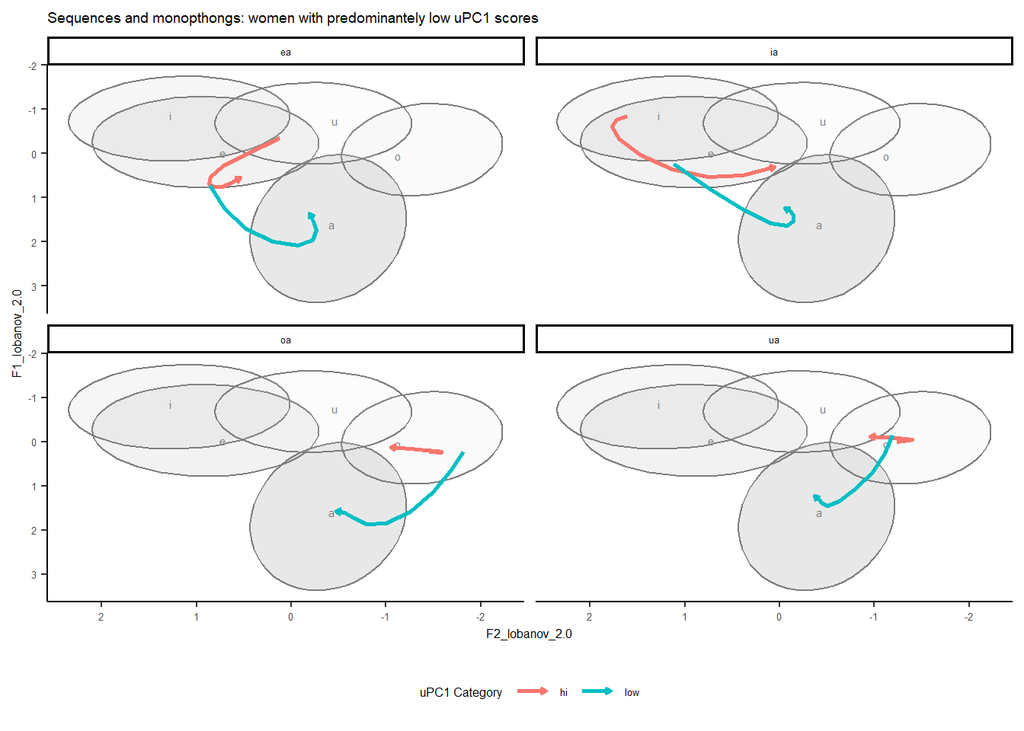

```r
femalemono = low_scoring_mono %>% filter(participant_gender == "F")
femaleseq = predictions %>% filter(participant_gender == "F")

fplot <- femalemono %>%
  ggplot(aes(x = F2_lobanov_2.0, y = F1_lobanov_2.0, colour = Target.teAkaSegment)) +
   stat_ellipse(level = 0.67, geom = "polygon", alpha = 0.1, aes(fill = Target.teAkaSegment), show.legend = FALSE) +
  scale_x_reverse() + scale_y_reverse() +
   scale_fill_grey(start = 0.1, end = 0.9) +
    geom_text(data= monophthong_means,
            aes(x = F2_lobanov_2.0, y = F1_lobanov_2.0, label = Target.teAkaSegment),  show.legend = FALSE, size = 2)  +
 geom_path(data = femaleseq, aes(
    x = F2_lobanov_2.0,
    y = F1_lobanov_2.0,
    colour = PC1cat),
    size = 1, show.legend = TRUE,
    arrow = arrow(length = unit(1, "mm")), size = 1) +
  scale_color_manual(values = c("hi" = "#F8766D", "low" = "#00BFC4")) +
   guides(colour = guide_legend(title = "uPC1 Category"), fill = "none", linewidth = "none")


fplot    + theme_classic() +
 facet_wrap(~Vowel, nrow = 2) +
  labs(title = "Sequences and monopthongs: women with predominantely low uPC1 scores") +
  theme(
    text = element_text(size = 6),
    legend.position = "bottom"
  )
```

10. Plot men

**Click here to view code.**

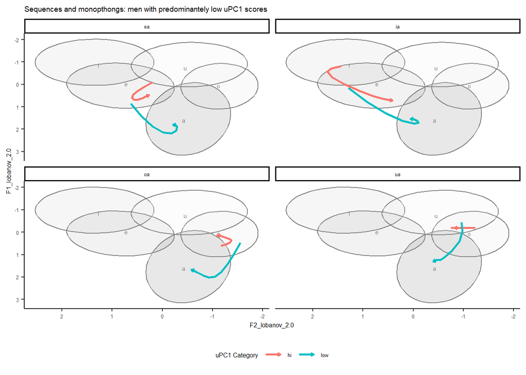

```r
malemono = low_scoring_mono %>% filter(participant_gender == "M")
maleseq = predictions %>% filter(participant_gender == "M")

mplot <- malemono %>%
  ggplot(aes(x = F2_lobanov_2.0, y = F1_lobanov_2.0, colour = Target.teAkaSegment)) +
   stat_ellipse(level = 0.67, geom = "polygon", alpha = 0.1, aes(fill = Target.teAkaSegment), show.legend = FALSE) +
  scale_x_reverse() + scale_y_reverse() +
   scale_fill_grey(start = 0.1, end = 0.9) +
    geom_text(data= monophthong_means,
            aes(x = F2_lobanov_2.0, y = F1_lobanov_2.0, label = Target.teAkaSegment),  show.legend = FALSE, size = 2)  +
 geom_path(data = maleseq, aes(
    x = F2_lobanov_2.0,
    y = F1_lobanov_2.0,
    colour = PC1cat),
    size = 1, show.legend = TRUE,
    arrow = arrow(length = unit(1, "mm")), size = 1) +
  scale_color_manual(values = c("hi" = "#F8766D", "low" = "#00BFC4")) +
   guides(colour = guide_legend(title = "uPC1 Category"), fill = "none", linewidth = "none")


mplot    + theme_classic()+
 facet_wrap(~Vowel, nrow = 2) +
  labs(title = "Sequences and monopthongs: men with predominantely low uPC1 scores") +
  theme(
    text = element_text(size = 6),
    legend.position = "bottom"
  )
```

# 10 Regression analysis (Manuscript §4.2)

## 10.1 Custom functions

1. Function to get the local mean monophthong duration within a window of X seconds (default 10) either side of a target timestamp in a target transcript

**Click here to view code.**

```r
 local_mean_duration = function(target_transcript, target_timestamp, window=10) {
  monopthong_dat %>%
    filter(transcript == target_transcript, abs(target_timestamp - timestamp) <= window) %>%
    pull(duration) %>%
    mean(.)
}
```

2. Function to center variables

**Click here to view code.**

```r
c. <- function (x) scale(x, scale = FALSE)
```

3. Function to calculate VIFs and display them in a table

**Click here to view code.**

```r
display_vif = function(mod, output_kable=TRUE, ...) {
  table <- vif(mod, type="terms")
  # Check if VIFs or GVIFs have been calculated
  if (is.null(dim(table))) {
    table <- vif_table(table, output_kable, ...)
  } else {
    table <- gvif_table(table, output_kable, ...)
  }
  return(table)
}
```

4. Function to neatly display a VIF table

**Click here to view code.**

```r
vif_table = function(table, output_kable=TRUE, ...) {
  table = table %>%
    data.frame() %>%
    rlang::set_names(c("vif")) %>%
    rownames_to_column("parameter") %>%
    mutate(
      parameter = parameter %>%
        str_replace_all(
          .,
          "(?<=^|\\:)(?:c\\.\\()([^:]+)(?:\\))(?=$|\\:)",
          "\\1 (centered)"
        ) %>%
        str_replace_all(., fixed(":"), " &times; ")
    )
  if (output_kable) {
    table = table %>%
    kable(digits=3, escape=F, col.names=c("Parameter", "VIF"), align="lr", ...) %>%
    kable_styling()
  }
  return(table)
}
```

5. Function to neatly display a GVIF table

**Click here to view code.**

```r
gvif_table = function(table, output_kable=TRUE, ...) {
  table = table %>%
    data.frame() %>%
    rlang::set_names(c("gvif", "df", "transformed")) %>%
    rownames_to_column("parameter") %>%
    mutate(
      parameter = parameter %>%
        str_replace_all(
          .,
          "(?<=^|\\:)(?:c\\.\\()([^:]+)(?:\\))(?=$|\\:)",
          "\\1 (centered)"
        ) %>%
        str_replace_all(., fixed(":"), " &times; "),
      transformed = transformed ^ 2
    )
  if (output_kable) {
    table = table %>%
    kable(digits=3, escape=F, col.names=c("Parameter", "GVIF", "df", "Transformed GVIF"), align="lrrr", ...) %>%
    kable_styling()
  }
  return(table)
}
```

6. Function to create table of the regression results with the Estimate, SE, df, t, and p values rounded to 3 decimal places

**Click here to view code.**

```r
format_lmer_table <- function(model, digits = 3) {
  model_summary <- summary(model)

  coefs <- as.data.frame(coef(summary(model)))

  coefs <- coefs %>%
    rename(Estimate = Estimate, SE = `Std. Error`, df = `df`,
           t = `t value`, p = `Pr(>|t|)`) %>%
    mutate(
      across(c(Estimate, SE, t), ~ round(.x, digits)),
      df = round(df, 0),
      p = ifelse(p < 0.001, "<0.001", sprintf(paste0("%.", digits, "f"), p))
    )

  return(coefs)
}
```

## 10.2 Calculate local speech rate for each sequence token

This code is used to determine the local speech rate measures used in the regression analyses. Used to determine the mean duration of monophthongs in a transcript within a window of 10 seconds either side of a given sequence.

1. Monophthongs data if needed

**Click here to view code.**

```r
monophthongs = read.csv(here("Data", "monophthongsfinal.csv"))
```

2. Calculate monophthong duration

**Click here to view code.**

```r
monophthongs$duration  =  monophthongs$Target.teAkaSegment.end - monophthongs$Target.teAkaSegment.start

mono <- monophthongs %>%
  select(Transcript, Speaker, duration, Target.teAkaSegment.start)


monopthong_dat <-  mono %>%
  rename(timestamp = Target.teAkaSegment.start) %>%
  rename(transcript = Transcript)
```

3. Add local speech rate (using function defined above) for /ia/ tokens + save data frame

**Click here to view code.**

```r
ia <- read.csv(here("Data", "ia_uPCAresults.csv")) %>%
  left_join(
        read.csv(here("Data", "MAONZE_opening_seqs.csv"), header=TRUE, encoding="UTF-8") %>%
          select(Transcript, MatchId, Target.vowelCluster.start)
      )

ia <-  ia %>%
  rename(target_timestamp = Target.vowelCluster.start) %>%
  rename(target_transcript = Transcript)


ia <- ia %>%
 mutate(
    mean_rate = map2_dbl(ia$target_transcript, ia$target_timestamp, local_mean_duration, window = 10)
  )

 ia <- ia %>%
  drop_na(mean_rate)

write.csv(ia, here("Data","ia_PC_results_local_rate.csv"))
```

3. Add local speech rate for /ea/ tokens + save data frame

**Click here to view code.**

```r
ea <- read.csv(here("Data", "ea_uPCAresults.csv")) %>%
  left_join(
        read.csv(here("Data", "MAONZE_opening_seqs.csv"), header=TRUE, encoding="UTF-8") %>%
          select(Transcript, MatchId, Target.vowelCluster.start)
      )

ea <-  ea %>%
  rename(target_timestamp = Target.vowelCluster.start) %>%
  rename(target_transcript = Transcript)


ea <- ea %>%
 mutate(
    mean_rate = map2_dbl(ea$target_transcript, ea$target_timestamp, local_mean_duration, window = 10)
  )

 ea <- ea %>%
  drop_na(mean_rate)

write.csv(ea, here("Data","ea_PC_results_local_rate.csv"))
```

4. Add local speech rate for /oa/ tokens + save data frame

**Click here to view code.**

```r
oa <- read.csv(here("Data", "oa_uPCAresults.csv")) %>%
  left_join(
        read.csv(here("Data", "MAONZE_opening_seqs.csv"), header=TRUE, encoding="UTF-8") %>%
          select(Transcript, MatchId, Target.vowelCluster.start)
      )

oa <-  oa %>%
  rename(target_timestamp = Target.vowelCluster.start) %>%
  rename(target_transcript = Transcript)


oa <- oa %>%
 mutate(
    mean_rate = map2_dbl(oa$target_transcript,oa$target_timestamp, local_mean_duration, window = 10)
  )

 oa <- oa %>%
  drop_na(mean_rate)

write.csv(oa, here("Data","oa_PC_results_local_rate.csv"))
```

4. Add local speech rate for /ua/ tokens + save data frame

**Click here to view code.**

```r
ua <- read.csv(here("Data", "ua_uPCAresults.csv")) %>%
  left_join(
        read.csv(here("Data", "MAONZE_opening_seqs.csv"), header=TRUE, encoding="UTF-8") %>%
          select(Transcript, MatchId, Target.vowelCluster.start)
      )

ua <-  ua %>%
  rename(target_timestamp = Target.vowelCluster.start) %>%
  rename(target_transcript = Transcript)


ua <- ua %>%
 mutate(
    mean_rate = map2_dbl(ua$target_transcript,ua$target_timestamp, local_mean_duration, window = 10)
  )

 ua <- ua %>%
  drop_na(mean_rate)

write.csv(ua, here("Data","ua_PC_results_local_rate.csv"))
```

## 10.3 /ia/ regression model

1. Read in data, create phonological form trackers

**Click here to view code.**

```r
ia = read.csv(here("Data","ia_PC_results_local_rate.csv"), header=TRUE, encoding="UTF-8", row.names=1) %>%
  # merge pause data
  left_join(
    read.csv(here("Data", "pause_info.csv"), header=TRUE, encoding="UTF-8", row.names=1),
    by = "MatchId"
  ) %>%
  # create phonological form trackers
  mutate(
    phon.word = word %>%
      str_replace("([AEIOU])\\1", "\\1") %>%
      str_replace(fixed("wh"), "f") %>%
      str_replace(fixed("ng"), "N"),
    prev_c = str_extract(phon.word, ".(?=ia)"),
    prev_c_tongue = case_when(
      prev_c %in% c("p", "m", "f", "h") ~ "neutral",
      prev_c %in% c("t", "n", "r") ~ "coronal",
      prev_c %in% c("k", "N", "w") ~ "dorsal"
    )
  )
```

2. Set up factors as required

**Click here to view code.**

```r
ia = ia %>%
  mutate(
    category = factor(category, levels=c("Historical", "PresentElder", "L1", "L2")),
    stress = factor(stress == "yes"),
    participant_gender = factor(participant_gender, levels=c("M", "F")),
    complex = factor(complex == "yes"),
    final = factor(final == "TRUE"),
    prev_c_tongue = factor(prev_c_tongue, levels=c("neutral", "coronal", "dorsal")),
    moraPositionFactor = ifelse(moraPosition > 2, "3+", moraPosition),
    moraPositionFactor = factor(moraPositionFactor, levels=c("1", "2", "3+")))
```

3. Set up contrasts for factors

**Click here to view code.**

```r
contrasts(ia$category) = matrix(c(c(-1,1,0,0)/2, c(-1,-1,1,1)/2, c(0,0,-1,1)/2), ncol=3)
colnames(contrasts(ia$category)) = c("|PresentElder.v.Historical", "|L1L2.v.HistoricalPresentElder", "|L2.v.L1")
contrasts(ia$stress) = contr.helmert(2)
colnames(contrasts(ia$stress)) = c("|y.v.n")
contrasts(ia$participant_gender) = contr.helmert(2)
colnames(contrasts(ia$participant_gender)) = c("|F.v.M")
contrasts(ia$complex) = contr.helmert(2)
colnames(contrasts(ia$complex)) = c("|y.v.n")
contrasts(ia$final) = contr.helmert(2)
colnames(contrasts(ia$final)) = c("|y.v.n")
contrasts(ia$prev_c_tongue) = contr.treatment(3) - 1/3
colnames(contrasts(ia$prev_c_tongue)) = c("|coronal.v.neutral", "|dorsal.v.neutral")
contrasts(ia$moraPositionFactor) <- contr.treatment(3)
```

4. Bin pause data

**Click here to view code.**

```r
ia = ia %>%
mutate(
  pause_bin = factor(pause_length > 0.25, levels=c(FALSE, TRUE)) )
```

5. Set up final_pause annotations and define contrasts

**Click here to view code.**

```r
ia <- ia %>%
  mutate(final_pause  = case_when(
    final == TRUE & pause_bin == TRUE ~ TRUE,
    final == TRUE & pause_bin == FALSE ~ FALSE,
    final == FALSE & pause_bin == TRUE ~ FALSE,
    final == FALSE & pause_bin == FALSE ~ FALSE,
  ))

contrasts(ia$final_pause) = contr.helmert(2)
colnames(contrasts(ia$final_pause)) = c("|y.v.n")
```

6. Inverse transform `mean_rate`, then remove potential leverage points <= 5 > 31

**Click here to view code.**

```r
ia <-  ia %>%
  mutate(mean_rate_transf = 1/mean_rate)  %>%
  filter(mean_rate_transf > 5, mean_rate_transf <  31)
```

The inverse transformation is due to the data skew, which is shown below. There various tokens of very slow speech that could be leverage points.

**Click here to view code.**

```r
with(ia, table(category, cut(mean_rate, breaks=c(seq(from=0.03, to=0.3, by=0.02), 1))))
```

```
category       (0.03,0.05] (0.05,0.07] (0.07,0.09] (0.09,0.11] (0.11,0.13]
  Historical            51         187         129          21           5
  PresentElder         135         548         225          42          14
  L1                    17         202         133          20           2
  L2                    21         129         119          19           9

category       (0.13,0.15] (0.15,0.17] (0.17,0.19] (0.19,0.21] (0.21,0.23]
  Historical             1           0           0           0           0
  PresentElder           5           2           2           0           0
  L1                     1           1           0           0           0
  L2                     6           0           0           0           0

category       (0.23,0.25] (0.25,0.27] (0.27,0.29] (0.29,1]
  Historical             0           0           0        0
  PresentElder           0           0           0        0
  L1                     0           0           0        0
  L2                     0           0           0        0
```

As shown here, inverse-transforming helps.

**Click here to view code.**

```r
with(ia, table(category, cut(1/mean_rate, breaks=seq(from=1, to=35, by=1))))
```

```
category       (1,2] (2,3] (3,4] (4,5] (5,6] (6,7] (7,8] (8,9] (9,10] (10,11]
  Historical       0     0     0     0     0     1     0     5     12       9
  PresentElder     0     0     0     0     2     3     8    10     17      22
  L1               0     0     0     0     0     1     1     1      2      17
  L2               0     0     0     0     0     2     9     4      2      16

category       (11,12] (12,13] (13,14] (14,15] (15,16] (16,17] (17,18] (18,19]
  Historical        32      39      43      50      50      34      30      19
  PresentElder      52      67      84      98     100     110     116      68
  L1                25      41      56      41      50      53      27      31
  L2                27      33      47      36      35      30      20      12

category       (19,20] (20,21] (21,22] (22,23] (23,24] (24,25] (25,26] (26,27]
  Historical        20      20      10       8       7       3       1       1
  PresentElder      83      53      26      12      21       9       8       3
  L1                13       5       7       1       2       0       1       1
  L2                 9       6       9       2       1       3       0       0

category       (27,28] (28,29] (29,30] (30,31] (31,32] (32,33] (33,34] (34,35]
  Historical         0       0       0       0       0       0       0       0
  PresentElder       0       0       1       0       0       0       0       0
  L1                 0       0       0       0       0       0       0       0
  L2                 0       0       0       0       0       0       0       0
```

7. Define model

**Click here to view code.**

```r
 hyp.mod.ia = lmer(PC1 ~ category * (participant_gender + moraPositionFactor + complex +  c.(mean_rate_transf)) + final_pause + prev_c_tongue + (1 | Speaker) + (1  | word.alt.format), data=ia, REML=F)
```

8. Check VIFs

**Click here to view code.**

```r
display_vif(hyp.mod.ia)
```

| Parameter | GVIF | df | Transformed GVIF |
| --- | --- | --- | --- |
| category | 28.580 | 3 | 3.057 |
| participant_gender | 1.158 | 1 | 1.158 |
| moraPositionFactor | 3.507 | 2 | 1.873 |
| complex | 3.263 | 1 | 3.263 |
| mean_rate_transf (centered) | 1.372 | 1 | 1.372 |
| final_pause | 1.010 | 1 | 1.010 |
| prev_c_tongue | 1.107 | 2 | 1.052 |
| category &times; participant_gender | 1.218 | 3 | 1.068 |
| category &times; moraPositionFactor | 51.929 | 6 | 1.932 |
| category &times; complex | 92.995 | 3 | 4.531 |
| category &times; mean_rate_transf (centered) | 1.456 | 3 | 1.134 |

9. Table of model results

**Click here to view code.**

```r
lmer_table_ia = format_lmer_table(hyp.mod.ia)
knitr::kable(lmer_table_ia, caption="Model of ia uPC1")
```

|  | Estimate | SE | df | t | p |
| --- | --- | --- | --- | --- | --- |
| (Intercept) | -0.911 | 0.198 | 51 | -4.603 | <0.001 |
| category\|PresentElder.v.Historical | 0.478 | 0.266 | 342 | 1.799 | 0.073 |
| category\|L1L2.v.HistoricalPresentElder | -0.817 | 0.240 | 448 | -3.408 | <0.001 |
| category\|L2.v.L1 | 0.069 | 0.395 | 503 | 0.175 | 0.861 |
| participant_gender\|F.v.M | -0.193 | 0.068 | 55 | -2.828 | 0.007 |
| moraPositionFactor2 | 0.582 | 0.301 | 75 | 1.935 | 0.057 |
| moraPositionFactor3 | 0.377 | 0.156 | 27 | 2.422 | 0.023 |
| complex\|y.v.n | 0.103 | 0.117 | 109 | 0.881 | 0.380 |
| c.(mean_rate_transf) | 0.019 | 0.010 | 2002 | 1.938 | 0.053 |
| final_pause\|y.v.n | -0.553 | 0.059 | 1979 | -9.394 | <0.001 |
| prev_c_tongue\|coronal.v.neutral | -0.131 | 0.125 | 105 | -1.046 | 0.298 |
| prev_c_tongue\|dorsal.v.neutral | 0.051 | 0.133 | 91 | 0.382 | 0.704 |
| category\|PresentElder.v.Historical:participant_gender\|F.v.M | -0.137 | 0.168 | 58 | -0.817 | 0.418 |
| category\|L1L2.v.HistoricalPresentElder:participant_gender\|F.v.M | -0.125 | 0.136 | 55 | -0.915 | 0.364 |
| category\|L2.v.L1:participant_gender\|F.v.M | -0.412 | 0.215 | 53 | -1.918 | 0.061 |
| category\|PresentElder.v.Historical:moraPositionFactor2 | 0.742 | 0.472 | 1478 | 1.570 | 0.117 |
| category\|L1L2.v.HistoricalPresentElder:moraPositionFactor2 | 0.352 | 0.466 | 1240 | 0.755 | 0.450 |
| category\|L2.v.L1:moraPositionFactor2 | -0.099 | 0.768 | 1973 | -0.129 | 0.897 |
| category\|PresentElder.v.Historical:moraPositionFactor3 | 0.102 | 0.156 | 1897 | 0.654 | 0.513 |
| category\|L1L2.v.HistoricalPresentElder:moraPositionFactor3 | 0.309 | 0.137 | 1645 | 2.258 | 0.024 |
| category\|L2.v.L1:moraPositionFactor3 | 0.237 | 0.216 | 1917 | 1.097 | 0.273 |
| category\|PresentElder.v.Historical:complex\|y.v.n | -0.164 | 0.198 | 1342 | -0.829 | 0.407 |
| category\|L1L2.v.HistoricalPresentElder:complex\|y.v.n | 0.217 | 0.192 | 1627 | 1.132 | 0.258 |
| category\|L2.v.L1:complex\|y.v.n | 0.036 | 0.324 | 1974 | 0.110 | 0.913 |
| category\|PresentElder.v.Historical:c.(mean_rate_transf) | 0.003 | 0.023 | 1912 | 0.133 | 0.895 |
| category\|L1L2.v.HistoricalPresentElder:c.(mean_rate_transf) | -0.017 | 0.019 | 2001 | -0.878 | 0.380 |
| category\|L2.v.L1:c.(mean_rate_transf) | 0.019 | 0.032 | 2012 | 0.607 | 0.544 |

Model of ia uPC1

10. Get speaker intercepts, save as .csv

**Click here to view code.**

```r
speaker_intercepts_ia <- ranef(hyp.mod.ia)$Speaker

speaker_intercepts_ia_df <- data.frame(Speaker = rownames(speaker_intercepts_ia), Intercept = speaker_intercepts_ia[, 1])

speaker_intercepts_ia_df <- speaker_intercepts_ia_df %>%
  mutate(sequence = "ia" )

write.csv(speaker_intercepts_ia_df, here("Data", "speaker_intercepts_ia.csv"))
```

11. Investigate significant effects
1. Is there evidence of an overall category effect?

**Click here to view code.**

```r
hyp.mod.ia.min.cat <- update(hyp.mod.ia, ~ . - category - category:participant_gender - category:moraPositionFactor - category:complex  - category:c.(mean_rate_transf))
anova(hyp.mod.ia, hyp.mod.ia.min.cat)
```

```
Data: ia
Models:
hyp.mod.ia.min.cat: PC1 ~ participant_gender + moraPositionFactor + complex + c.(mean_rate_transf) + final_pause + prev_c_tongue + (1 | Speaker) + (1 | word.alt.format)
hyp.mod.ia: PC1 ~ category * (participant_gender + moraPositionFactor + complex + c.(mean_rate_transf)) + final_pause + prev_c_tongue + (1 | Speaker) + (1 | word.alt.format)
                   npar    AIC    BIC  logLik deviance  Chisq Df Pr(>Chisq)
hyp.mod.ia.min.cat   12 6479.7 6547.2 -3227.9   6455.7
hyp.mod.ia           30 6449.4 6618.0 -3194.7   6389.4 66.283 18  1.902e-07 ***
---
Signif. codes:  0 '***' 0.001 '**' 0.01 '*' 0.05 '.' 0.1 ' ' 1
```

Yes, there is.

2. Investigating category differences further with an EMM test

**Click here to view code.**

```r
emmeans(hyp.mod.ia, pairwise ~ category)
```

```
$emmeans
 category      emmean    SE  df lower.CL upper.CL
 Historical   -0.6726 0.182 193   -1.031   -0.315
 PresentElder  0.0868 0.151 184   -0.211    0.385
 L1           -0.9469 0.212 218   -1.365   -0.528
 L2           -0.8318 0.224 206   -1.274   -0.389

Results are averaged over the levels of: participant_gender, moraPositionFactor, complex, final_pause, prev_c_tongue
Degrees-of-freedom method: kenward-roger
Confidence level used: 0.95

$contrasts
 contrast                  estimate    SE  df t.ratio p.value
 Historical - PresentElder   -0.759 0.200 118  -3.800  0.0013
 Historical - L1              0.274 0.256 162   1.071  0.7080
 Historical - L2              0.159 0.264 155   0.604  0.9307
 PresentElder - L1            1.034 0.233 152   4.439  0.0001
 PresentElder - L2            0.919 0.241 145   3.810  0.0012
 L1 - L2                     -0.115 0.283 163  -0.407  0.9771

Results are averaged over the levels of: participant_gender, moraPositionFactor, complex, final_pause, prev_c_tongue
Degrees-of-freedom method: kenward-roger
P value adjustment: tukey method for comparing a family of 4 estimates
```

**Click here to view code.**

```r
hyp.mod.ia.min.gen <- update(hyp.mod.ia, ~ . - participant_gender - category:participant_gender)
anova(hyp.mod.ia, hyp.mod.ia.min.gen)
```

```
Data: ia
Models:
hyp.mod.ia.min.gen: PC1 ~ category + moraPositionFactor + complex + c.(mean_rate_transf) + final_pause + prev_c_tongue + (1 | Speaker) + (1 | word.alt.format) + category:moraPositionFactor + category:complex + category:c.(mean_rate_transf)
hyp.mod.ia: PC1 ~ category * (participant_gender + moraPositionFactor + complex + c.(mean_rate_transf)) + final_pause + prev_c_tongue + (1 | Speaker) + (1 | word.alt.format)
                   npar    AIC    BIC  logLik deviance  Chisq Df Pr(>Chisq)
hyp.mod.ia.min.gen   26 6452.7 6598.8 -3200.3   6400.7
hyp.mod.ia           30 6449.4 6618.0 -3194.7   6389.4 11.255  4    0.02385 *
---
Signif. codes:  0 '***' 0.001 '**' 0.01 '*' 0.05 '.' 0.1 ' ' 1
```

Yes, there is.

4. Investigating gender differences further with an EMM test

**Click here to view code.**

```r
emmeans(hyp.mod.ia, pairwise ~ participant_gender)
```

```
$emmeans
 participant_gender emmean    SE  df lower.CL upper.CL
 M                  -0.398 0.143 191   -0.679   -0.117
 F                  -0.784 0.143 185   -1.065   -0.503

Results are averaged over the levels of: category, moraPositionFactor, complex, final_pause, prev_c_tongue
Degrees-of-freedom method: kenward-roger
Confidence level used: 0.95

$contrasts
 contrast estimate    SE   df t.ratio p.value
 M - F       0.386 0.148 71.4   2.610  0.0110

Results are averaged over the levels of: category, moraPositionFactor, complex, final_pause, prev_c_tongue
Degrees-of-freedom method: kenward-roger
```

Signficant pairwise comparision for gender.

5. Is there an overall effect of mora position?|

**Click here to view code.**

```r
hyp.mod.ia.min.moraPos <- update(hyp.mod.ia, ~ . - moraPositionFactor - category:moraPositionFactor)
anova(hyp.mod.ia, hyp.mod.ia.min.moraPos) #
```

```
Data: ia
Models:
hyp.mod.ia.min.moraPos: PC1 ~ category + participant_gender + complex + c.(mean_rate_transf) + final_pause + prev_c_tongue + (1 | Speaker) + (1 | word.alt.format) + category:participant_gender + category:complex + category:c.(mean_rate_transf)
hyp.mod.ia: PC1 ~ category * (participant_gender + moraPositionFactor + complex + c.(mean_rate_transf)) + final_pause + prev_c_tongue + (1 | Speaker) + (1 | word.alt.format)
                       npar    AIC    BIC  logLik deviance  Chisq Df Pr(>Chisq)
hyp.mod.ia.min.moraPos   22 6447.8 6571.4 -3201.9   6403.8
hyp.mod.ia               30 6449.4 6618.0 -3194.7   6389.4 14.374  8    0.07253

hyp.mod.ia.min.moraPos
hyp.mod.ia             .
---
Signif. codes:  0 '***' 0.001 '**' 0.01 '*' 0.05 '.' 0.1 ' ' 1
```

No significant effect of mora position by itself. Indicates that effect lies in interactions.

6. Investigating further by conducting an EMM test on the interaction with category.

**Click here to view code.**

```r
emmeans(hyp.mod.ia, pairwise ~ moraPositionFactor| category)
```

```
$emmeans
category = Historical:
 moraPositionFactor   emmean    SE  df lower.CL upper.CL
 1                  -0.74139 0.286 236   -1.305  -0.1779
 2                  -0.70615 0.330 507   -1.354  -0.0579
 3+                 -0.57035 0.229 385   -1.021  -0.1194

category = PresentElder:
 moraPositionFactor   emmean    SE  df lower.CL upper.CL
 1                  -0.26327 0.239 134   -0.736   0.2099
 2                   0.51360 0.243 351    0.036   0.9912
 3+                  0.00997 0.183 286   -0.350   0.3698

category = L1:
 moraPositionFactor   emmean    SE  df lower.CL upper.CL
 1                  -1.35362 0.321 420   -1.984  -0.7233
 2                  -0.54609 0.398 939   -1.327   0.2351
 3+                 -0.94108 0.289 636   -1.509  -0.3737

category = L2:
 moraPositionFactor   emmean    SE  df lower.CL upper.CL
 1                  -1.28450 0.350 396   -1.972  -0.5965
 2                  -0.57627 0.453 949   -1.465   0.3120
 3+                 -0.63469 0.303 546   -1.230  -0.0396

Results are averaged over the levels of: participant_gender, complex, final_pause, prev_c_tongue
Degrees-of-freedom method: kenward-roger
Confidence level used: 0.95

$contrasts
category = Historical:
 contrast estimate    SE     df t.ratio p.value
 1 - 2     -0.0352 0.464  349.4  -0.076  0.9968
 1 - (3+)  -0.1710 0.208  121.4  -0.822  0.6900
 2 - (3+)  -0.1358 0.417  468.6  -0.325  0.9433

category = PresentElder:
 contrast estimate    SE     df t.ratio p.value
 1 - 2     -0.7769 0.345  169.7  -2.250  0.0659
 1 - (3+)  -0.2732 0.177   62.3  -1.544  0.2778
 2 - (3+)   0.5036 0.305  256.7   1.652  0.2260

category = L1:
 contrast estimate    SE     df t.ratio p.value
 1 - 2     -0.8075 0.553  895.7  -1.461  0.3102
 1 - (3+)  -0.4125 0.211  137.1  -1.957  0.1270
 2 - (3+)   0.3950 0.528 1160.8   0.748  0.7349

category = L2:
 contrast estimate    SE     df t.ratio p.value
 1 - 2     -0.7082 0.635  786.3  -1.116  0.5047
 1 - (3+)  -0.6498 0.227  175.3  -2.859  0.0132
 2 - (3+)   0.0584 0.591  973.0   0.099  0.9946

Results are averaged over the levels of: participant_gender, complex, final_pause, prev_c_tongue
Degrees-of-freedom method: kenward-roger
P value adjustment: tukey method for comparing a family of 3 estimates
```

No significant difference between mora positions within any of the categories, except for 1 - (3+) for the Young L2 speakers.

## 10.4 /ea/ regression model

1. Read in data, create phonological form trackers

**Click here to view code.**

```r
ea = read.csv(here("Data", "ea_PC_results_local_rate.csv"), header=TRUE, encoding="UTF-8", row.names=1) %>%
  # merge pause data
  left_join(
    read.csv(here("Data", "pause_info.csv"), header=TRUE, encoding="UTF-8", row.names=1),
    by = "MatchId"
  ) %>%
  mutate(
    phon.word = word %>%
      str_replace("([AEIOU])\\1", "\\1") %>%
      str_replace(fixed("wh"), "f") %>%
      str_replace(fixed("ng"), "N"),
    prev_c = str_extract(phon.word, ".(?=ea)"),
    prev_c_tongue = case_when(
      prev_c %in% c("p", "m", "f", "h") ~ "neutral",
      prev_c %in% c("t", "n", "r") ~ "coronal",
      prev_c %in% c("k", "N", "w") ~ "dorsal"
    )
  )
```

2. Set up factors as required

**Click here to view code.**

```r
ea = ea %>%
  mutate(
    category = factor(category, levels=c("Historical", "PresentElder", "L1", "L2")),
    stress = factor(stress == "yes"),
    participant_gender = factor(participant_gender, levels=c("M", "F")),
    complex = factor(complex == "yes"),
    final = factor(final == "TRUE"),
    prev_c_tongue = factor(prev_c_tongue, levels=c("neutral", "coronal", "dorsal")),
    moraPositionFactor = ifelse(moraPosition > 2, "3+", moraPosition),
    moraPositionFactor = factor(moraPositionFactor, levels=c("1", "2", "3+")))
```

3. Set up contrasts for factors

**Click here to view code.**

```r
contrasts(ea$category) = matrix(c(c(-1,1,0,0)/2, c(-1,-1,1,1)/2, c(0,0,-1,1)/2), ncol=3)
colnames(contrasts(ea$category)) = c("|PresentElder.v.Historical", "|L1L2.v.HistoricalPresentElder", "|L2.v.L1")

contrasts(ea$stress) = contr.helmert(2)
colnames(contrasts(ea$stress)) = c("|y.v.n")
contrasts(ea$participant_gender) = contr.helmert(2)
colnames(contrasts(ea$participant_gender)) = c("|F.v.M")
contrasts(ea$complex) = contr.helmert(2)
colnames(contrasts(ea$complex)) = c("|y.v.n")
contrasts(ea$final) = contr.helmert(2)
colnames(contrasts(ea$final)) = c("|y.v.n")
contrasts(ea$prev_c_tongue) = contr.treatment(3) - 1/3
colnames(contrasts(ea$prev_c_tongue)) = c("|coronal.v.neutral", "|dorsal.v.neutral")
contrasts(ea$moraPositionFactor) <- contr.treatment(3)
```

4. Bin pause data

**Click here to view code.**

```r
ea = ea %>%
  mutate(
    pause_bin = factor(pause_length > 0.25, levels=c(FALSE, TRUE)))
```

5. Set up final_pause annotations and define contrasts

**Click here to view code.**

```r
ea <- ea %>%
  mutate(final_pause  = case_when(
    final == TRUE & pause_bin == TRUE ~ TRUE,
    final == TRUE & pause_bin == FALSE ~ FALSE,
    final == FALSE & pause_bin == TRUE ~ FALSE,
    final == FALSE & pause_bin == FALSE ~ FALSE,
  ))


contrasts(ea$final_pause) = contr.helmert(2)
colnames(contrasts(ea$final_pause)) = c("|y.v.n")
```

6. Inverse transform `mean_rate`, then remove potential leverage points <= 5 > 31. Reasoning for this descision is shwon for /ia/ above.

**Click here to view code.**

```r
ea <-  ea %>%
  mutate(mean_rate_transf = 1/mean_rate) %>%
  filter(mean_rate_transf > 5, mean_rate_transf <  31)
```

7. Define model

**Click here to view code.**

```r
hyp.mod.ea <-  lmer(PC1 ~ category * (participant_gender +   complex   +c.(mean_rate_transf) ) + final_pause +    prev_c_tongue + (1   | Speaker) + (1  | word.alt.format), data=ea, REML=F)
```

8. Check VIFs

**Click here to view code.**

```r
display_vif(hyp.mod.ea)
```

| Parameter | GVIF | df | Transformed GVIF |
| --- | --- | --- | --- |
| category | 2.584 | 3 | 1.372 |
| participant_gender | 1.122 | 1 | 1.122 |
| complex | 1.808 | 1 | 1.808 |
| mean_rate_transf (centered) | 1.452 | 1 | 1.452 |
| final_pause | 1.007 | 1 | 1.007 |
| prev_c_tongue | 1.694 | 2 | 1.302 |
| category &times; participant_gender | 1.157 | 3 | 1.050 |
| category &times; complex | 2.926 | 3 | 1.430 |
| category &times; mean_rate_transf (centered) | 1.580 | 3 | 1.165 |

9. Table of model results

**Click here to view code.**

```r
lmer_table_ea = format_lmer_table(hyp.mod.ea)
knitr::kable(lmer_table_ea, caption="Model of ea uPC1")
```

|  | Estimate | SE | df | t | p |
| --- | --- | --- | --- | --- | --- |
| (Intercept) | -0.991 | 0.106 | 112 | -9.334 | <0.001 |
| category\|PresentElder.v.Historical | 0.423 | 0.220 | 152 | 1.926 | 0.056 |
| category\|L1L2.v.HistoricalPresentElder | -0.068 | 0.163 | 107 | -0.415 | 0.679 |
| category\|L2.v.L1 | 0.433 | 0.241 | 83 | 1.796 | 0.076 |
| participant_gender\|F.v.M | -0.074 | 0.070 | 59 | -1.051 | 0.298 |
| complex\|y.v.n | -0.239 | 0.078 | 52 | -3.084 | 0.003 |
| c.(mean_rate_transf) | 0.034 | 0.009 | 2704 | 3.953 | <0.001 |
| final_pause\|y.v.n | -0.665 | 0.046 | 2737 | -14.533 | <0.001 |
| prev_c_tongue\|coronal.v.neutral | -0.155 | 0.129 | 58 | -1.201 | 0.234 |
| prev_c_tongue\|dorsal.v.neutral | -0.052 | 0.198 | 65 | -0.262 | 0.794 |
| category\|PresentElder.v.Historical:participant_gender\|F.v.M | -0.258 | 0.181 | 72 | -1.427 | 0.158 |
| category\|L1L2.v.HistoricalPresentElder:participant_gender\|F.v.M | -0.099 | 0.140 | 59 | -0.707 | 0.482 |
| category\|L2.v.L1:participant_gender\|F.v.M | -0.142 | 0.214 | 52 | -0.663 | 0.511 |
| category\|PresentElder.v.Historical:complex\|y.v.n | -0.362 | 0.155 | 2721 | -2.335 | 0.020 |
| category\|L1L2.v.HistoricalPresentElder:complex\|y.v.n | -0.233 | 0.102 | 2752 | -2.295 | 0.022 |
| category\|L2.v.L1:complex\|y.v.n | -0.208 | 0.131 | 2720 | -1.593 | 0.111 |
| category\|PresentElder.v.Historical:c.(mean_rate_transf) | -0.012 | 0.025 | 2555 | -0.474 | 0.636 |
| category\|L1L2.v.HistoricalPresentElder:c.(mean_rate_transf) | 0.037 | 0.017 | 2700 | 2.135 | 0.033 |
| category\|L2.v.L1:c.(mean_rate_transf) | 0.001 | 0.024 | 2757 | 0.023 | 0.982 |

Model of ea uPC1

10. Get speaker intercepts, save as .csv

**Click here to view code.**

```r
speaker_intercepts_ea <- ranef(hyp.mod.ea)$Speaker

speaker_intercepts_ea_df <- data.frame(Speaker = rownames(speaker_intercepts_ea), Intercept = speaker_intercepts_ea[, 1])

speaker_intercepts_ea_df <- speaker_intercepts_ea_df %>%
  mutate(sequence = "ea" )

write.csv(speaker_intercepts_ea_df, here("Data", "speaker_intercepts_ea.csv"))
```

11. Investigate significant effects
1. Is there evidence of an overall category effect?

**Click here to view code.**

```r
hyp.mod.ea.min.cat <- update(hyp.mod.ea, ~ . - category - category:participant_gender - category:stress - category:complex - category:c.(mean_rate_transf))
anova(hyp.mod.ea, hyp.mod.ea.min.cat)
```

```
Data: ea
Models:
hyp.mod.ea.min.cat: PC1 ~ participant_gender + complex + c.(mean_rate_transf) + final_pause + prev_c_tongue + (1 | Speaker) + (1 | word.alt.format)
hyp.mod.ea: PC1 ~ category * (participant_gender + complex + c.(mean_rate_transf)) + final_pause + prev_c_tongue + (1 | Speaker) + (1 | word.alt.format)
                   npar    AIC    BIC  logLik deviance  Chisq Df Pr(>Chisq)
hyp.mod.ea.min.cat   10 8933.0 8992.3 -4456.5   8913.0
hyp.mod.ea           22 8916.5 9046.8 -4436.3   8872.5 40.525 12  5.882e-05 ***
---
Signif. codes:  0 '***' 0.001 '**' 0.01 '*' 0.05 '.' 0.1 ' ' 1
```

Yes there is.

2. Investigating category differences further with an EMM test

**Click here to view code.**

```r
emmeans(hyp.mod.ea, pairwise ~ category)
```

```
$emmeans
 category     emmean    SE  df lower.CL upper.CL
 Historical   -1.169 0.208 250    -1.58   -0.760
 PresentElder -0.746 0.149 131    -1.04   -0.452
 L1           -1.241 0.189 112    -1.62   -0.867
 L2           -0.809 0.205 133    -1.21   -0.403

Results are averaged over the levels of: participant_gender, complex, final_pause, prev_c_tongue
Degrees-of-freedom method: kenward-roger
Confidence level used: 0.95

$contrasts
 contrast                  estimate    SE    df t.ratio p.value
 Historical - PresentElder  -0.4230 0.230 166.2  -1.836  0.2603
 Historical - L1             0.0726 0.259 137.4   0.281  0.9923
 Historical - L2            -0.3604 0.271 149.9  -1.330  0.5455
 PresentElder - L1           0.4956 0.213  89.6   2.324  0.1002
 PresentElder - L2           0.0627 0.228 105.1   0.275  0.9927
 L1 - L2                    -0.4329 0.257  97.0  -1.687  0.3361

Results are averaged over the levels of: participant_gender, complex, final_pause, prev_c_tongue
Degrees-of-freedom method: kenward-roger
P value adjustment: tukey method for comparing a family of 4 estimates
```

No significant differences. Indicates category effect lies in interactions

3. Is category significant at any level of complex?

**Click here to view code.**

```r
emmeans(hyp.mod.ea, pairwise ~  category| complex)
```

```
$emmeans
complex = FALSE:
 category     emmean    SE  df lower.CL upper.CL
 Historical   -1.227 0.182 147   -1.587   -0.867
 PresentElder -0.442 0.152 148   -0.742   -0.141
 L1           -0.989 0.189 110   -1.365   -0.614
 L2           -0.349 0.195 105   -0.735    0.038

complex = TRUE:
 category     emmean    SE  df lower.CL upper.CL
 Historical   -1.111 0.317 622   -1.733   -0.488
 PresentElder -1.050 0.202 129   -1.450   -0.650
 L1           -1.493 0.244 181   -1.975   -1.012
 L2           -1.269 0.279 286   -1.817   -0.720

Results are averaged over the levels of: participant_gender, final_pause, prev_c_tongue
Degrees-of-freedom method: kenward-roger
Confidence level used: 0.95

$contrasts
complex = FALSE:
 contrast                  estimate    SE    df t.ratio p.value
 Historical - PresentElder  -0.7853 0.196  82.7  -4.016  0.0007
 Historical - L1            -0.2376 0.226  76.2  -1.053  0.7188
 Historical - L2            -0.8785 0.231  76.0  -3.797  0.0016
 PresentElder - L1           0.5477 0.196  61.4   2.789  0.0346
 PresentElder - L2          -0.0932 0.203  62.1  -0.459  0.9676
 L1 - L2                    -0.6409 0.232  61.5  -2.762  0.0370

complex = TRUE:
 contrast                  estimate    SE    df t.ratio p.value
 Historical - PresentElder  -0.0608 0.342 678.8  -0.178  0.9980
 Historical - L1             0.3827 0.369 522.0   1.037  0.7278
 Historical - L2             0.1578 0.393 595.7   0.402  0.9781
 PresentElder - L1           0.4435 0.273 258.8   1.624  0.3670
 PresentElder - L2           0.2186 0.305 351.4   0.717  0.8902
 L1 - L2                    -0.2249 0.335 299.6  -0.672  0.9078

Results are averaged over the levels of: participant_gender, final_pause, prev_c_tongue
Degrees-of-freedom method: kenward-roger
P value adjustment: tukey method for comparing a family of 4 estimates
```

4. Is there a significant overall effect of complex?

**Click here to view code.**

```r
hyp.mod.ea.min.complex <- update(hyp.mod.ea, ~ . - complex - category:complex)

anova(hyp.mod.ea, hyp.mod.ea.min.complex)
```

```
Data: ea
Models:
hyp.mod.ea.min.complex: PC1 ~ category + participant_gender + c.(mean_rate_transf) + final_pause + prev_c_tongue + (1 | Speaker) + (1 | word.alt.format) + category:participant_gender + category:c.(mean_rate_transf)
hyp.mod.ea: PC1 ~ category * (participant_gender + complex + c.(mean_rate_transf)) + final_pause + prev_c_tongue + (1 | Speaker) + (1 | word.alt.format)
                       npar    AIC    BIC  logLik deviance  Chisq Df Pr(>Chisq)
hyp.mod.ea.min.complex   18 8923.8 9030.4 -4443.9   8887.8
hyp.mod.ea               22 8916.5 9046.8 -4436.3   8872.5 15.246  4   0.004218

hyp.mod.ea.min.complex
hyp.mod.ea             **
---
Signif. codes:  0 '***' 0.001 '**' 0.01 '*' 0.05 '.' 0.1 ' ' 1
```

Yes there is.

4. Investigating further with an EMM test

**Click here to view code.**

```r
emmeans(hyp.mod.ea, pairwise ~ complex)
```

```
$emmeans
 complex emmean    SE    df lower.CL upper.CL
 FALSE   -0.752 0.124 160.5   -0.996   -0.508
 TRUE    -1.231 0.163  66.4   -1.557   -0.904

Results are averaged over the levels of: category, participant_gender, final_pause, prev_c_tongue
Degrees-of-freedom method: kenward-roger
Confidence level used: 0.95

$contrasts
 contrast     estimate    SE   df t.ratio p.value
 FALSE - TRUE    0.479 0.174 53.6   2.758  0.0079

Results are averaged over the levels of: category, participant_gender, final_pause, prev_c_tongue
Degrees-of-freedom method: kenward-roger
```

Significant pairwise comparison

## 10.5 /oa/ regression model

1. Read in data, create phonological form trackers

**Click here to view code.**

```r
oa = read.csv(here("Data", "oa_PC_results_local_rate.csv"), header=TRUE, encoding="UTF-8", row.names=1) %>%
  # merge pause data
  left_join(
    read.csv(here("Data", "pause_info.csv"), header=TRUE, encoding="UTF-8", row.names=1),
    by = "MatchId"
  ) %>%
  mutate(
    phon.word = word %>%
      str_replace("([AEIOU])\\1", "\\1") %>%
      str_replace(fixed("wh"), "f") %>%
      str_replace(fixed("ng"), "N"),
    prev_c = str_extract(phon.word, ".(?=oa)"),
    prev_c_tongue = case_when(
      prev_c %in% c("p", "m", "f", "h") ~ "neutral",
      prev_c %in% c("t", "n", "r") ~ "coronal",
      prev_c %in% c("k", "N", "w") ~ "dorsal"
    )
  )
```

2. Set up factors as required

**Click here to view code.**

```r
oa = oa %>%
  mutate(
    category = factor(category, levels=c("Historical", "PresentElder", "L1", "L2")),
    stress = factor(stress == "yes"),
    participant_gender = factor(participant_gender, levels=c("M", "F")),
    complex = factor(complex == "yes"),
    final = factor(final == "TRUE"),
    prev_c_tongue = factor(prev_c_tongue, levels=c("neutral", "coronal", "dorsal")),
    moraPositionFactor = ifelse(moraPosition > 2, "3+", moraPosition),
    moraPositionFactor = factor(moraPositionFactor, levels=c("1", "2", "3+")))
```

3. Set up contrasts for factors

**Click here to view code.**

```r
contrasts(oa$category) = matrix(c(c(-1,1,0,0)/2, c(-1,-1,1,1)/2, c(0,0,-1,1)/2), ncol=3)
colnames(contrasts(oa$category)) = c("|PresentElder.v.Historical", "|L1L2.v.HistoricalPresentElder", "|L2.v.L1")
contrasts(oa$stress) = contr.helmert(2)
colnames(contrasts(oa$stress)) = c("|y.v.n")
contrasts(oa$participant_gender) = contr.helmert(2)
colnames(contrasts(oa$participant_gender)) = c("|F.v.M")
contrasts(oa$complex) = contr.helmert(2)
colnames(contrasts(oa$complex)) = c("|y.v.n")
contrasts(oa$final) = contr.helmert(2)
colnames(contrasts(oa$final)) = c("|y.v.n")
contrasts(oa$prev_c_tongue) = contr.treatment(3) - 1/3
colnames(contrasts(oa$prev_c_tongue)) = c("|coronal.v.neutral", "|dorsal.v.neutral")
contrasts(oa$moraPositionFactor) <- contr.treatment(3)
```

4. Bin pause data

**Click here to view code.**

```r
  oa = oa %>%
  mutate(
    pause_bin = factor(pause_length > 0.25, levels=c(FALSE, TRUE)) )
```

5. Set up final_pause annotations and define contrasts

**Click here to view code.**

```r
oa <- oa %>%
  mutate(final_pause  = case_when(
    final == TRUE & pause_bin == TRUE ~ TRUE,
    final == TRUE & pause_bin == FALSE ~ FALSE,
    final == FALSE & pause_bin == TRUE ~ FALSE,
    final == FALSE & pause_bin == FALSE ~ FALSE,
  ))

contrasts(oa$final_pause) = contr.helmert(2)
colnames(contrasts(oa$final_pause)) = c("|y.v.n")
```

6. Inverse transform `mean_rate`, then remove potential leverage points <= 5 > 31. See /ia/ section for reasoning.

**Click here to view code.**

```r
oa <-  oa %>%
  mutate(mean_rate_transf = 1/mean_rate)  %>%
  filter(mean_rate_transf > 5, mean_rate_transf <  31)
```

7. Define model

**Click here to view code.**

```r
hyp.mod.oa =  lmer(PC1 ~ category * (participant_gender + moraPositionFactor  + complex  +  c.(mean_rate_transf)) +  final_pause +  prev_c_tongue + (1 | Speaker) + (1  | word.alt.format), data=oa, REML=F)
```

8. Check VIFs

**Click here to view code.**

```r
display_vif(hyp.mod.oa)
```

| Parameter | GVIF | df | Transformed GVIF |
| --- | --- | --- | --- |
| category | 55.417 | 3 | 3.813 |
| participant_gender | 1.148 | 1 | 1.148 |
| moraPositionFactor | 2.003 | 2 | 1.415 |
| complex | 1.624 | 1 | 1.624 |
| mean_rate_transf (centered) | 1.346 | 1 | 1.346 |
| final_pause | 1.030 | 1 | 1.030 |
| prev_c_tongue | 1.420 | 2 | 1.192 |
| category &times; participant_gender | 1.255 | 3 | 1.079 |
| category &times; moraPositionFactor | 4.352 | 6 | 1.278 |
| category &times; complex | 31.169 | 3 | 3.147 |
| category &times; mean_rate_transf (centered) | 1.519 | 3 | 1.150 |

9. Table of model results

**Click here to view code.**

```r
lmer_table_oa = format_lmer_table(hyp.mod.oa)
knitr::kable(lmer_table_oa, caption="Model of oa uPC1")
```

|  | Estimate | SE | df | t | p |
| --- | --- | --- | --- | --- | --- |
| (Intercept) | -0.626 | 0.195 | 48 | -3.210 | 0.002 |
| category\|PresentElder.v.Historical | -0.035 | 0.269 | 535 | -0.130 | 0.897 |
| category\|L1L2.v.HistoricalPresentElder | -0.276 | 0.234 | 556 | -1.179 | 0.239 |
| category\|L2.v.L1 | 0.258 | 0.363 | 626 | 0.710 | 0.478 |
| participant_gender\|F.v.M | -0.097 | 0.059 | 59 | -1.639 | 0.107 |
| moraPositionFactor2 | 0.303 | 0.241 | 17 | 1.257 | 0.225 |
| moraPositionFactor3 | 0.175 | 0.200 | 34 | 0.875 | 0.388 |
| complex\|y.v.n | -0.173 | 0.126 | 44 | -1.375 | 0.176 |
| c.(mean_rate_transf) | 0.036 | 0.011 | 1618 | 3.218 | 0.001 |
| final_pause\|y.v.n | -0.232 | 0.058 | 1671 | -3.994 | <0.001 |
| prev_c_tongue\|coronal.v.neutral | 0.577 | 0.174 | 21 | 3.316 | 0.003 |
| prev_c_tongue\|dorsal.v.neutral | 0.226 | 0.233 | 25 | 0.970 | 0.341 |
| category\|PresentElder.v.Historical:participant_gender\|F.v.M | -0.261 | 0.153 | 70 | -1.699 | 0.094 |
| category\|L1L2.v.HistoricalPresentElder:participant_gender\|F.v.M | -0.447 | 0.118 | 60 | -3.779 | <0.001 |
| category\|L2.v.L1:participant_gender\|F.v.M | -0.060 | 0.180 | 52 | -0.336 | 0.738 |
| category\|PresentElder.v.Historical:moraPositionFactor2 | 0.417 | 0.197 | 1689 | 2.121 | 0.034 |
| category\|L1L2.v.HistoricalPresentElder:moraPositionFactor2 | 0.280 | 0.158 | 1684 | 1.772 | 0.077 |
| category\|L2.v.L1:moraPositionFactor2 | -0.205 | 0.242 | 1660 | -0.846 | 0.398 |
| category\|PresentElder.v.Historical:moraPositionFactor3 | 0.356 | 0.273 | 1628 | 1.301 | 0.193 |
| category\|L1L2.v.HistoricalPresentElder:moraPositionFactor3 | 0.685 | 0.192 | 1576 | 3.561 | <0.001 |
| category\|L2.v.L1:moraPositionFactor3 | 0.271 | 0.259 | 1687 | 1.044 | 0.297 |
| category\|PresentElder.v.Historical:complex\|y.v.n | -0.185 | 0.206 | 1603 | -0.896 | 0.370 |
| category\|L1L2.v.HistoricalPresentElder:complex\|y.v.n | -0.044 | 0.187 | 857 | -0.235 | 0.814 |
| category\|L2.v.L1:complex\|y.v.n | -0.177 | 0.292 | 1616 | -0.606 | 0.545 |
| category\|PresentElder.v.Historical:c.(mean_rate_transf) | -0.013 | 0.027 | 1520 | -0.479 | 0.632 |
| category\|L1L2.v.HistoricalPresentElder:c.(mean_rate_transf) | -0.007 | 0.022 | 1611 | -0.298 | 0.766 |
| category\|L2.v.L1:c.(mean_rate_transf) | -0.029 | 0.035 | 1643 | -0.835 | 0.404 |

Model of oa uPC1

10. Get speaker intercepts, save as .csv

**Click here to view code.**

```r
speaker_intercepts_oa <- ranef(hyp.mod.oa)$Speaker

speaker_intercepts_oa_df <- data.frame(Speaker = rownames(speaker_intercepts_oa), Intercept = speaker_intercepts_oa[, 1])

speaker_intercepts_oa_df <- speaker_intercepts_oa_df %>%
  mutate(sequence = "oa" )

write.csv(speaker_intercepts_oa_df, here("Data", "speaker_intercepts_oa.csv"))
```

11. Investigate significant effects
1. Is there evidence of an overall category effect?

**Click here to view code.**

```r
hyp.mod.oa.min.cat <- update(hyp.mod.oa, ~ . - category - category:participant_gender - category:moraPositionFactor - category:complex - category:c.(mean_rate_transf))
anova(hyp.mod.oa, hyp.mod.oa.min.cat)
```

```
Data: oa
Models:
hyp.mod.oa.min.cat: PC1 ~ participant_gender + moraPositionFactor + complex + c.(mean_rate_transf) + final_pause + prev_c_tongue + (1 | Speaker) + (1 | word.alt.format)
hyp.mod.oa: PC1 ~ category * (participant_gender + moraPositionFactor + complex + c.(mean_rate_transf)) + final_pause + prev_c_tongue + (1 | Speaker) + (1 | word.alt.format)
                   npar    AIC    BIC  logLik deviance  Chisq Df Pr(>Chisq)
hyp.mod.oa.min.cat   12 5607.3 5672.5 -2791.7   5583.3
hyp.mod.oa           30 5600.6 5763.7 -2770.3   5540.6 42.711 18  0.0008789 ***
---
Signif. codes:  0 '***' 0.001 '**' 0.01 '*' 0.05 '.' 0.1 ' ' 1
```

Yep, there is.

2. Investigating category differences with an EMM test

**Click here to view code.**

```r
emmeans(hyp.mod.oa, pairwise ~ category)
```

```
$emmeans
 category     emmean    SE  df lower.CL upper.CL
 Historical   -0.601 0.226 349   -1.046  -0.1560
 PresentElder -0.378 0.176 235   -0.726  -0.0306
 L1           -0.583 0.255 454   -1.084  -0.0821
 L2           -0.303 0.274 509   -0.842   0.2347

Results are averaged over the levels of: participant_gender, moraPositionFactor, complex, final_pause, prev_c_tongue
Degrees-of-freedom method: kenward-roger
Confidence level used: 0.95

$contrasts
 contrast                  estimate    SE  df t.ratio p.value
 Historical - PresentElder  -0.2227 0.245 401  -0.909  0.8000
 Historical - L1            -0.0179 0.315 500  -0.057  0.9999
 Historical - L2            -0.2975 0.325 525  -0.915  0.7970
 PresentElder - L1           0.2048 0.279 458   0.733  0.8836
 PresentElder - L2          -0.0748 0.293 495  -0.255  0.9942
 L1 - L2                    -0.2796 0.339 557  -0.825  0.8429

Results are averaged over the levels of: participant_gender, moraPositionFactor, complex, final_pause, prev_c_tongue
Degrees-of-freedom method: kenward-roger
P value adjustment: tukey method for comparing a family of 4 estimates
```

No significant differences, suggests category effect lies in the interactions

3. Investigating further by conducting an EMM test on the interaction of category and gender

**Click here to view code.**

```r
emmeans(hyp.mod.oa, pairwise ~  participant_gender |category)
```

```
$emmeans
category = Historical:
 participant_gender  emmean    SE  df lower.CL upper.CL
 M                  -0.8581 0.251 296   -1.351 -0.36476
 F                  -0.3437 0.275 257   -0.885  0.19784

category = PresentElder:
 participant_gender  emmean    SE  df lower.CL upper.CL
 M                  -0.3747 0.205 195   -0.779  0.02996
 F                  -0.3817 0.196 212   -0.769  0.00557

category = L1:
 participant_gender  emmean    SE  df lower.CL upper.CL
 M                  -0.2926 0.289 267   -0.862  0.27678
 F                  -0.8734 0.285 328   -1.435 -0.31235

category = L2:
 participant_gender  emmean    SE  df lower.CL upper.CL
 M                   0.0473 0.307 298   -0.557  0.65189
 F                  -0.6542 0.311 335   -1.266 -0.04263

Results are averaged over the levels of: moraPositionFactor, complex, final_pause, prev_c_tongue
Degrees-of-freedom method: kenward-roger
Confidence level used: 0.95

$contrasts
category = Historical:
 contrast estimate    SE   df t.ratio p.value
 M - F    -0.51438 0.269 97.6  -1.914  0.0586

category = PresentElder:
 contrast estimate    SE   df t.ratio p.value
 M - F     0.00696 0.192 64.2   0.036  0.9712

category = L1:
 contrast estimate    SE   df t.ratio p.value
 M - F     0.58081 0.265 61.7   2.194  0.0320

category = L2:
 contrast estimate    SE   df t.ratio p.value
 M - F     0.70149 0.286 67.1   2.451  0.0169

Results are averaged over the levels of: moraPositionFactor, complex, final_pause, prev_c_tongue
Degrees-of-freedom method: kenward-roger
```

Significant differences in the L1 + L2 categories.

4. Is there an overall effect of gender?

**Click here to view code.**

```r
hyp.mod.oa.min.gender<- update(hyp.mod.oa, ~ . - participant_gender - category:participant_gender)
anova(hyp.mod.oa, hyp.mod.oa.min.gender)
```

```
Data: oa
Models:
hyp.mod.oa.min.gender: PC1 ~ category + moraPositionFactor + complex + c.(mean_rate_transf) + final_pause + prev_c_tongue + (1 | Speaker) + (1 | word.alt.format) + category:moraPositionFactor + category:complex + category:c.(mean_rate_transf)
hyp.mod.oa: PC1 ~ category * (participant_gender + moraPositionFactor + complex + c.(mean_rate_transf)) + final_pause + prev_c_tongue + (1 | Speaker) + (1 | word.alt.format)
                      npar    AIC    BIC  logLik deviance  Chisq Df Pr(>Chisq)
hyp.mod.oa.min.gender   26 5607.4 5748.7 -2777.7   5555.4
hyp.mod.oa              30 5600.6 5763.7 -2770.3   5540.6 14.774  4   0.005193

hyp.mod.oa.min.gender
hyp.mod.oa            **
---
Signif. codes:  0 '***' 0.001 '**' 0.01 '*' 0.05 '.' 0.1 ' ' 1
```

yes

5. Is there an overall effect of mora position?

**Click here to view code.**

```r
hyp.mod.oa.min.moraPos <- update(hyp.mod.oa, ~ . - moraPositionFactor - category:moraPositionFactor)
anova(hyp.mod.oa, hyp.mod.oa.min.moraPos)
```

```
Data: oa
Models:
hyp.mod.oa.min.moraPos: PC1 ~ category + participant_gender + complex + c.(mean_rate_transf) + final_pause + prev_c_tongue + (1 | Speaker) + (1 | word.alt.format) + category:participant_gender + category:complex + category:c.(mean_rate_transf)
hyp.mod.oa: PC1 ~ category * (participant_gender + moraPositionFactor + complex + c.(mean_rate_transf)) + final_pause + prev_c_tongue + (1 | Speaker) + (1 | word.alt.format)
                       npar    AIC    BIC  logLik deviance  Chisq Df Pr(>Chisq)
hyp.mod.oa.min.moraPos   22 5605.6 5725.2 -2780.8   5561.6
hyp.mod.oa               30 5600.6 5763.7 -2770.3   5540.6 21.038  8   0.007047

hyp.mod.oa.min.moraPos
hyp.mod.oa             **
---
Signif. codes:  0 '***' 0.001 '**' 0.01 '*' 0.05 '.' 0.1 ' ' 1
```

yes.

6. Investigate interaction with category further by conducting an EMM test

**Click here to view code.**

```r
emmeans(hyp.mod.oa, pairwise ~ moraPositionFactor| category)
```

```
$emmeans
category = Historical:
 moraPositionFactor  emmean    SE  df lower.CL upper.CL
 1                  -0.4704 0.299 260   -1.058   0.1176
 2                  -0.5164 0.282 218   -1.073   0.0398
 3+                 -0.8159 0.305 319   -1.416  -0.2156

category = PresentElder:
 moraPositionFactor  emmean    SE  df lower.CL upper.CL
 1                  -0.5053 0.238 122   -0.977  -0.0338
 2                  -0.1342 0.230 111   -0.589   0.3206
 3+                 -0.4951 0.242 154   -0.973  -0.0175

category = L1:
 moraPositionFactor  emmean    SE  df lower.CL upper.CL
 1                  -0.8922 0.311 309   -1.504  -0.2800
 2                  -0.3470 0.286 229   -0.911   0.2174
 3+                 -0.5099 0.333 349   -1.164   0.1442

category = L2:
 moraPositionFactor  emmean    SE  df lower.CL upper.CL
 1                  -0.6345 0.345 386   -1.313   0.0435
 2                  -0.2942 0.301 280   -0.887   0.2990
 3+                  0.0184 0.344 407   -0.657   0.6936

Results are averaged over the levels of: participant_gender, complex, final_pause, prev_c_tongue
Degrees-of-freedom method: kenward-roger
Confidence level used: 0.95

$contrasts
category = Historical:
 contrast estimate    SE    df t.ratio p.value
 1 - 2      0.0460 0.326  81.2   0.141  0.9891
 1 - (3+)   0.3455 0.317 270.4   1.091  0.5206
 2 - (3+)   0.2995 0.344 150.7   0.871  0.6597

category = PresentElder:
 contrast estimate    SE    df t.ratio p.value
 1 - 2     -0.3711 0.291  47.4  -1.274  0.4166
 1 - (3+)  -0.0102 0.236  73.7  -0.043  0.9990
 2 - (3+)   0.3608 0.288  60.7   1.253  0.4271

category = L1:
 contrast estimate    SE    df t.ratio p.value
 1 - 2     -0.5453 0.320  76.2  -1.705  0.2098
 1 - (3+)  -0.3823 0.278 141.6  -1.378  0.3554
 2 - (3+)   0.1629 0.323  96.9   0.504  0.8694

category = L2:
 contrast estimate    SE    df t.ratio p.value
 1 - 2     -0.3404 0.336  93.6  -1.013  0.5707
 1 - (3+)  -0.6529 0.294 177.4  -2.218  0.0709
 2 - (3+)  -0.3126 0.329 105.9  -0.950  0.6101

Results are averaged over the levels of: participant_gender, complex, final_pause, prev_c_tongue
Degrees-of-freedom method: kenward-roger
P value adjustment: tukey method for comparing a family of 3 estimates
```

No significant differences between mora positions within any category.

## 10.6 /ua/ regression model

1. Read in data, create phonological form trackers

**Click here to view code.**

```r
ua = read.csv(here("Data", "ua_PC_results_local_rate.csv"), header=TRUE, encoding="UTF-8", row.names=1) %>%
  # merge pause data
  left_join(
    read.csv(here("Data", "pause_info.csv"), header=TRUE, encoding="UTF-8", row.names=1),
    by = "MatchId"
  ) %>%
  mutate(
    phon.word = word %>%
      str_replace("([AEIOU])\\1", "\\1") %>%
      str_replace(fixed("wh"), "f") %>%
      str_replace(fixed("ng"), "N"),
    prev_c = str_extract(phon.word, ".(?=ua)"),
    prev_c_tongue = case_when(
      prev_c %in% c("p", "m", "f", "h") ~ "neutral",
      prev_c %in% c("t", "n", "r") ~ "coronal",
      prev_c %in% c("k", "N", "w") ~ "dorsal"
    )
  )
```

2. Set up factors as required

**Click here to view code.**

```r
ua = ua %>%
  mutate(
    category = factor(category, levels=c("Historical", "PresentElder", "L1", "L2")),
    stress = factor(stress == "yes"),
    participant_gender = factor(participant_gender, levels=c("M", "F")),
    complex = factor(complex == "yes"),
    final = factor(final == "TRUE"),
    prev_c_tongue = factor(prev_c_tongue, levels=c("neutral", "coronal", "dorsal")),
    moraPositionFactor = ifelse(moraPosition > 2, "3+", moraPosition),
    moraPositionFactor = factor(moraPositionFactor, levels=c("1", "2", "3+")))
```

3. Set up contrasts for factors

**Click here to view code.**

```r
contrasts(ua$category) = matrix(c(c(-1,1,0,0)/2, c(-1,-1,1,1)/2, c(0,0,-1,1)/2), ncol=3)
colnames(contrasts(ua$category)) = c("|PresentElder.v.Historical", "|L1L2.v.HistoricalPresentElder", "|L2.v.L1")
contrasts(ua$stress) = contr.helmert(2)
colnames(contrasts(ua$stress)) = c("|y.v.n")
contrasts(ua$participant_gender) = contr.helmert(2)
colnames(contrasts(ua$participant_gender)) = c("|F.v.M")
contrasts(ua$complex) = contr.helmert(2)
colnames(contrasts(ua$complex)) = c("|y.v.n")
contrasts(ua$final) = contr.helmert(2)
colnames(contrasts(ua$final)) = c("|y.v.n")
contrasts(ua$prev_c_tongue) = contr.treatment(3) - 1/3
colnames(contrasts(ua$prev_c_tongue)) = c("|coronal.v.neutral", "|dorsal.v.neutral")
contrasts(ea$moraPositionFactor) <- contr.treatment(3)
```

4. Bin pause data

**Click here to view code.**

```r
  ua = ua %>%
  mutate(
    pause_bin = factor(pause_length > 0.25, levels=c(FALSE, TRUE)) )
```

5. Set up final_pause annotations and define contrasts

**Click here to view code.**

```r
  ua <- ua %>%
  mutate(final_pause  = case_when(
    final == TRUE & pause_bin == TRUE ~ TRUE,
    final == TRUE & pause_bin == FALSE ~ FALSE,
    final == FALSE & pause_bin == TRUE ~ FALSE,
    final == FALSE & pause_bin == FALSE ~ FALSE,
  ))

contrasts(ua$final_pause) = contr.helmert(2)
colnames(contrasts(ua$final_pause)) = c("|y.v.n")
```

6. Inverse transform `mean_rate`, then remove potential leverage points <= 5 > 31, see /ia/ section for reasoning.

**Click here to view code.**

```r
ua <-  ua %>%
  mutate(mean_rate_transf = 1/mean_rate)  %>%
  filter(mean_rate_transf > 5, mean_rate_transf <  31)
```

7. Flip the polarity of the PC1 scores so that they match the others

**Click here to view code.**

```r
ua$PC1 = -1*(ua$PC1)
```

8. Define model

**Click here to view code.**

```r
 hyp.mod.ua =  lmer(PC1 ~ category * (participant_gender+  complex +  c.(mean_rate_transf)) +   final_pause  + prev_c_tongue + (1   | Speaker) + (1 | word.alt.format), data=ua, REML=F)
```

9. Check VIFs

**Click here to view code.**

```r
display_vif(hyp.mod.ua)
```

| Parameter | GVIF | df | Transformed GVIF |
| --- | --- | --- | --- |
| category | 30.056 | 3 | 3.109 |
| participant_gender | 1.122 | 1 | 1.122 |
| complex | 1.230 | 1 | 1.230 |
| mean_rate_transf (centered) | 1.210 | 1 | 1.210 |
| final_pause | 1.006 | 1 | 1.006 |
| prev_c_tongue | 1.025 | 2 | 1.012 |
| category &times; participant_gender | 1.163 | 3 | 1.052 |
| category &times; complex | 31.480 | 3 | 3.158 |
| category &times; mean_rate_transf (centered) | 1.251 | 3 | 1.078 |

10. Table of model results

**Click here to view code.**

```r
lmer_table_ua = format_lmer_table(hyp.mod.ua)
knitr::kable(lmer_table_ua, caption="Model of ua uPC1")
```

|  | Estimate | SE | df | t | p |
| --- | --- | --- | --- | --- | --- |
| (Intercept) | -0.758 | 0.113 | 122 | -6.708 | <0.001 |
| category\|PresentElder.v.Historical | 0.483 | 0.166 | 298 | 2.904 | 0.004 |
| category\|L1L2.v.HistoricalPresentElder | 0.133 | 0.162 | 489 | 0.818 | 0.414 |
| category\|L2.v.L1 | 0.292 | 0.265 | 608 | 1.103 | 0.271 |
| participant_gender\|F.v.M | -0.183 | 0.044 | 52 | -4.168 | <0.001 |
| complex\|y.v.n | -0.189 | 0.085 | 145 | -2.218 | 0.028 |
| c.(mean_rate_transf) | 0.052 | 0.007 | 3414 | 7.554 | <0.001 |
| final_pause\|y.v.n | -0.413 | 0.044 | 3924 | -9.279 | <0.001 |
| prev_c_tongue\|coronal.v.neutral | 0.338 | 0.110 | 46 | 3.083 | 0.003 |
| prev_c_tongue\|dorsal.v.neutral | 0.344 | 0.232 | 34 | 1.482 | 0.147 |
| category\|PresentElder.v.Historical:participant_gender\|F.v.M | -0.182 | 0.111 | 62 | -1.640 | 0.106 |
| category\|L1L2.v.HistoricalPresentElder:participant_gender\|F.v.M | -0.203 | 0.088 | 53 | -2.315 | 0.025 |
| category\|L2.v.L1:participant_gender\|F.v.M | -0.194 | 0.136 | 47 | -1.425 | 0.161 |
| category\|PresentElder.v.Historical:complex\|y.v.n | 0.078 | 0.139 | 3216 | 0.565 | 0.572 |
| category\|L1L2.v.HistoricalPresentElder:complex\|y.v.n | 0.228 | 0.143 | 1347 | 1.589 | 0.112 |
| category\|L2.v.L1:complex\|y.v.n | 0.253 | 0.235 | 3096 | 1.078 | 0.281 |
| category\|PresentElder.v.Historical:c.(mean_rate_transf) | -0.025 | 0.017 | 3312 | -1.440 | 0.150 |
| category\|L1L2.v.HistoricalPresentElder:c.(mean_rate_transf) | 0.002 | 0.014 | 3404 | 0.135 | 0.893 |
| category\|L2.v.L1:c.(mean_rate_transf) | -0.033 | 0.021 | 3476 | -1.567 | 0.117 |

Model of ua uPC1

11. Get speaker intercepts, save as .csv

**Click here to view code.**

```r
speaker_intercepts_ua <- ranef(hyp.mod.ua)$Speaker

speaker_intercepts_ua_df <- data.frame(Speaker = rownames(speaker_intercepts_ua), Intercept = speaker_intercepts_ua[, 1])

speaker_intercepts_ua_df <- speaker_intercepts_ua_df %>%
  mutate(sequence = "ua" )

write.csv(speaker_intercepts_ua_df, here("Data", "speaker_intercepts_ua.csv"))
```

12. Investigate significant effects
1. Is there evidence of an overall category effect?

**Click here to view code.**

```r
hyp.mod.ua.min.cat <- update(hyp.mod.ua, ~ . - category - category:participant_gender -  - category:complex - category:c.(mean_rate_transf))
anova(hyp.mod.ua, hyp.mod.ua.min.cat)
```

```
Data: ua
Models:
hyp.mod.ua.min.cat: PC1 ~ participant_gender + complex + c.(mean_rate_transf) + final_pause + prev_c_tongue + (1 | Speaker) + (1 | word.alt.format) + category:complex
hyp.mod.ua: PC1 ~ category * (participant_gender + complex + c.(mean_rate_transf)) + final_pause + prev_c_tongue + (1 | Speaker) + (1 | word.alt.format)
                   npar   AIC   BIC  logLik deviance  Chisq Df Pr(>Chisq)
hyp.mod.ua.min.cat   16 12660 12760 -6313.9    12628
hyp.mod.ua           22 12659 12797 -6307.3    12615 13.225  6    0.03959 *
---
Signif. codes:  0 '***' 0.001 '**' 0.01 '*' 0.05 '.' 0.1 ' ' 1
```

Yes there is. b) Investigating category differences with an EMM test

**Click here to view code.**

```r
emmeans(hyp.mod.ua, pairwise ~ category)
```

```
$emmeans
 category     emmean    SE  df asymp.LCL asymp.UCL
 Historical   -1.066 0.161 Inf    -1.382    -0.751
 PresentElder -0.583 0.132 Inf    -0.842    -0.325
 L1           -0.838 0.188 Inf    -1.205    -0.470
 L2           -0.546 0.219 Inf    -0.974    -0.118

Results are averaged over the levels of: participant_gender, complex, final_pause, prev_c_tongue
Degrees-of-freedom method: asymptotic
Confidence level used: 0.95

$contrasts
 contrast                  estimate    SE  df z.ratio p.value
 Historical - PresentElder  -0.4832 0.166 Inf  -2.904  0.0193
 Historical - L1            -0.2286 0.221 Inf  -1.034  0.7296
 Historical - L2            -0.5204 0.249 Inf  -2.089  0.1568
 PresentElder - L1           0.2546 0.200 Inf   1.275  0.5787
 PresentElder - L2          -0.0372 0.229 Inf  -0.162  0.9985
 L1 - L2                    -0.2918 0.265 Inf  -1.103  0.6880

Results are averaged over the levels of: participant_gender, complex, final_pause, prev_c_tongue
Degrees-of-freedom method: asymptotic
P value adjustment: tukey method for comparing a family of 4 estimates
```

Only significant differences between historical and present elders (already captured by model terms)

3. Investigating further by conducting an EMM test on the interaction of category and gender

**Click here to view code.**

```r
emmeans(hyp.mod.ua, pairwise ~  participant_gender |category)
```

```
$emmeans
category = Historical:
 participant_gender emmean    SE  df asymp.LCL asymp.UCL
 M                  -1.076 0.175 Inf    -1.419    -0.733
 F                  -1.057 0.193 Inf    -1.434    -0.679

category = PresentElder:
 participant_gender emmean    SE  df asymp.LCL asymp.UCL
 M                  -0.411 0.152 Inf    -0.708    -0.114
 F                  -0.755 0.144 Inf    -1.038    -0.473

category = L1:
 participant_gender emmean    SE  df asymp.LCL asymp.UCL
 M                  -0.650 0.211 Inf    -1.064    -0.237
 F                  -1.025 0.207 Inf    -1.432    -0.619

category = L2:
 participant_gender emmean    SE  df asymp.LCL asymp.UCL
 M                  -0.165 0.242 Inf    -0.640     0.311
 F                  -0.927 0.238 Inf    -1.394    -0.461

Results are averaged over the levels of: complex, final_pause, prev_c_tongue
Degrees-of-freedom method: asymptotic
Confidence level used: 0.95

$contrasts
category = Historical:
 contrast estimate    SE  df z.ratio p.value
 M - F     -0.0194 0.177 Inf  -0.109  0.9129

category = PresentElder:
 contrast estimate    SE  df z.ratio p.value
 M - F      0.3441 0.133 Inf   2.582  0.0098

category = L1:
 contrast estimate    SE  df z.ratio p.value
 M - F      0.3752 0.186 Inf   2.023  0.0431

category = L2:
 contrast estimate    SE  df z.ratio p.value
 M - F      0.7627 0.199 Inf   3.833  0.0001

Results are averaged over the levels of: complex, final_pause, prev_c_tongue
Degrees-of-freedom method: asymptotic
```

4. Is there evidence of an overall gender effect?

**Click here to view code.**

```r
hyp.mod.ua.min.gender <- update(hyp.mod.ua, ~ . - participant_gender - category:participant_gender)
anova(hyp.mod.ua, hyp.mod.ua.min.gender)
```

```
Data: ua
Models:
hyp.mod.ua.min.gender: PC1 ~ category + complex + c.(mean_rate_transf) + final_pause + prev_c_tongue + (1 | Speaker) + (1 | word.alt.format) + category:complex + category:c.(mean_rate_transf)
hyp.mod.ua: PC1 ~ category * (participant_gender + complex + c.(mean_rate_transf)) + final_pause + prev_c_tongue + (1 | Speaker) + (1 | word.alt.format)
                      npar   AIC   BIC  logLik deviance  Chisq Df Pr(>Chisq)
hyp.mod.ua.min.gender   18 12671 12784 -6317.4    12635
hyp.mod.ua              22 12659 12797 -6307.3    12615 20.254  4   0.000445

hyp.mod.ua.min.gender
hyp.mod.ua            ***
---
Signif. codes:  0 '***' 0.001 '**' 0.01 '*' 0.05 '.' 0.1 ' ' 1
```

yes

## 10.7 Marginal effects plots

**Click here to view code.**

```r
 oa$category <- factor(oa$category,
                                       levels = c("Historical", "PresentElder", "L1", "L2"),
                                    labels = c("Historical elders", "Present elders", "Young L1", "Young L2"))


 ua$category <- factor(ua$category,
                                       levels = c("Historical", "PresentElder", "L1", "L2"),
                                    labels = c("Historical elders", "Present elders", "Young L1", "Young L2"))


 hyp.mod.oa_renamed =  lmer(PC1 ~ category * (participant_gender + moraPositionFactor  + complex  +  c.(mean_rate_transf)) +  final_pause +  prev_c_tongue + (1 | Speaker) + (1  | word.alt.format), data=oa, REML=F)

  hyp.mod.ua_renamed =  lmer(PC1 ~ category * (participant_gender+  complex + moraPositionFactor + c.(mean_rate_transf)) +   final_pause  + prev_c_tongue + (1   | Speaker) + (1 | word.alt.format), data=ua, REML=F)
```

### 10.7.1 Category and gender effects (Manuscript §4.2.1)

#### 10.7.1.1 /oa/ and /ua/ category * gender (Manuscript Figure 7)

1. Rename factor levels so that the labels are more informative
2. Define plots

**Click here to view code.**

```r
PC1_CatGenderoa  <- plot_model(hyp.mod.oa_renamed, type = "pred", terms = c("category", "participant_gender"),
      title = "/oa/", axis.title = c(NULL, "uPC1 score: hiatus-like ↔ diphthong-like"), show.legend = F)+
 labs(
    x = "Speaker Category",
  ) +
scale_color_manual(
     values = c("M" = "#1F78B4", "F" = "#E31A1C"),
     labels = c("M" = "Men", "F" = "Women")
   ) +
 theme_minimal()



PC1_CatGenderua <- plot_model(hyp.mod.ua_renamed, type = "pred", terms = c("category", "participant_gender"),
      title = "/ua/", axis.title = c(NULL, "uPC1 score: hiatus-like ↔ diphthong-like"))+
   labs(
    x = "Speaker Category",
    color = "Speaker Gender"
  )+
scale_color_manual(
     values = c("M" = "#1F78B4", "F" = "#E31A1C"), # Optional: specify colors
     labels = c("M" = "Men", "F" = "Women")       # Update labels for legend
   ) +
 theme_minimal() + theme(legend.position="bottom")
```

3. Combine plots and save

**Click here to view code.**

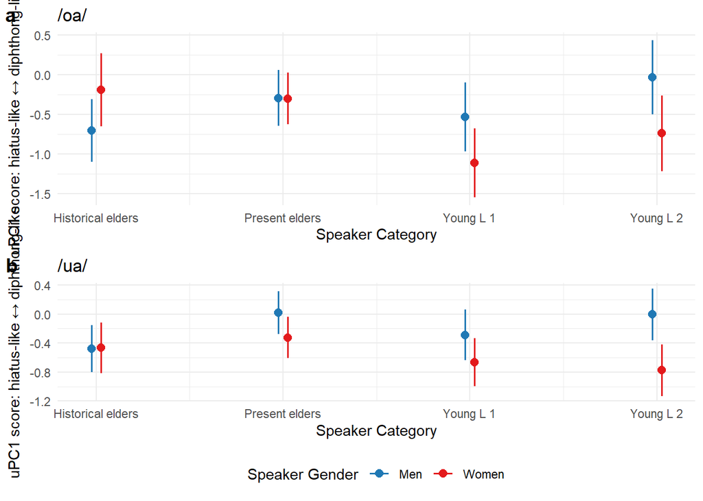

```r
CatGendercombined <- cowplot::plot_grid(PC1_CatGenderoa, PC1_CatGenderua,
                            labels = c("a", "b"), ncol = 1, align = "c", axis = "l")

CatGendercombined
```

**Click here to view code.**

```r
ggsave(here( "Figures", "Plots", "RegressionAnalysis", "CatGendercombined.png"),  CatGendercombined, width = 5, height = 9, bg = 'white')
```

#### 10.7.1.2 /ia/ category and gender (Manuscript Figure 8 and 9)

1. Rename factor levels so that the labels are more informative

**Click here to view code.**

```r
 ia$category <- factor(ia$category,
                                       levels = c("Historical", "PresentElder", "L1", "L2"),
                                    labels = c("Historical elders", "Present elders", "Young L1", "Young L2"))

ia$participant_gender <- factor(ia$participant_gender,
                                       levels = c("M", "F"),
                                       labels = c("Men", "Women"))

hyp.mod.ia_renamed = lmer(PC1 ~ category * (participant_gender + moraPositionFactor + complex +  c.(mean_rate_transf)) + final_pause + prev_c_tongue + (1 | Speaker) + (1  | word.alt.format), data=ia, REML=F)
```

2. Define plots

**Click here to view code.**

```r
PC1_Genderia <- plot_model(hyp.mod.ia_renamed, type = "pred", terms = c( "participant_gender"),
           title = " ", axis.title = c("Speaker Gender", "uPC1 score: hiatus-like ↔ diphthong-like")) +
   theme_minimal()



PC1_Categoryia <- plot_model(hyp.mod.ia_renamed, type = "pred", terms = c( "category"),
           title = " ", axis.title = c("Speaker Category" , "uPC1 score: hiatus-like ↔ diphthong-like")) +
   theme_minimal()
```

3. Save

**Click here to view code.**

```r
ggsave(here("Figures", "Plots", "RegressionAnalysis", "iaPC1Cat.png"),  PC1_Categoryia, height = 10, width = 15, units = "cm", bg = 'white')

ggsave(here("Figures", "Plots", "RegressionAnalysis", "iaPC1Gender.png"),  PC1_Genderia, height = 10, width = 15, units = "cm", bg = 'white')
```

#### 10.7.1.3 /ia/ and /oa/ category* mora position (Manuscript Figure 10)

1. Define plots

**Click here to view code.**

```r
 PC1_CatMoraPosia <- plot_model(hyp.mod.ia_renamed, type = "pred", terms = c("category", "moraPositionFactor"),
           title = "/ia/", axis.title = c( "uPC1 score: hiatus-like ↔ diphthong-like"), show.legend = F)+
   labs(
    x = "Speaker Category",
    color = "Mora position"
  )+
  scale_color_manual(values = c("1" = "#33A02C", "2" = "#FF7F00", "3+" = "#6A3D9A")) +
 theme_minimal()


PC1_CatMoraPosoa <- plot_model(hyp.mod.oa_renamed, type = "pred", terms = c("category", "moraPositionFactor"),
           title = "/oa/", axis.title = c("category", "uPC1 score: hiatus-like ↔ diphthong-like"))+
   labs(
    x = "Speaker Category",
    color = "Mora position"
  )+
  scale_color_manual(values = c("1" = "#33A02C", "2" = "#FF7F00", "3+" = "#6A3D9A")) +
 theme_minimal() + theme(legend.position="bottom")
```

2. Combine

**Click here to view code.**

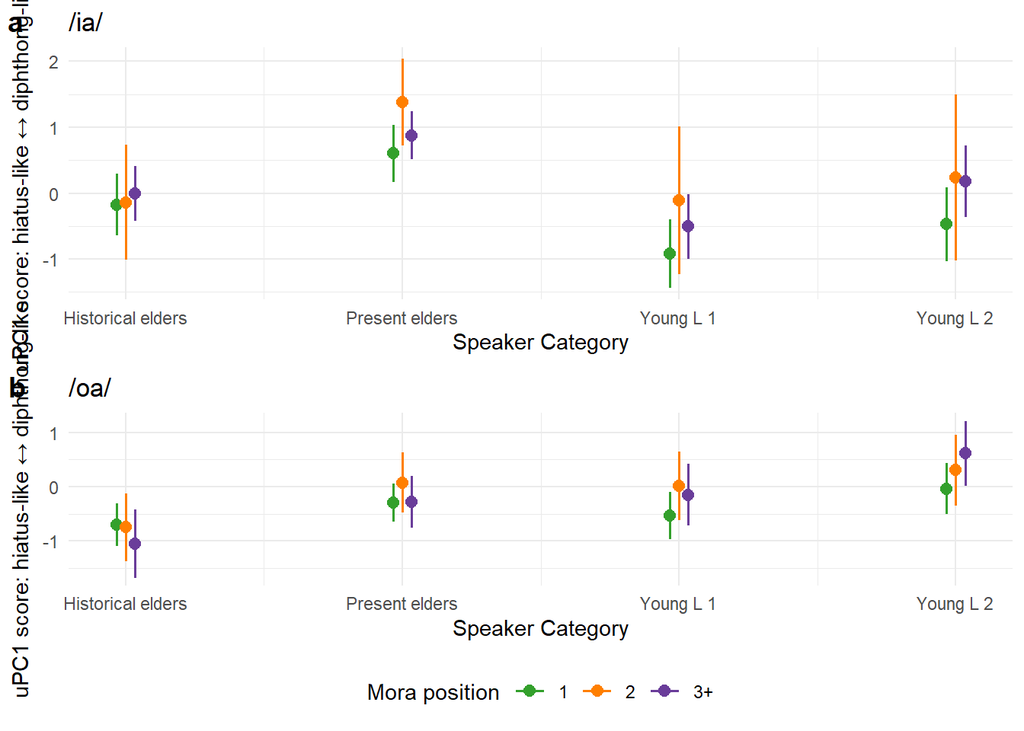

```r
plots_combined_mora <- cowplot::plot_grid(PC1_CatMoraPosia, PC1_CatMoraPosoa,
                            labels = c("a", "b"), ncol = 1, align = "c", axis = "l")



plots_combined_mora
```

3. Save

**Click here to view code.**

```r
ggsave(here("Figures", "Plots", "RegressionAnalysis", "CatMoracombined.png"),  plots_combined_mora, width = 5, height = 9, bg = 'white')
```

#### 10.7.1.4 /ea/ category* morpheme boundary (Manuscript Figure 11 )

1. Rename factor levels so that the labels are more informative

**Click here to view code.**

```r
 ea$category <- factor(ea$category,
                                       levels = c("Historical", "PresentElder", "L1", "L2"),
                                 labels = c("Historical elders", "Present elders", "Young L1", "Young L2"))

hyp.mod.ea_renamed <-  lmer(PC1 ~ category * (participant_gender +   complex   +c.(mean_rate_transf) ) + final_pause +    prev_c_tongue + (1   | Speaker) + (1  | word.alt.format), data=ea, REML=F)
```

**Click here to view code.**

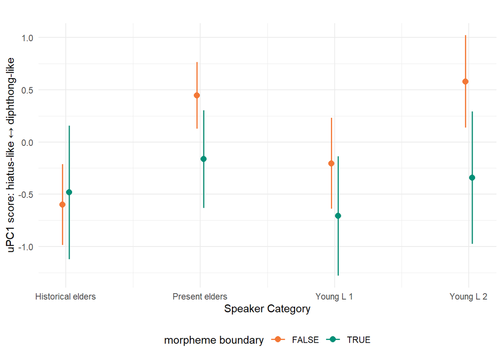

```r
PC1_CatComplexea <- plot_model(hyp.mod.ea_renamed, type = "pred", terms = c("category", "complex"),
            title = " ", axis.title = c("Speaker Category", "uPC1 score: hiatus-like ↔ diphthong-like"),
          legend.title="morpheme boundary") +
  scale_color_manual(values = c("TRUE" = "#018F77", "FALSE" = "#f37735")) +
  theme_minimal() +
  theme(legend.position = "bottom")

PC1_CatComplexea
```

**Click here to view code.**

```r
ggsave(here("Figures", "Plots", "RegressionAnalysis", "eaPC1CatComplex.png"),  PC1_CatComplexea, height = 10, width = 15, units = "cm", bg = 'white')
```

#### 10.7.1.5 /ua/ morpheme boundary (Manuscript Figure 12 )

**Click here to view code.**

```r
 ua$complex <- factor(ua$complex, levels = c("FALSE", "TRUE"))
```

**Click here to view code.**

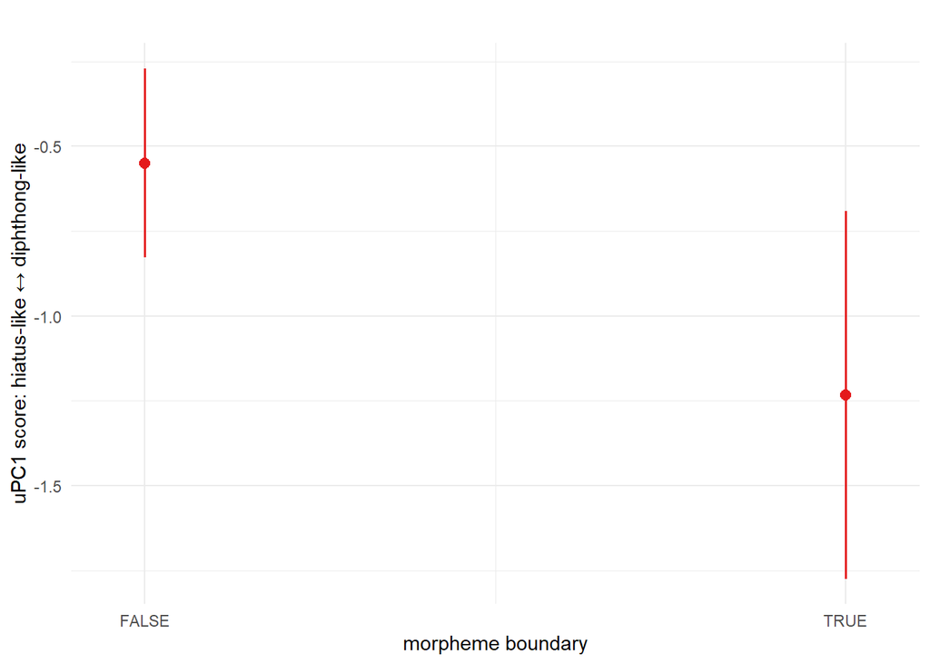

```r
PC1_Complexua <-  plot_model(hyp.mod.ua, type = "pred", terms = c("complex"),
            title = " ", axis.title = c("morpheme boundary", "uPC1 score: hiatus-like ↔ diphthong-like")) +
  theme_minimal() +
  theme(legend.position = "bottom")

PC1_Complexua
```

**Click here to view code.**

```r
ggsave(here("Figures", "Plots", "RegressionAnalysis", "uaPC1Complex.png"),  PC1_Complexua, height = 10, width = 15, units = "cm", bg = 'white')
```

# 11 Speaker intercept analysis (Manuscript §4.3.1)

## 11.1 Plot showing distribution of uPC results per speaker (Manuscript Figure 13)

This plot uses a data frame created in Section 8.4.

1. Filter out mid tokens, count number of high and low uPC1 tokens.

**Click here to view code.**

```r
per_speaker_PC_results <- results_extreme_all %>%
  filter(PC1cat != "mid") %>%
  select(MatchId, Speaker, PC1cat, sequence) %>%
  group_by(Speaker, sequence, PC1cat) %>%
  count()
```

2. Only include speakers who have all 4 sequences

**Click here to view code.**

```r
per_speaker_PC_results <- per_speaker_PC_results %>%
  group_by(Speaker) %>%
  filter(n_distinct(sequence) == 4) %>%
  ungroup()
```

3. Order data, with speakers with most low scoring tokens first

**Click here to view code.**

```r
speaker_order <- per_speaker_PC_results %>%
  group_by(Speaker) %>%
  mutate(total_n = sum(n)) %>%
  filter(PC1cat == "low") %>%
  summarise(prop_low = sum(n) / first(total_n)) %>%
  arrange(desc(prop_low)) %>%
  pull(Speaker)

per_speaker_PC_results$Speaker <- factor(per_speaker_PC_results$Speaker, levels = speaker_order)
```

4. Adjust order of sequences

**Click here to view code.**

```r
per_speaker_PC_results$sequence <- factor(per_speaker_PC_results$sequence, levels = c("ia", "ea", "oa", "ua"))
```

5. Create plot + save

**Click here to view code.**

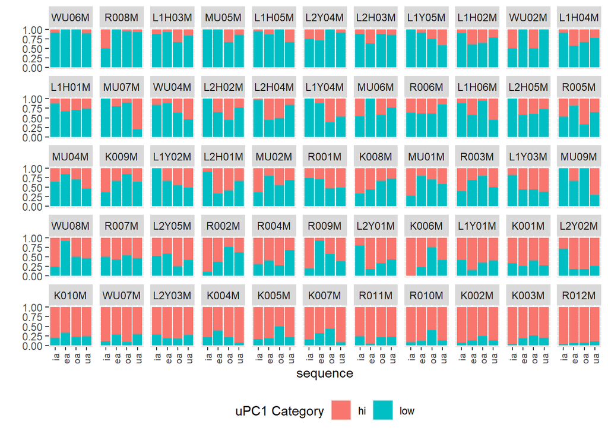

```r
per_speaker_plot <- ggplot(per_speaker_PC_results, aes(x = sequence, y = n, fill = PC1cat)) +
  geom_bar(stat = "identity", position = "fill") +
  labs(y = " ", x = "sequence") +
  theme(axis.text.x = element_text(angle = 90, hjust = 1, vjust = 0.5, size = 8)) +
   scale_fill_manual(name = "uPC1 Category", values = c("hi" = "#F8766D", "low" = "#00BFC4")) +
  facet_wrap(~ Speaker, nrow = 5) +
 theme(legend.position="bottom")

per_speaker_plot
```

**Click here to view code.**

```r
ggsave(here("Figures", "Plots", "SpeakerInterceptAnalysis", "PC1ScoresPerSpeakerPerSeq.pdf"), per_speaker_plot, width = 30, height = 15, units = "cm")
```

## 11.2 Speaker intercepts analysis + visualisation (Manuscript Figure 14)

1. Read in data if need be

**Click here to view code.**

```r
speaker_intercepts_ea <- read.csv(here( "Data", "speaker_intercepts_ea.csv")) %>%
  select(-X, -sequence) %>%
  rename(ea_speaker_intercept = Intercept)

speaker_intercepts_ia <- read.csv(here("Data", "speaker_intercepts_ia.csv")) %>%
  select(-X, -sequence) %>%
  rename(ia_speaker_intercept = Intercept)

speaker_intercepts_oa <- read.csv(here("Data", "speaker_intercepts_oa.csv")) %>%
   select(-X, -sequence) %>%
  rename(oa_speaker_intercept = Intercept)

speaker_intercepts_ua <- read.csv(here("Data", "speaker_intercepts_ua.csv")) %>%
  select(-X, -sequence) %>%
  rename(ua_speaker_intercept = Intercept)
```

2. Create combined data frame of all intercepts

**Click here to view code.**

```r
speaker_intercepts_all <- speaker_intercepts_ea %>%
  left_join(speaker_intercepts_ia, by = "Speaker") %>%
  left_join(speaker_intercepts_oa, by = "Speaker") %>%
  left_join(speaker_intercepts_ua, by = "Speaker")

write.csv(speaker_intercepts_all, here("Data","opening_seqs_speaker_intercepts.csv"))
```

3. Define function for creating correlation plot. This is an adapted version of the pairscor.fnc() function (used above) from the languageR() package (Baayen 2022). It rounds p values <0.001 as such.

**Click here to view code.**

```r
pairscor.fnc_custom  <- function(data, hist = TRUE, smooth = TRUE,
  cex.points = 1, col.points = "darkgrey") {
  panel.hist <- function(x, ...) {
    usr <- graphics::par("usr"); on.exit(graphics::par(usr))
    graphics::par(usr = c(usr[1:2], 0, 1.5) )
    h <- hist(x, plot = FALSE)
    breaks <- h$breaks; nB <- length(breaks)
    y <- h$counts; y <- y/max(y)
    graphics::rect(breaks[-nB], 0, breaks[-1], y, ...)
  }

  pairscor.lower <- function(x, y, ...) {
    usr <- graphics::par("usr"); on.exit(graphics::par(usr))
    graphics::par(usr = c(0, 1, 0, 1))

    # Pearson correlation
    m = stats::cor.test(x, y)
    r = round(m$estimate, 2)  # Show r with 2 decimal places
    p = m$p.value
    p_display = ifelse(p < 0.001, "<0.001", round(p, 6))  # Modify p-value for display
    rtxt = paste("r =", r)
    ptxt = paste("p =", p_display)

    # Spearman correlation
    options(warn=-1)  # ignore warnings
    m2 = stats::cor.test(x, y, method="spearman")
    r2 = round(m2$estimate, 2)  # Show rs with 2 decimal places
    p2 = m2$p.value
    p2_display = ifelse(p2 < 0.001, "<0.001", round(p2, 4))  # Modify p-value for display
    rtxt2 = paste("rs =", r2)
    ptxt2 = paste("p =", p2_display)
    options(warn=0)

    graphics::text(0.5, 0.8, rtxt)
    graphics::text(0.5, 0.6, ptxt)
    graphics::lines(c(0.2, 0.8), c(0.5, 0.5))
    graphics::text(0.5, 0.4, rtxt2)
    graphics::text(0.5, 0.2, ptxt2)
  }

  panel.smooth2 = function (x, y, col = graphics::par("col"), bg = NA, pch = graphics::par("pch"),
    cex = 1, span = 2/3, iter = 3, ...) {
    graphics::points(x, y, pch = pch, col = col, bg = bg, cex = cex)
    ok <- is.finite(x) & is.finite(y)
    if (any(ok))
        graphics::lines(stats::lowess(x[ok], y[ok], f = span, iter = iter),
            col = "black", ...)
  }

  if (hist == TRUE) {
    if (smooth == TRUE) {
         graphics::pairs(data,
         diag.panel = panel.hist,
         lower.panel = pairscor.lower,
         upper.panel = panel.smooth2, col = col.points,
           cex = cex.points)
    } else {
       graphics::pairs(data,
         diag.panel = panel.hist,
         lower.panel = pairscor.lower)
    }
  } else {
    if (smooth == TRUE) {
        graphics::pairs(data, lower.panel = pairscor.lower,
        upper.panel = panel.smooth2, col = col.points,
        cex = cex.points)
    } else {
        graphics::pairs(data, lower.panel = pairscor.lower)
    }
  }
}
```

4. Create plot + save

**Click here to view code.**

```r
pdf(here("Figures", "Plots", "SpeakerInterceptAnalysis",  "SpeakerInterceptCorrelation.pdf"), width = 7, height = 5)


pairscor.fnc_custom(select(speaker_intercepts_all, ia_speaker_intercept, ea_speaker_intercept, oa_speaker_intercept, ua_speaker_intercept))

# Close the device to save the plot
dev.off()
```

# 12 Speaker category visualisations (Manuscript §4.3.2)

1. Data

**Click here to view code.**

```r
sequences = read.csv(here("Data", "formants_filtered_all.csv"))  %>%
  dplyr::select(Vowel,  MatchId,  word, After.Match, category, participant_gender, time, Formant, Frequency, Target.vowelCluster.start, Target.vowelCluster.end)

monophthongs = read.csv(here("Data", "monophthongsfinal.csv"))
```

2. Some data prep

**Click here to view code.**

```r
sequences$participant_gender = as.factor(sequences$participant_gender)
sequences$category = as.factor(sequences$category)
sequences$Vowel = as.factor(sequences$Vowel)

sequences$category_gender = interaction(sequences$participant_gender, sequences$category)
```

3. View Data

**Click here to view code.**

```r
vowels <- sequences


vowels %>%
  head(10) %>%
  kable() %>%
  kable_styling(font_size = 11) %>%
  scroll_box(width = "100%")
```

| Vowel | MatchId | word | After.Match | category | participant_gender | time | Formant | Frequency | Target.vowelCluster.start | Target.vowelCluster.end | category_gender |
| --- | --- | --- | --- | --- | --- | --- | --- | --- | --- | --- | --- |
| ea | g_12;em_12_903;n_31539-n_31540;p_28;#=ew_69_149484;prefix=00078-;[0]=ew_0_7982 | mea | hoki | PresentElder | M | 1 | F1_lobanov_2.0 | -0.7105541 | 95.284 | 95.344 | M.PresentElder |
| ea | g_12;em_12_903;n_31539-n_31540;p_28;#=ew_69_149484;prefix=00078-;[0]=ew_0_7982 | mea | hoki | PresentElder | M | 1 | F2_lobanov_2.0 | 0.2266319 | 95.284 | 95.344 | M.PresentElder |
| ea | g_12;em_12_903;n_31539-n_31540;p_28;#=ew_69_149484;prefix=00078-;[0]=ew_0_7982 | mea | hoki | PresentElder | M | 2 | F1_lobanov_2.0 | -0.3871576 | 95.284 | 95.344 | M.PresentElder |
| ea | g_12;em_12_903;n_31539-n_31540;p_28;#=ew_69_149484;prefix=00078-;[0]=ew_0_7982 | mea | hoki | PresentElder | M | 2 | F2_lobanov_2.0 | 0.3022614 | 95.284 | 95.344 | M.PresentElder |
| ea | g_12;em_12_903;n_31539-n_31540;p_28;#=ew_69_149484;prefix=00078-;[0]=ew_0_7982 | mea | hoki | PresentElder | M | 3 | F1_lobanov_2.0 | -0.0334427 | 95.284 | 95.344 | M.PresentElder |
| ea | g_12;em_12_903;n_31539-n_31540;p_28;#=ew_69_149484;prefix=00078-;[0]=ew_0_7982 | mea | hoki | PresentElder | M | 3 | F2_lobanov_2.0 | 0.3267298 | 95.284 | 95.344 | M.PresentElder |
| ea | g_12;em_12_903;n_31539-n_31540;p_28;#=ew_69_149484;prefix=00078-;[0]=ew_0_7982 | mea | hoki | PresentElder | M | 4 | F1_lobanov_2.0 | 0.2192108 | 95.284 | 95.344 | M.PresentElder |
| ea | g_12;em_12_903;n_31539-n_31540;p_28;#=ew_69_149484;prefix=00078-;[0]=ew_0_7982 | mea | hoki | PresentElder | M | 4 | F2_lobanov_2.0 | 0.3356274 | 95.284 | 95.344 | M.PresentElder |
| ea | g_12;em_12_903;n_31539-n_31540;p_28;#=ew_69_149484;prefix=00078-;[0]=ew_0_7982 | mea | hoki | PresentElder | M | 5 | F1_lobanov_2.0 | 0.3303783 | 95.284 | 95.344 | M.PresentElder |
| ea | g_12;em_12_903;n_31539-n_31540;p_28;#=ew_69_149484;prefix=00078-;[0]=ew_0_7982 | mea | hoki | PresentElder | M | 5 | F2_lobanov_2.0 | 0.3067102 | 95.284 | 95.344 | M.PresentElder |

3. Some more data prep

**Click here to view code.**

```r
vowels <- vowels %>%
  mutate(preceding = str_match(word, "(.*)[eiou]a")[,2] %>%
           str_extract("(wh|ng|[^:]{0,1}:*)$") %>%
           str_remove_all(":") %>%
           factor(),
         following = str_match(word, "[eiou]a(.*)")[,2] %>%
           str_extract("^[-:]*(wh|ng|[^:]{0,1}:*)") %>%
           str_remove_all("[-:]") %>%
           ifelse(.=="",
                  After.Match %>%
                   str_to_lower() %>%
                   str_extract("^([<>~?:\"' ]|-)*(wh|ng|.{0,1})") %>%
                   str_remove("[<>~?:\"' -]+") %>%
                   paste0("$", .),
                 .) %>%
           factor(),
         time_left = exp(-(time-1)/1.5),
         time_right = exp(-(9-time)/1.5),
         duration = Target.vowelCluster.end - Target.vowelCluster.start,
         preceding_category_gender = paste(preceding, category_gender) %>% factor(),
         following_category_gender = paste(following, category_gender) %>% factor(),
  ) %>%
  group_by(MatchId) %>%
  mutate(traj_start=time==min(time)) %>%
  ungroup()
```

4. Nest data

**Click here to view code.**

```r
vowels <- vowels %>%
    group_by(Vowel, Formant) %>%
    nest()
```

5. Fit GAMs to the data

**Click here to view code.**

```r
vowels <- vowels %>%
  mutate(
    model = map(
      data, # We are applying a function to the entries of the `data` column.
      # This is the function we are applying (introduced with a ~)
      ~ bam(
          # Here's our formula.
          Frequency ~
            category_gender +
            s(time, by=category_gender, k=9) +
            s(duration, k=9) +
            ti(time,duration,k=c(9,9)) +
            s(time_left, preceding_category_gender, bs="re") +
            s(time_right, following_category_gender, bs="re"),
          data = .x,
          method = 'fREML',
          discrete = TRUE,
          AR.start=.x$traj_start, rho=0.7
        )
      )
  )
```

6. Get predictions

**Click here to view code.**

```r
to_predict <- list(
  "time" = seq(from=1, to=9, by=1), # All years
  "category_gender" =
    c("M.L1","M.L2","M.Historical","M.PresentElder",
      "F.L1","F.L2","F.Historical","F.PresentElder"
    )
)


vowels <- vowels %>%
  mutate(
    prediction = map(
      model, # This time we're applying the function to all the models.
      # We again introduce the function with '~', and indicate where the model
      # goes with '.x'.
      ~ get_predictions(model = .x, cond = to_predict, rm.ranef=T, print.summary = FALSE)
    )
  )
```

7. View predictions

**Click here to view code.**

```r
vowels$prediction[[1]] %>%
    kable() %>%
    kable_styling() %>%
    scroll_box(width = "100%")
```

| category_gender | time | duration | time_left | preceding_category_gender | time_right | following_category_gender | fit | CI | rm.ranef |
| --- | --- | --- | --- | --- | --- | --- | --- | --- | --- |
| M.L1 | 1 | 0.14 | 0.0694835 | m M.PresentElder | 0.0694835 | $k F.PresentElder | 0.3001625 | 0.2184892 | s(time_left,preceding_category_gender),s(time_right,following_category_gender) |
| M.L2 | 1 | 0.14 | 0.0694835 | m M.PresentElder | 0.0694835 | $k F.PresentElder | -0.1640612 | 0.2196264 | s(time_left,preceding_category_gender),s(time_right,following_category_gender) |
| M.Historical | 1 | 0.14 | 0.0694835 | m M.PresentElder | 0.0694835 | $k F.PresentElder | 0.7094868 | 0.2141206 | s(time_left,preceding_category_gender),s(time_right,following_category_gender) |
| M.PresentElder | 1 | 0.14 | 0.0694835 | m M.PresentElder | 0.0694835 | $k F.PresentElder | 0.2734123 | 0.1937801 | s(time_left,preceding_category_gender),s(time_right,following_category_gender) |
| F.L1 | 1 | 0.14 | 0.0694835 | m M.PresentElder | 0.0694835 | $k F.PresentElder | 0.2205627 | 0.2131089 | s(time_left,preceding_category_gender),s(time_right,following_category_gender) |
| F.L2 | 1 | 0.14 | 0.0694835 | m M.PresentElder | 0.0694835 | $k F.PresentElder | -0.2211095 | 0.2260973 | s(time_left,preceding_category_gender),s(time_right,following_category_gender) |
| F.Historical | 1 | 0.14 | 0.0694835 | m M.PresentElder | 0.0694835 | $k F.PresentElder | 0.7048686 | 0.2472512 | s(time_left,preceding_category_gender),s(time_right,following_category_gender) |
| F.PresentElder | 1 | 0.14 | 0.0694835 | m M.PresentElder | 0.0694835 | $k F.PresentElder | 0.3553471 | 0.2003759 | s(time_left,preceding_category_gender),s(time_right,following_category_gender) |
| M.L1 | 2 | 0.14 | 0.0694835 | m M.PresentElder | 0.0694835 | $k F.PresentElder | 0.7156480 | 0.1327896 | s(time_left,preceding_category_gender),s(time_right,following_category_gender) |
| M.L2 | 2 | 0.14 | 0.0694835 | m M.PresentElder | 0.0694835 | $k F.PresentElder | 0.1732826 | 0.1351625 | s(time_left,preceding_category_gender),s(time_right,following_category_gender) |
| M.Historical | 2 | 0.14 | 0.0694835 | m M.PresentElder | 0.0694835 | $k F.PresentElder | 1.0463242 | 0.1464127 | s(time_left,preceding_category_gender),s(time_right,following_category_gender) |
| M.PresentElder | 2 | 0.14 | 0.0694835 | m M.PresentElder | 0.0694835 | $k F.PresentElder | 0.6597681 | 0.1132917 | s(time_left,preceding_category_gender),s(time_right,following_category_gender) |
| F.L1 | 2 | 0.14 | 0.0694835 | m M.PresentElder | 0.0694835 | $k F.PresentElder | 0.6956143 | 0.1302862 | s(time_left,preceding_category_gender),s(time_right,following_category_gender) |
| F.L2 | 2 | 0.14 | 0.0694835 | m M.PresentElder | 0.0694835 | $k F.PresentElder | 0.1317779 | 0.1406179 | s(time_left,preceding_category_gender),s(time_right,following_category_gender) |
| F.Historical | 2 | 0.14 | 0.0694835 | m M.PresentElder | 0.0694835 | $k F.PresentElder | 1.2555968 | 0.1548018 | s(time_left,preceding_category_gender),s(time_right,following_category_gender) |
| F.PresentElder | 2 | 0.14 | 0.0694835 | m M.PresentElder | 0.0694835 | $k F.PresentElder | 0.7232717 | 0.1161893 | s(time_left,preceding_category_gender),s(time_right,following_category_gender) |
| M.L1 | 3 | 0.14 | 0.0694835 | m M.PresentElder | 0.0694835 | $k F.PresentElder | 1.0766336 | 0.0948775 | s(time_left,preceding_category_gender),s(time_right,following_category_gender) |
| M.L2 | 3 | 0.14 | 0.0694835 | m M.PresentElder | 0.0694835 | $k F.PresentElder | 0.5072483 | 0.0967902 | s(time_left,preceding_category_gender),s(time_right,following_category_gender) |
| M.Historical | 3 | 0.14 | 0.0694835 | m M.PresentElder | 0.0694835 | $k F.PresentElder | 1.3605645 | 0.1193179 | s(time_left,preceding_category_gender),s(time_right,following_category_gender) |
| M.PresentElder | 3 | 0.14 | 0.0694835 | m M.PresentElder | 0.0694835 | $k F.PresentElder | 0.9317287 | 0.0758709 | s(time_left,preceding_category_gender),s(time_right,following_category_gender) |
| F.L1 | 3 | 0.14 | 0.0694835 | m M.PresentElder | 0.0694835 | $k F.PresentElder | 1.1664112 | 0.0949919 | s(time_left,preceding_category_gender),s(time_right,following_category_gender) |
| F.L2 | 3 | 0.14 | 0.0694835 | m M.PresentElder | 0.0694835 | $k F.PresentElder | 0.4976774 | 0.1028665 | s(time_left,preceding_category_gender),s(time_right,following_category_gender) |
| F.Historical | 3 | 0.14 | 0.0694835 | m M.PresentElder | 0.0694835 | $k F.PresentElder | 1.7134630 | 0.1168335 | s(time_left,preceding_category_gender),s(time_right,following_category_gender) |
| F.PresentElder | 3 | 0.14 | 0.0694835 | m M.PresentElder | 0.0694835 | $k F.PresentElder | 0.9954177 | 0.0773528 | s(time_left,preceding_category_gender),s(time_right,following_category_gender) |
| M.L1 | 4 | 0.14 | 0.0694835 | m M.PresentElder | 0.0694835 | $k F.PresentElder | 1.3215932 | 0.0834248 | s(time_left,preceding_category_gender),s(time_right,following_category_gender) |
| M.L2 | 4 | 0.14 | 0.0694835 | m M.PresentElder | 0.0694835 | $k F.PresentElder | 0.7683137 | 0.0851868 | s(time_left,preceding_category_gender),s(time_right,following_category_gender) |
| M.Historical | 4 | 0.14 | 0.0694835 | m M.PresentElder | 0.0694835 | $k F.PresentElder | 1.5683260 | 0.1120174 | s(time_left,preceding_category_gender),s(time_right,following_category_gender) |
| M.PresentElder | 4 | 0.14 | 0.0694835 | m M.PresentElder | 0.0694835 | $k F.PresentElder | 1.1104969 | 0.0632759 | s(time_left,preceding_category_gender),s(time_right,following_category_gender) |
| F.L1 | 4 | 0.14 | 0.0694835 | m M.PresentElder | 0.0694835 | $k F.PresentElder | 1.4898334 | 0.0849787 | s(time_left,preceding_category_gender),s(time_right,following_category_gender) |
| F.L2 | 4 | 0.14 | 0.0694835 | m M.PresentElder | 0.0694835 | $k F.PresentElder | 0.8151049 | 0.0916013 | s(time_left,preceding_category_gender),s(time_right,following_category_gender) |
| F.Historical | 4 | 0.14 | 0.0694835 | m M.PresentElder | 0.0694835 | $k F.PresentElder | 2.0492417 | 0.1071094 | s(time_left,preceding_category_gender),s(time_right,following_category_gender) |
| F.PresentElder | 4 | 0.14 | 0.0694835 | m M.PresentElder | 0.0694835 | $k F.PresentElder | 1.1457513 | 0.0645823 | s(time_left,preceding_category_gender),s(time_right,following_category_gender) |
| M.L1 | 5 | 0.14 | 0.0694835 | m M.PresentElder | 0.0694835 | $k F.PresentElder | 1.3912724 | 0.0818021 | s(time_left,preceding_category_gender),s(time_right,following_category_gender) |
| M.L2 | 5 | 0.14 | 0.0694835 | m M.PresentElder | 0.0694835 | $k F.PresentElder | 0.9395691 | 0.0833101 | s(time_left,preceding_category_gender),s(time_right,following_category_gender) |
| M.Historical | 5 | 0.14 | 0.0694835 | m M.PresentElder | 0.0694835 | $k F.PresentElder | 1.6649460 | 0.1124548 | s(time_left,preceding_category_gender),s(time_right,following_category_gender) |
| M.PresentElder | 5 | 0.14 | 0.0694835 | m M.PresentElder | 0.0694835 | $k F.PresentElder | 1.2363837 | 0.0610670 | s(time_left,preceding_category_gender),s(time_right,following_category_gender) |
| F.L1 | 5 | 0.14 | 0.0694835 | m M.PresentElder | 0.0694835 | $k F.PresentElder | 1.5967851 | 0.0842728 | s(time_left,preceding_category_gender),s(time_right,following_category_gender) |
| F.L2 | 5 | 0.14 | 0.0694835 | m M.PresentElder | 0.0694835 | $k F.PresentElder | 1.0228821 | 0.0902144 | s(time_left,preceding_category_gender),s(time_right,following_category_gender) |
| F.Historical | 5 | 0.14 | 0.0694835 | m M.PresentElder | 0.0694835 | $k F.PresentElder | 2.1939633 | 0.1066237 | s(time_left,preceding_category_gender),s(time_right,following_category_gender) |
| F.PresentElder | 5 | 0.14 | 0.0694835 | m M.PresentElder | 0.0694835 | $k F.PresentElder | 1.2033547 | 0.0625954 | s(time_left,preceding_category_gender),s(time_right,following_category_gender) |
| M.L1 | 6 | 0.14 | 0.0694835 | m M.PresentElder | 0.0694835 | $k F.PresentElder | 1.3573475 | 0.0862461 | s(time_left,preceding_category_gender),s(time_right,following_category_gender) |
| M.L2 | 6 | 0.14 | 0.0694835 | m M.PresentElder | 0.0694835 | $k F.PresentElder | 1.0152661 | 0.0879352 | s(time_left,preceding_category_gender),s(time_right,following_category_gender) |
| M.Historical | 6 | 0.14 | 0.0694835 | m M.PresentElder | 0.0694835 | $k F.PresentElder | 1.6846007 | 0.1159308 | s(time_left,preceding_category_gender),s(time_right,following_category_gender) |
| M.PresentElder | 6 | 0.14 | 0.0694835 | m M.PresentElder | 0.0694835 | $k F.PresentElder | 1.3359165 | 0.0657450 | s(time_left,preceding_category_gender),s(time_right,following_category_gender) |
| F.L1 | 6 | 0.14 | 0.0694835 | m M.PresentElder | 0.0694835 | $k F.PresentElder | 1.5553870 | 0.0893239 | s(time_left,preceding_category_gender),s(time_right,following_category_gender) |
| F.L2 | 6 | 0.14 | 0.0694835 | m M.PresentElder | 0.0694835 | $k F.PresentElder | 1.0814261 | 0.0956797 | s(time_left,preceding_category_gender),s(time_right,following_category_gender) |
| F.Historical | 6 | 0.14 | 0.0694835 | m M.PresentElder | 0.0694835 | $k F.PresentElder | 2.0972918 | 0.1115566 | s(time_left,preceding_category_gender),s(time_right,following_category_gender) |
| F.PresentElder | 6 | 0.14 | 0.0694835 | m M.PresentElder | 0.0694835 | $k F.PresentElder | 1.1707673 | 0.0679519 | s(time_left,preceding_category_gender),s(time_right,following_category_gender) |
| M.L1 | 7 | 0.14 | 0.0694835 | m M.PresentElder | 0.0694835 | $k F.PresentElder | 1.3075952 | 0.1039840 | s(time_left,preceding_category_gender),s(time_right,following_category_gender) |
| M.L2 | 7 | 0.14 | 0.0694835 | m M.PresentElder | 0.0694835 | $k F.PresentElder | 1.0041329 | 0.1057389 | s(time_left,preceding_category_gender),s(time_right,following_category_gender) |
| M.Historical | 7 | 0.14 | 0.0694835 | m M.PresentElder | 0.0694835 | $k F.PresentElder | 1.7350257 | 0.1306622 | s(time_left,preceding_category_gender),s(time_right,following_category_gender) |
| M.PresentElder | 7 | 0.14 | 0.0694835 | m M.PresentElder | 0.0694835 | $k F.PresentElder | 1.3685773 | 0.0834576 | s(time_left,preceding_category_gender),s(time_right,following_category_gender) |
| F.L1 | 7 | 0.14 | 0.0694835 | m M.PresentElder | 0.0694835 | $k F.PresentElder | 1.4232194 | 0.1094167 | s(time_left,preceding_category_gender),s(time_right,following_category_gender) |
| F.L2 | 7 | 0.14 | 0.0694835 | m M.PresentElder | 0.0694835 | $k F.PresentElder | 1.0361559 | 0.1156048 | s(time_left,preceding_category_gender),s(time_right,following_category_gender) |
| F.Historical | 7 | 0.14 | 0.0694835 | m M.PresentElder | 0.0694835 | $k F.PresentElder | 1.8254579 | 0.1281818 | s(time_left,preceding_category_gender),s(time_right,following_category_gender) |
| F.PresentElder | 7 | 0.14 | 0.0694835 | m M.PresentElder | 0.0694835 | $k F.PresentElder | 1.1056578 | 0.0878951 | s(time_left,preceding_category_gender),s(time_right,following_category_gender) |
| M.L1 | 8 | 0.14 | 0.0694835 | m M.PresentElder | 0.0694835 | $k F.PresentElder | 1.3293709 | 0.1543553 | s(time_left,preceding_category_gender),s(time_right,following_category_gender) |
| M.L2 | 8 | 0.14 | 0.0694835 | m M.PresentElder | 0.0694835 | $k F.PresentElder | 0.9732296 | 0.1579444 | s(time_left,preceding_category_gender),s(time_right,following_category_gender) |
| M.Historical | 8 | 0.14 | 0.0694835 | m M.PresentElder | 0.0694835 | $k F.PresentElder | 1.7113881 | 0.1784391 | s(time_left,preceding_category_gender),s(time_right,following_category_gender) |
| M.PresentElder | 8 | 0.14 | 0.0694835 | m M.PresentElder | 0.0694835 | $k F.PresentElder | 1.3487861 | 0.1320141 | s(time_left,preceding_category_gender),s(time_right,following_category_gender) |
| F.L1 | 8 | 0.14 | 0.0694835 | m M.PresentElder | 0.0694835 | $k F.PresentElder | 1.2722696 | 0.1681584 | s(time_left,preceding_category_gender),s(time_right,following_category_gender) |
| F.L2 | 8 | 0.14 | 0.0694835 | m M.PresentElder | 0.0694835 | $k F.PresentElder | 0.9371674 | 0.1736587 | s(time_left,preceding_category_gender),s(time_right,following_category_gender) |
| F.Historical | 8 | 0.14 | 0.0694835 | m M.PresentElder | 0.0694835 | $k F.PresentElder | 1.3983980 | 0.1794817 | s(time_left,preceding_category_gender),s(time_right,following_category_gender) |
| F.PresentElder | 8 | 0.14 | 0.0694835 | m M.PresentElder | 0.0694835 | $k F.PresentElder | 0.9931836 | 0.1418941 | s(time_left,preceding_category_gender),s(time_right,following_category_gender) |
| M.L1 | 9 | 0.14 | 0.0694835 | m M.PresentElder | 0.0694835 | $k F.PresentElder | 1.4305750 | 0.2623701 | s(time_left,preceding_category_gender),s(time_right,following_category_gender) |
| M.L2 | 9 | 0.14 | 0.0694835 | m M.PresentElder | 0.0694835 | $k F.PresentElder | 1.0181457 | 0.2651580 | s(time_left,preceding_category_gender),s(time_right,following_category_gender) |
| M.Historical | 9 | 0.14 | 0.0694835 | m M.PresentElder | 0.0694835 | $k F.PresentElder | 1.7052147 | 0.2805931 | s(time_left,preceding_category_gender),s(time_right,following_category_gender) |
| M.PresentElder | 9 | 0.14 | 0.0694835 | m M.PresentElder | 0.0694835 | $k F.PresentElder | 1.3105094 | 0.2319252 | s(time_left,preceding_category_gender),s(time_right,following_category_gender) |
| F.L1 | 9 | 0.14 | 0.0694835 | m M.PresentElder | 0.0694835 | $k F.PresentElder | 1.1581208 | 0.2917110 | s(time_left,preceding_category_gender),s(time_right,following_category_gender) |
| F.L2 | 9 | 0.14 | 0.0694835 | m M.PresentElder | 0.0694835 | $k F.PresentElder | 0.8814072 | 0.2939164 | s(time_left,preceding_category_gender),s(time_right,following_category_gender) |
| F.Historical | 9 | 0.14 | 0.0694835 | m M.PresentElder | 0.0694835 | $k F.PresentElder | 0.8772815 | 0.2967280 | s(time_left,preceding_category_gender),s(time_right,following_category_gender) |
| F.PresentElder | 9 | 0.14 | 0.0694835 | m M.PresentElder | 0.0694835 | $k F.PresentElder | 0.8361188 | 0.2525032 | s(time_left,preceding_category_gender),s(time_right,following_category_gender) |

8. Unnest

**Click here to view code.**

```r
predictions <- vowels %>%
  select(
    Vowel, Formant, prediction
  ) %>%
  unnest(prediction)

predictions %>%
  kable() %>%
  kable_styling() %>%
  scroll_box(width = "100%")
```

| Vowel | Formant | category_gender | time | duration | time_left | preceding_category_gender | time_right | following_category_gender | fit | CI | rm.ranef |
| --- | --- | --- | --- | --- | --- | --- | --- | --- | --- | --- | --- |
| ea | F1_lobanov_2.0 | M.L1 | 1 | 0.14 | 0.0694835 | m M.PresentElder | 0.0694835 | $k F.PresentElder | 0.3001625 | 0.2184892 | s(time_left,preceding_category_gender),s(time_right,following_category_gender) |
| ea | F1_lobanov_2.0 | M.L2 | 1 | 0.14 | 0.0694835 | m M.PresentElder | 0.0694835 | $k F.PresentElder | -0.1640612 | 0.2196264 | s(time_left,preceding_category_gender),s(time_right,following_category_gender) |
| ea | F1_lobanov_2.0 | M.Historical | 1 | 0.14 | 0.0694835 | m M.PresentElder | 0.0694835 | $k F.PresentElder | 0.7094868 | 0.2141206 | s(time_left,preceding_category_gender),s(time_right,following_category_gender) |
| ea | F1_lobanov_2.0 | M.PresentElder | 1 | 0.14 | 0.0694835 | m M.PresentElder | 0.0694835 | $k F.PresentElder | 0.2734123 | 0.1937801 | s(time_left,preceding_category_gender),s(time_right,following_category_gender) |
| ea | F1_lobanov_2.0 | F.L1 | 1 | 0.14 | 0.0694835 | m M.PresentElder | 0.0694835 | $k F.PresentElder | 0.2205627 | 0.2131089 | s(time_left,preceding_category_gender),s(time_right,following_category_gender) |
| ea | F1_lobanov_2.0 | F.L2 | 1 | 0.14 | 0.0694835 | m M.PresentElder | 0.0694835 | $k F.PresentElder | -0.2211095 | 0.2260973 | s(time_left,preceding_category_gender),s(time_right,following_category_gender) |
| ea | F1_lobanov_2.0 | F.Historical | 1 | 0.14 | 0.0694835 | m M.PresentElder | 0.0694835 | $k F.PresentElder | 0.7048686 | 0.2472512 | s(time_left,preceding_category_gender),s(time_right,following_category_gender) |
| ea | F1_lobanov_2.0 | F.PresentElder | 1 | 0.14 | 0.0694835 | m M.PresentElder | 0.0694835 | $k F.PresentElder | 0.3553471 | 0.2003759 | s(time_left,preceding_category_gender),s(time_right,following_category_gender) |
| ea | F1_lobanov_2.0 | M.L1 | 2 | 0.14 | 0.0694835 | m M.PresentElder | 0.0694835 | $k F.PresentElder | 0.7156480 | 0.1327896 | s(time_left,preceding_category_gender),s(time_right,following_category_gender) |
| ea | F1_lobanov_2.0 | M.L2 | 2 | 0.14 | 0.0694835 | m M.PresentElder | 0.0694835 | $k F.PresentElder | 0.1732826 | 0.1351625 | s(time_left,preceding_category_gender),s(time_right,following_category_gender) |
| ea | F1_lobanov_2.0 | M.Historical | 2 | 0.14 | 0.0694835 | m M.PresentElder | 0.0694835 | $k F.PresentElder | 1.0463242 | 0.1464127 | s(time_left,preceding_category_gender),s(time_right,following_category_gender) |
| ea | F1_lobanov_2.0 | M.PresentElder | 2 | 0.14 | 0.0694835 | m M.PresentElder | 0.0694835 | $k F.PresentElder | 0.6597681 | 0.1132917 | s(time_left,preceding_category_gender),s(time_right,following_category_gender) |
| ea | F1_lobanov_2.0 | F.L1 | 2 | 0.14 | 0.0694835 | m M.PresentElder | 0.0694835 | $k F.PresentElder | 0.6956143 | 0.1302862 | s(time_left,preceding_category_gender),s(time_right,following_category_gender) |
| ea | F1_lobanov_2.0 | F.L2 | 2 | 0.14 | 0.0694835 | m M.PresentElder | 0.0694835 | $k F.PresentElder | 0.1317779 | 0.1406179 | s(time_left,preceding_category_gender),s(time_right,following_category_gender) |
| ea | F1_lobanov_2.0 | F.Historical | 2 | 0.14 | 0.0694835 | m M.PresentElder | 0.0694835 | $k F.PresentElder | 1.2555968 | 0.1548018 | s(time_left,preceding_category_gender),s(time_right,following_category_gender) |
| ea | F1_lobanov_2.0 | F.PresentElder | 2 | 0.14 | 0.0694835 | m M.PresentElder | 0.0694835 | $k F.PresentElder | 0.7232717 | 0.1161893 | s(time_left,preceding_category_gender),s(time_right,following_category_gender) |
| ea | F1_lobanov_2.0 | M.L1 | 3 | 0.14 | 0.0694835 | m M.PresentElder | 0.0694835 | $k F.PresentElder | 1.0766336 | 0.0948775 | s(time_left,preceding_category_gender),s(time_right,following_category_gender) |
| ea | F1_lobanov_2.0 | M.L2 | 3 | 0.14 | 0.0694835 | m M.PresentElder | 0.0694835 | $k F.PresentElder | 0.5072483 | 0.0967902 | s(time_left,preceding_category_gender),s(time_right,following_category_gender) |
| ea | F1_lobanov_2.0 | M.Historical | 3 | 0.14 | 0.0694835 | m M.PresentElder | 0.0694835 | $k F.PresentElder | 1.3605645 | 0.1193179 | s(time_left,preceding_category_gender),s(time_right,following_category_gender) |
| ea | F1_lobanov_2.0 | M.PresentElder | 3 | 0.14 | 0.0694835 | m M.PresentElder | 0.0694835 | $k F.PresentElder | 0.9317287 | 0.0758709 | s(time_left,preceding_category_gender),s(time_right,following_category_gender) |
| ea | F1_lobanov_2.0 | F.L1 | 3 | 0.14 | 0.0694835 | m M.PresentElder | 0.0694835 | $k F.PresentElder | 1.1664112 | 0.0949919 | s(time_left,preceding_category_gender),s(time_right,following_category_gender) |
| ea | F1_lobanov_2.0 | F.L2 | 3 | 0.14 | 0.0694835 | m M.PresentElder | 0.0694835 | $k F.PresentElder | 0.4976774 | 0.1028665 | s(time_left,preceding_category_gender),s(time_right,following_category_gender) |
| ea | F1_lobanov_2.0 | F.Historical | 3 | 0.14 | 0.0694835 | m M.PresentElder | 0.0694835 | $k F.PresentElder | 1.7134630 | 0.1168335 | s(time_left,preceding_category_gender),s(time_right,following_category_gender) |
| ea | F1_lobanov_2.0 | F.PresentElder | 3 | 0.14 | 0.0694835 | m M.PresentElder | 0.0694835 | $k F.PresentElder | 0.9954177 | 0.0773528 | s(time_left,preceding_category_gender),s(time_right,following_category_gender) |
| ea | F1_lobanov_2.0 | M.L1 | 4 | 0.14 | 0.0694835 | m M.PresentElder | 0.0694835 | $k F.PresentElder | 1.3215932 | 0.0834248 | s(time_left,preceding_category_gender),s(time_right,following_category_gender) |
| ea | F1_lobanov_2.0 | M.L2 | 4 | 0.14 | 0.0694835 | m M.PresentElder | 0.0694835 | $k F.PresentElder | 0.7683137 | 0.0851868 | s(time_left,preceding_category_gender),s(time_right,following_category_gender) |
| ea | F1_lobanov_2.0 | M.Historical | 4 | 0.14 | 0.0694835 | m M.PresentElder | 0.0694835 | $k F.PresentElder | 1.5683260 | 0.1120174 | s(time_left,preceding_category_gender),s(time_right,following_category_gender) |
| ea | F1_lobanov_2.0 | M.PresentElder | 4 | 0.14 | 0.0694835 | m M.PresentElder | 0.0694835 | $k F.PresentElder | 1.1104969 | 0.0632759 | s(time_left,preceding_category_gender),s(time_right,following_category_gender) |
| ea | F1_lobanov_2.0 | F.L1 | 4 | 0.14 | 0.0694835 | m M.PresentElder | 0.0694835 | $k F.PresentElder | 1.4898334 | 0.0849787 | s(time_left,preceding_category_gender),s(time_right,following_category_gender) |
| ea | F1_lobanov_2.0 | F.L2 | 4 | 0.14 | 0.0694835 | m M.PresentElder | 0.0694835 | $k F.PresentElder | 0.8151049 | 0.0916013 | s(time_left,preceding_category_gender),s(time_right,following_category_gender) |

[output cut: 546 more lines]

9. Format predictions

**Click here to view code.**

```r
predictions <- predictions %>%
   select( # Remove unneeded variables
     -CI, -duration, -time_left, -time_right, -preceding_category_gender, -following_category_gender, -rm.ranef
   ) %>%
  pivot_wider( # Pivot
    names_from = Formant,
    values_from = fit
  )

predictions %>%
  head() %>%
  kable() %>%
  kable_styling() %>%
  scroll_box(width = "100%")
```

| Vowel | category_gender | time | F1_lobanov_2.0 | F2_lobanov_2.0 |
| --- | --- | --- | --- | --- |
| ea | M.L1 | 1 | 0.3001625 | 0.4922088 |
| ea | M.L2 | 1 | -0.1640612 | 0.9291806 |
| ea | M.Historical | 1 | 0.7094868 | 0.6521965 |
| ea | M.PresentElder | 1 | 0.2734123 | 0.6664922 |
| ea | F.L1 | 1 | 0.2205627 | 0.5966031 |
| ea | F.L2 | 1 | -0.2211095 | 0.8688500 |

**Click here to view code.**

```r
predictions <- predictions %>%
  mutate(category = str_remove(category_gender, ".*[.]"),
         participant_gender = str_remove(category_gender, "[.].*"),)
```

10. Prepare data sets for each speaker category

**Click here to view code.**

```r
PresentElderseq = predictions %>%
    filter(category == "PresentElder")
Historicalseq = predictions %>%
    filter(category == "Historical")
L1seq = predictions %>%
    filter(category == "L1")
L2seq = predictions %>%
    filter(category == "L2")

PresentEldermono = monophthongs %>%
    filter(category == "PresentElder")
Historicalmono = monophthongs %>%
    filter(category == "Historical")
L1mono = monophthongs %>%
    filter(category == "L1")
L2mono = monophthongs %>%
    filter(category == "L2")

presentfirst_obs <- PresentElderseq %>%
    group_by(Vowel, participant_gender) %>%
    slice(which.min(time))
histfirst_obs <- Historicalseq %>%
    group_by(Vowel, participant_gender) %>%
    slice(which.min(time))
L1first_obs <- L1seq %>%
    group_by(Vowel, participant_gender) %>%
    slice(which.min(time))
L2first_obs <- L2seq %>%
    group_by(Vowel, participant_gender) %>%
    slice(which.min(time))
```

##Historical elders plot

1. Calculate the mean for each vowel to annotate ellipses on plot

**Click here to view code.**

```r
Hist_i_means <- Historicalmono %>%
  filter(Target.teAkaSegment == "i") %>%
  mutate(meanF1 = mean(F1_lobanov_2.0)) %>%
  mutate(meanF2 = mean(F2_lobanov_2.0)) %>%
  select(Target.teAkaSegment, meanF1, meanF2) %>%
  unique()

Hist_e_means <- Historicalmono %>%
  filter(Target.teAkaSegment == "e") %>%
  mutate(meanF1 = mean(F1_lobanov_2.0)) %>%
  mutate(meanF2 = mean(F2_lobanov_2.0)) %>%
  select(Target.teAkaSegment, meanF1, meanF2) %>%
  unique()

Hist_a_means <- Historicalmono %>%
  filter(Target.teAkaSegment == "a") %>%
  mutate(meanF1 = mean(F1_lobanov_2.0)) %>%
  mutate(meanF2 = mean(F2_lobanov_2.0)) %>%
  select(Target.teAkaSegment, meanF1, meanF2) %>%
  unique()

Hist_o_means <- Historicalmono %>%
  filter(Target.teAkaSegment == "o") %>%
  mutate(meanF1 = mean(F1_lobanov_2.0)) %>%
  mutate(meanF2 = mean(F2_lobanov_2.0)) %>%
  select(Target.teAkaSegment, meanF1, meanF2) %>%
  unique()


Hist_u_means <- Historicalmono %>%
  filter(Target.teAkaSegment == "u") %>%
  mutate(meanF1 = mean(F1_lobanov_2.0)) %>%
  mutate(meanF2 = mean(F2_lobanov_2.0)) %>%
  select(Target.teAkaSegment, meanF1, meanF2) %>%
  unique()

Historicalmono_means <- rbind(Hist_i_means, Hist_e_means, Hist_a_means, Hist_o_means, Hist_u_means) %>%
  rename(F1_lobanov_2.0 = meanF1) %>%
  rename(F2_lobanov_2.0 = meanF2)
```

2. Create plot

**Click here to view code.**

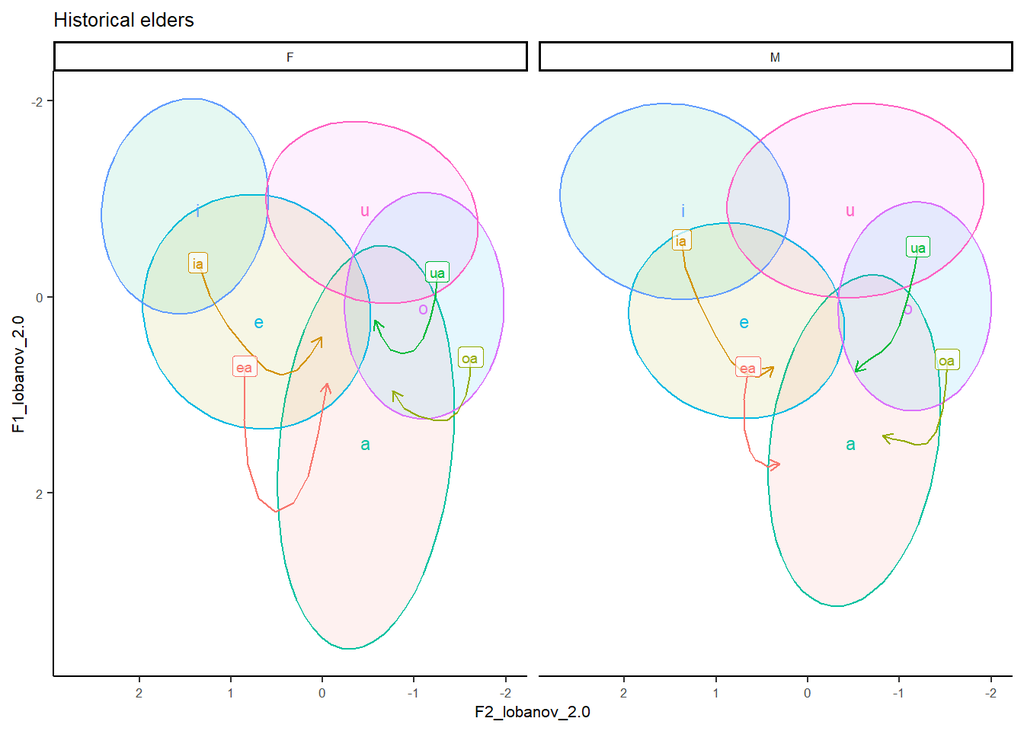

```r
hist_plot <- Historicalmono %>%
  ggplot(aes(x = F2_lobanov_2.0, y = F1_lobanov_2.0, colour = Target.teAkaSegment)) +
 stat_ellipse(level = 0.67, geom = "polygon", alpha = 0.1, aes(fill = Target.teAkaSegment), show.legend = FALSE) +
  scale_x_reverse() + scale_y_reverse() +
  geom_text(data=Historicalmono_means,
            aes(x = F2_lobanov_2.0, y = F1_lobanov_2.0, label = Target.teAkaSegment),  show.legend = FALSE, size = 3) +
  geom_path(data=Historicalseq, aes(
      x = F2_lobanov_2.0,
      y = F1_lobanov_2.0,
      colour = Vowel), arrow = arrow(length = unit(2, "mm")), show.legend = FALSE) +
    geom_label(
    data = histfirst_obs,
    aes(
      x = F2_lobanov_2.0,
      y = F1_lobanov_2.0,
      colour = Vowel, label=Vowel),
    show.legend = FALSE,
    size = 2.5, # Make labels smaller...
    alpha = 0.7 # ...and slightly transparent.
  )

hist_gender <- hist_plot +   labs(title = "Historical elders")  + facet_grid(~ participant_gender)   + theme_classic()+
theme( text = element_text(size = 8))

hist_gender
```

## 12.1 Present elders plot

1. Calculate the mean for each vowel to annotate ellipses on plot

**Click here to view code.**

```r
PE_i_means <- PresentEldermono %>%
  filter(Target.teAkaSegment == "i") %>%
  mutate(meanF1 = mean(F1_lobanov_2.0)) %>%
  mutate(meanF2 = mean(F2_lobanov_2.0)) %>%
  select(Target.teAkaSegment, meanF1, meanF2) %>%
  unique()

PE_e_means <- PresentEldermono %>%
  filter(Target.teAkaSegment == "e") %>%
  mutate(meanF1 = mean(F1_lobanov_2.0)) %>%
  mutate(meanF2 = mean(F2_lobanov_2.0)) %>%
  select(Target.teAkaSegment, meanF1, meanF2) %>%
  unique()

PE_a_means <- PresentEldermono %>%
  filter(Target.teAkaSegment == "a") %>%
  mutate(meanF1 = mean(F1_lobanov_2.0)) %>%
  mutate(meanF2 = mean(F2_lobanov_2.0)) %>%
  select(Target.teAkaSegment, meanF1, meanF2) %>%
  unique()

PE_o_means <- PresentEldermono %>%
  filter(Target.teAkaSegment == "o") %>%
  mutate(meanF1 = mean(F1_lobanov_2.0)) %>%
  mutate(meanF2 = mean(F2_lobanov_2.0)) %>%
  select(Target.teAkaSegment, meanF1, meanF2) %>%
  unique()


PE_u_means <- PresentEldermono %>%
  filter(Target.teAkaSegment == "u") %>%
  mutate(meanF1 = mean(F1_lobanov_2.0)) %>%
  mutate(meanF2 = mean(F2_lobanov_2.0)) %>%
  select(Target.teAkaSegment, meanF1, meanF2) %>%
  unique()

PresentEldermono_means <- rbind(PE_i_means, PE_e_means, PE_a_means, PE_o_means, PE_u_means) %>%
  rename(F1_lobanov_2.0 = meanF1) %>%
  rename(F2_lobanov_2.0 = meanF2)
```

2. Create plot

**Click here to view code.**

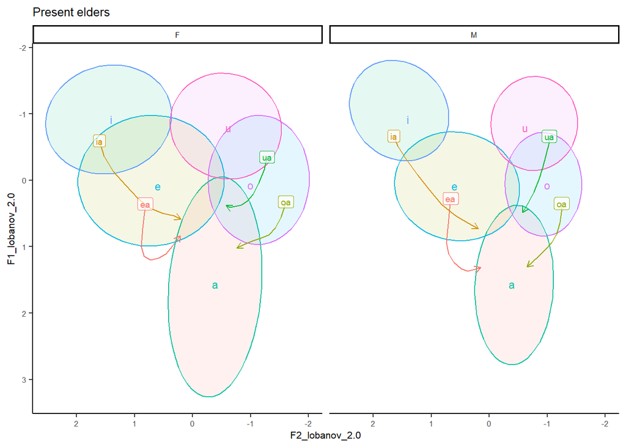

```r
present_plot <- PresentEldermono %>%
  ggplot(aes(x = F2_lobanov_2.0, y = F1_lobanov_2.0, colour = Target.teAkaSegment)) +
 stat_ellipse(level = 0.67, geom = "polygon", alpha = 0.1, aes(fill = Target.teAkaSegment), show.legend = FALSE) +
  scale_x_reverse() + scale_y_reverse() +
    geom_text(data= PresentEldermono_means,
            aes(x = F2_lobanov_2.0, y = F1_lobanov_2.0, label = Target.teAkaSegment),  show.legend = FALSE, size = 3) +
  geom_path(data=PresentElderseq, aes(
      x = F2_lobanov_2.0,
      y = F1_lobanov_2.0,
      colour = Vowel), arrow = arrow(length = unit(2, "mm")), show.legend = FALSE) +
    geom_label(
    data = presentfirst_obs,
    aes(
      x = F2_lobanov_2.0,
      y = F1_lobanov_2.0,
      colour = Vowel, label=Vowel),
    show.legend = FALSE,
    size = 2.5, # Make labels smaller...
    alpha = 0.7 # ...and slightly transparent.
  )

present_gender <- present_plot + labs(title = "Present elders") + facet_grid(~ participant_gender)    + theme_classic()+
theme( text = element_text(size = 8))

present_gender
```

## 12.2 L1 plot

1. Calculate the mean for each vowel to annotate ellipses on plot

**Click here to view code.**

```r
L1_i_means <- L1mono %>%
  filter(Target.teAkaSegment == "i") %>%
  mutate(meanF1 = mean(F1_lobanov_2.0)) %>%
  mutate(meanF2 = mean(F2_lobanov_2.0)) %>%
  select(Target.teAkaSegment, meanF1, meanF2) %>%
  unique()

L1_e_means <- L1mono %>%
  filter(Target.teAkaSegment == "e") %>%
  mutate(meanF1 = mean(F1_lobanov_2.0)) %>%
  mutate(meanF2 = mean(F2_lobanov_2.0)) %>%
  select(Target.teAkaSegment, meanF1, meanF2) %>%
  unique()

L1_a_means <- L1mono %>%
  filter(Target.teAkaSegment == "a") %>%
  mutate(meanF1 = mean(F1_lobanov_2.0)) %>%
  mutate(meanF2 = mean(F2_lobanov_2.0)) %>%
  select(Target.teAkaSegment, meanF1, meanF2) %>%
  unique()

L1_o_means <- L1mono %>%
  filter(Target.teAkaSegment == "o") %>%
  mutate(meanF1 = mean(F1_lobanov_2.0)) %>%
  mutate(meanF2 = mean(F2_lobanov_2.0)) %>%
  select(Target.teAkaSegment, meanF1, meanF2) %>%
  unique()


L1_u_means <- L1mono %>%
  filter(Target.teAkaSegment == "u") %>%
  mutate(meanF1 = mean(F1_lobanov_2.0)) %>%
  mutate(meanF2 = mean(F2_lobanov_2.0)) %>%
  select(Target.teAkaSegment, meanF1, meanF2) %>%
  unique()

L1mono_means <- rbind(L1_i_means, L1_e_means, L1_a_means, L1_o_means, L1_u_means) %>%
  rename(F1_lobanov_2.0 = meanF1) %>%
  rename(F2_lobanov_2.0 = meanF2)
```

2. Create plot

**Click here to view code.**

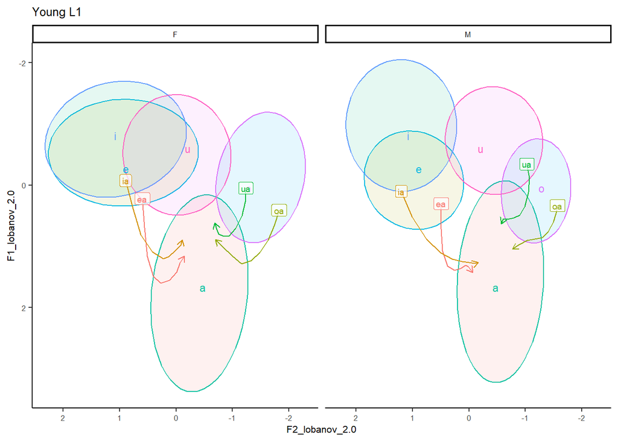

```r
L1_plot <- L1mono %>%
  ggplot(aes(x = F2_lobanov_2.0, y = F1_lobanov_2.0, colour = Target.teAkaSegment)) +
 stat_ellipse(level = 0.67, geom = "polygon", alpha = 0.1, aes(fill = Target.teAkaSegment), show.legend = FALSE) +
  scale_x_reverse() + scale_y_reverse() +
   geom_text(data=L1mono_means,
            aes(x = F2_lobanov_2.0, y = F1_lobanov_2.0, label = Target.teAkaSegment),  show.legend = FALSE, size = 3) +
  geom_path(data=L1seq, aes(
      x = F2_lobanov_2.0,
      y = F1_lobanov_2.0,
      colour = Vowel), arrow = arrow(length = unit(2, "mm")), show.legend = FALSE) +
    geom_label(
    data = L1first_obs,
    aes(
      x = F2_lobanov_2.0,
      y = F1_lobanov_2.0,
      colour = Vowel, label=Vowel),
    show.legend = FALSE,
    size = 2.5, # Make labels smaller...
    alpha = 0.7 # ...and slightly transparent.
  )

L1_gender <- L1_plot + labs(title = "Young L1")  + facet_grid(~ participant_gender) + theme_classic()+
theme( text = element_text(size = 8))

L1_gender
```

## 12.3 L2 plot

1. Calculate the mean for each vowel to annotate ellipses on plot

**Click here to view code.**

```r
L2_i_means <- L2mono %>%
  filter(Target.teAkaSegment == "i") %>%
  mutate(meanF1 = mean(F1_lobanov_2.0)) %>%
  mutate(meanF2 = mean(F2_lobanov_2.0)) %>%
  select(Target.teAkaSegment, meanF1, meanF2) %>%
  unique()

L2_e_means <- L2mono %>%
  filter(Target.teAkaSegment == "e") %>%
  mutate(meanF1 = mean(F1_lobanov_2.0)) %>%
  mutate(meanF2 = mean(F2_lobanov_2.0)) %>%
  select(Target.teAkaSegment, meanF1, meanF2) %>%
  unique()

L2_a_means <- L2mono %>%
  filter(Target.teAkaSegment == "a") %>%
  mutate(meanF1 = mean(F1_lobanov_2.0)) %>%
  mutate(meanF2 = mean(F2_lobanov_2.0)) %>%
  select(Target.teAkaSegment, meanF1, meanF2) %>%
  unique()

L2_o_means <- L2mono %>%
  filter(Target.teAkaSegment == "o") %>%
  mutate(meanF1 = mean(F1_lobanov_2.0)) %>%
  mutate(meanF2 = mean(F2_lobanov_2.0)) %>%
  select(Target.teAkaSegment, meanF1, meanF2) %>%
  unique()


L2_u_means <- L2mono %>%
  filter(Target.teAkaSegment == "u") %>%
  mutate(meanF1 = mean(F1_lobanov_2.0)) %>%
  mutate(meanF2 = mean(F2_lobanov_2.0)) %>%
  select(Target.teAkaSegment, meanF1, meanF2) %>%
  unique()

L2mono_means <- rbind(L2_i_means, L2_e_means, L2_a_means, L2_o_means, L2_u_means) %>%
  rename(F1_lobanov_2.0 = meanF1) %>%
  rename(F2_lobanov_2.0 = meanF2)
```

2. Create plot

**Click here to view code.**

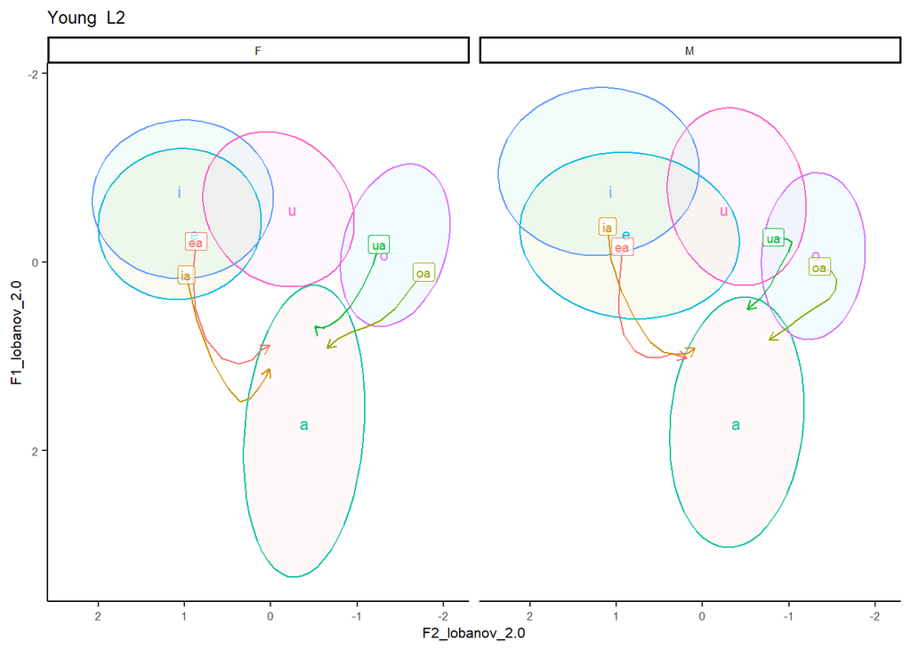

```r
L2_plot <- L2mono %>%
  ggplot(aes(x = F2_lobanov_2.0, y = F1_lobanov_2.0, colour = Target.teAkaSegment)) +
 stat_ellipse(level = 0.67, geom = "polygon", alpha = 0.05, aes(fill = Target.teAkaSegment), show.legend = FALSE) +
  scale_x_reverse() + scale_y_reverse() +
  geom_text(data=L2mono_means,
            aes(x = F2_lobanov_2.0, y = F1_lobanov_2.0, label = Target.teAkaSegment),  show.legend = FALSE, size = 3) +
  geom_path(data=L2seq, aes(
      x = F2_lobanov_2.0,
      y = F1_lobanov_2.0,
      colour = Vowel), arrow = arrow(length = unit(2, "mm")), show.legend = FALSE) +
    geom_label(
    data = L2first_obs,
    aes(
      x = F2_lobanov_2.0,
      y = F1_lobanov_2.0,
      colour = Vowel, label=Vowel),
    show.legend = FALSE,
    size = 2.5, # Make labels smaller...
    alpha = .7 # ...and slightly transparent.
  )

L2_gender <- L2_plot + labs(title = "Young  L2")  +facet_grid(~ participant_gender)  + theme_classic() +
theme( text = element_text(size = 8))

L2_gender
```

## 12.4 Combined plot (Manuscript Figure 15 )

**Click here to view code.**

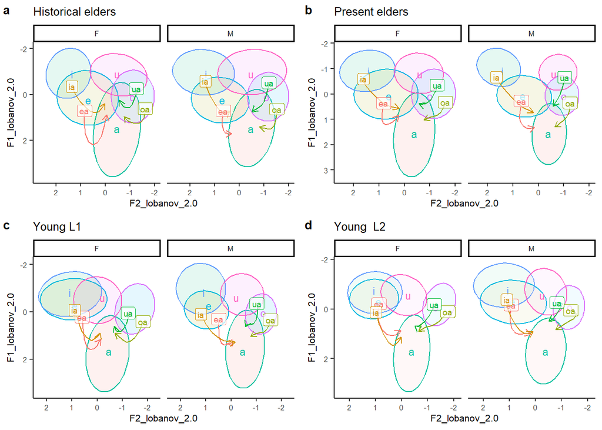

```r
plots_combined <- cowplot::plot_grid(hist_gender, present_gender,
                                     L1_gender, L2_gender,
                            labels = c("a", "b", "c", "d"), label_size = 10, ncol = 2, align = "c", axis = "l")



plots_combined
```

**Click here to view code.**

```r
ggsave(here("Figures", "Plots", "ChangeOverTime", "combined_plots_change.pdf"), width = 22, height = 14, units = "cm")
```

# 13 Data exploration: is there a relationship between raising of /e/ and merging of /ia/ and /ea/ (Manuscript §4.3.2)

To this, we examine if there’s a correlation between uPC1 for /ea/ and speakers F1 mean for /e/  
Look within speaker and gender categories

1. Calculate mean F1 for /e/, per speaker

**Click here to view code.**

```r
e_means <- monophthongs %>%
  select(Target.teAkaSegment, Speaker, F1_lobanov_2.0, participant_gender, category) %>%
  filter(Target.teAkaSegment == "e") %>%
  group_by(Speaker) %>%
  mutate(mean_F1_e = mean(F1_lobanov_2.0)) %>%
  select(-F1_lobanov_2.0) %>%
  unique()
```

2. Calculate mean PC1 per speaker

**Click here to view code.**

```r
PC1_mean_per_speaker_ea <- earesults %>%
  select(Speaker, PC1, participant_gender, category) %>%
  group_by(Speaker) %>%
  mutate(mean_PC1 = mean(PC1)) %>%
  select(-PC1) %>%
  unique()  %>%
  ungroup()
```

3. Join

**Click here to view code.**

```r
PC1_mean_per_speaker_ea <- PC1_mean_per_speaker_ea %>%
  left_join(e_means)
```

4. Function to run pairscor() by speaker category

**Click here to view code.**

```r
run_pairscor_by_category <- function(df, col1, col2, create_tibbles = FALSE, hist = FALSE, smooth = FALSE) {

  combos <- df %>% distinct(category)
  results <- list()

  for (i in seq_len(nrow(combos))) {
    cat_i <- combos$category[i]

    subset_df <- df %>% filter(category == cat_i)
    name <- paste(cat_i,  sep = "_") %>% make.names()

    if (create_tibbles) assign(name, subset_df, envir = .GlobalEnv)

    # Run pairscor.fnc_custom (plots automatically)
    res <- pairscor.fnc_custom(
      subset_df %>% select(all_of(c(col1, col2))),
      hist = hist,
      smooth = smooth
    )

    # Add a title on top of the plot
    title(main = paste(cat_i, sep = " × "), line = 2)

    # Store results
    results[[name]] <- res
  }

  return(results)
}
```

5. Run pairscor() on mean F1 and mean PC1 by speaker category

**Click here to view code.**

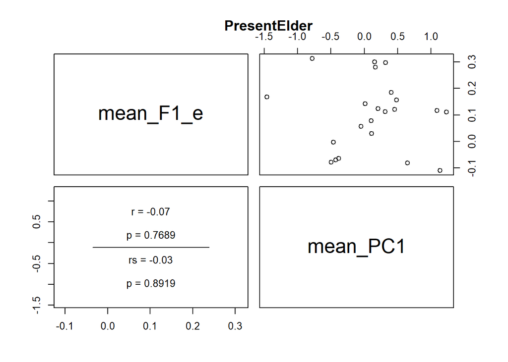

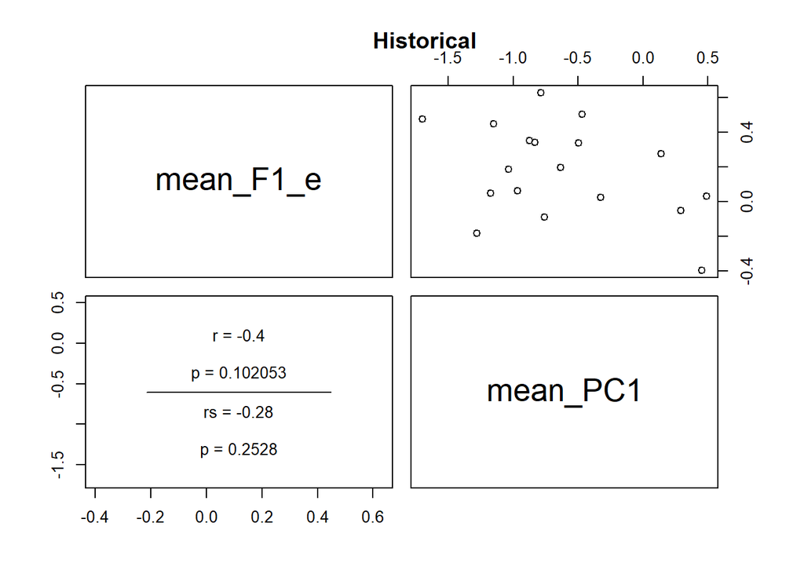

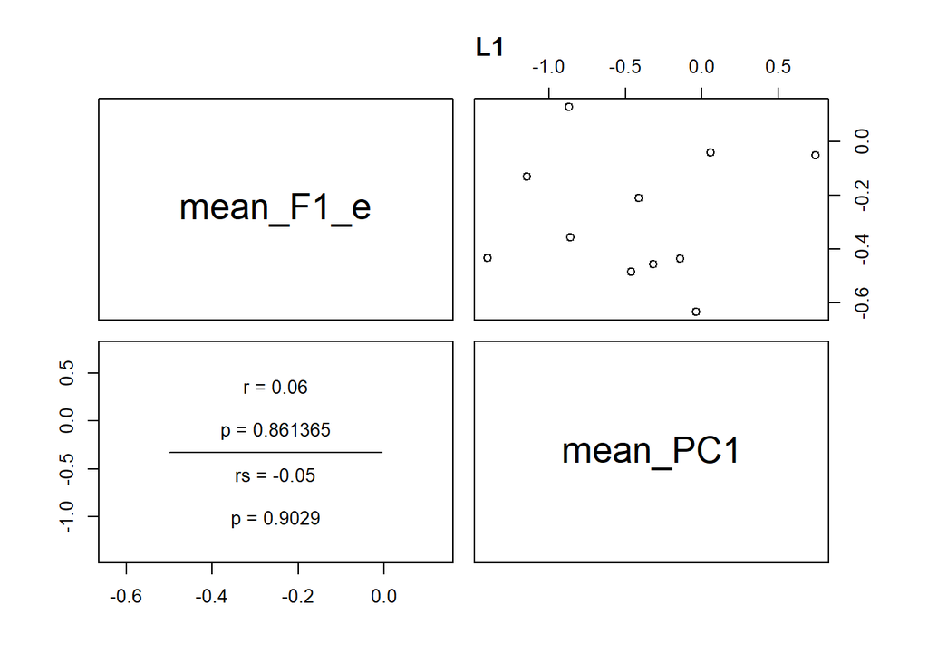

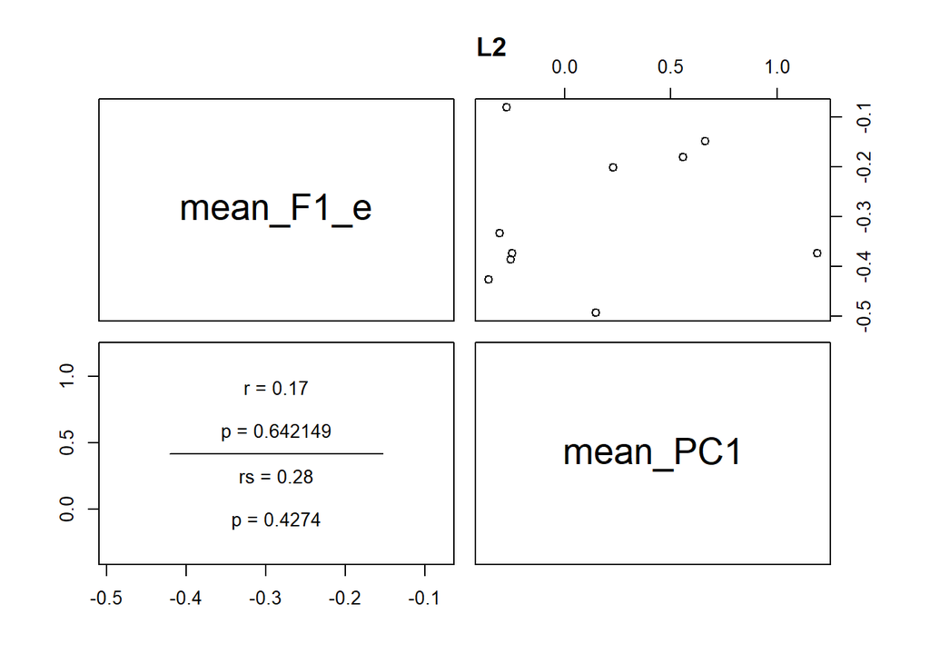

```r
results <- run_pairscor_by_category(PC1_mean_per_speaker_ea, "mean_F1_e", "mean_PC1", create_tibbles = TRUE)
```

No evidence of a correlation.

What about F1 of the onset of the sequence? Here we investigate if there’s a correlation between mean F1 of time point 1 of /ea/ and mean F1 of /e/

1. Calculate mean F1 for timepoint 1

**Click here to view code.**

```r
formants_filtered_ea <- read.csv(here("Data", "Filtered", "Formants", "ea.csv"))

F1_timepoint_1 <- formants_filtered_ea %>%
  select(MatchId, Speaker, time, Formant, Frequency) %>%
 filter(time == "1" & Formant == "F1_lobanov_2.0") %>%
 group_by(Speaker) %>%
  mutate(mean_F1_timepoint1 = mean(Frequency)) %>%
  ungroup()

F1_timepoint_1 <- F1_timepoint_1 %>%
  select(Speaker, mean_F1_timepoint1) %>%
  unique()
```

2. Join

**Click here to view code.**

```r
F1_timepoint_1 <- F1_timepoint_1 %>%
  left_join(e_means)
```

3. Run pairscor() by category

**Click here to view code.**

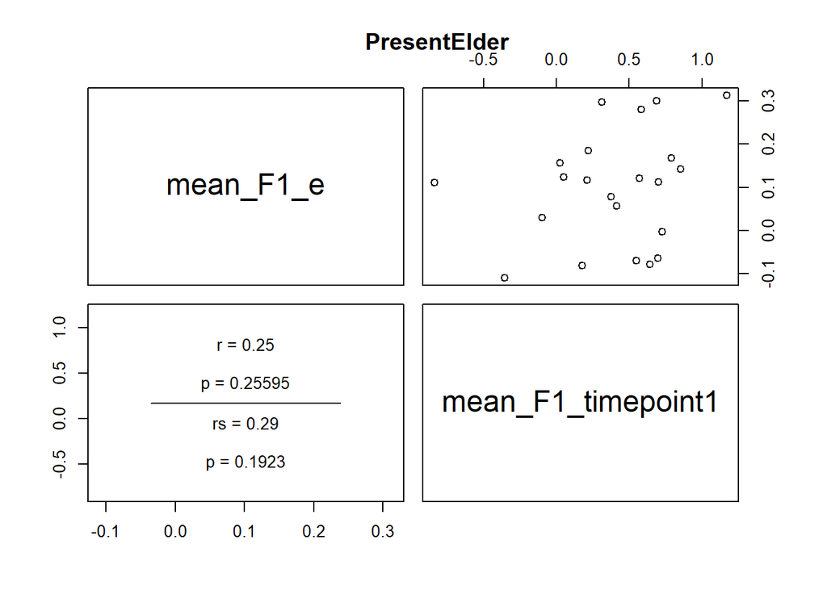

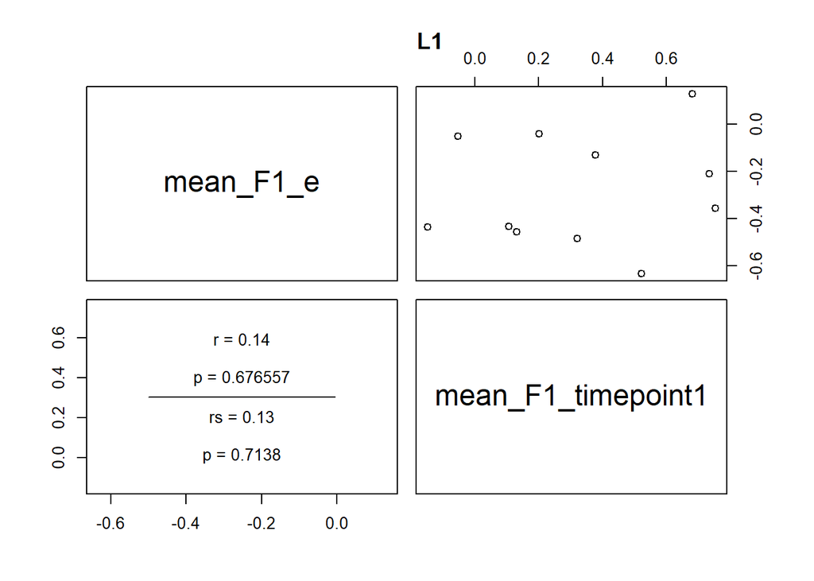

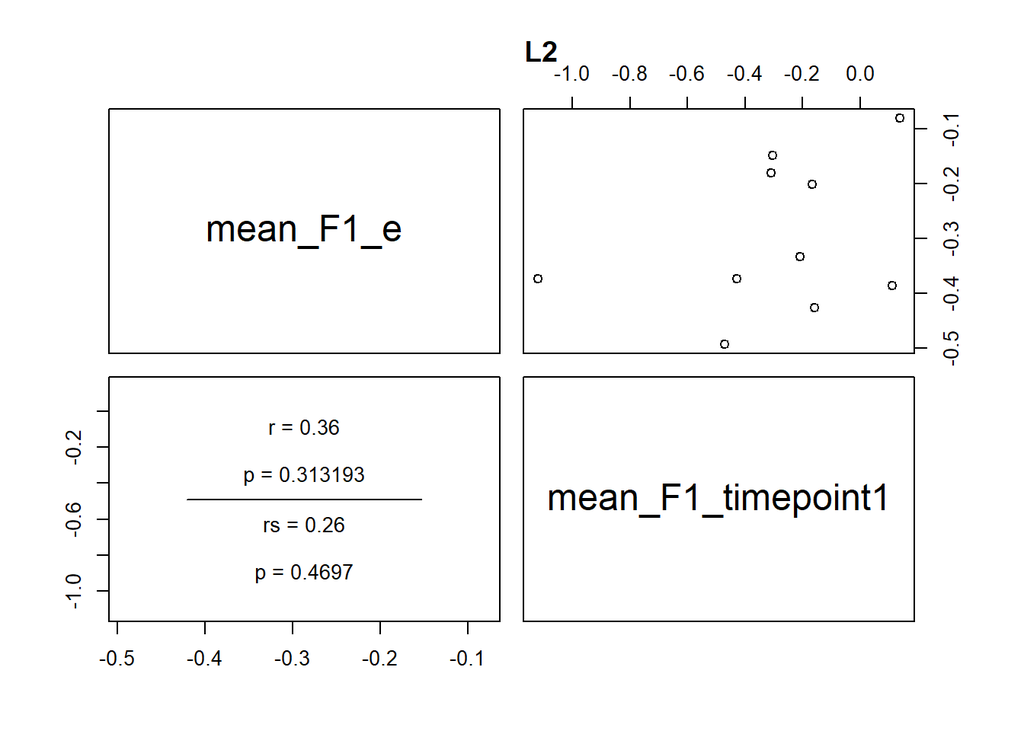

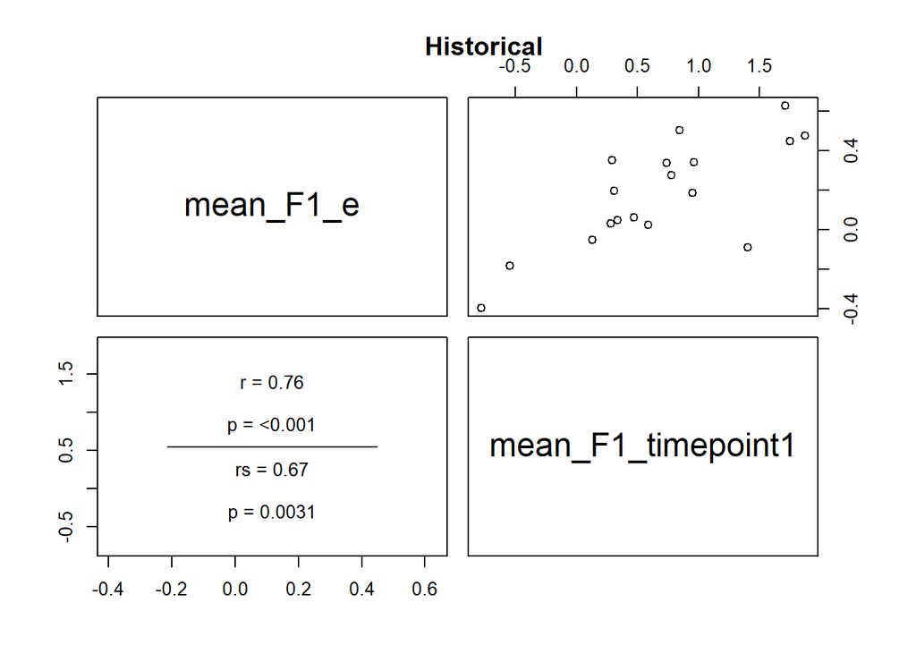

```r
results <- run_pairscor_by_category(F1_timepoint_1, "mean_F1_e", "mean_F1_timepoint1", create_tibbles = TRUE)
```

There’s only evidence of a correlation between mean F1 of /e/ and mean F1 of timepoint 1 for /ea/ for historical elders.

## References

Baayen, R. Harald. 2022. *languageR: Data Sets and Functions with “Analyzing Linguistic Data: A Practical Introduction to Statistics" by R. H. Baayen*. https://CRAN.R-project.org/package=languageR.

Brand, James, Jen Hay, Lynn Clark, Kevin Watson, and Márton Sóskuthy. 2021. “Systematic Co-Variation of Monophthongs Across Speakers of New Zealand English.” *Journal of Phonetics* 88: 101096.

Gubian, Michele, Jonathan Harrington, Mary Stevens, Florian Schiel, and Paul Warren. 2019. “Tracking the New Zealand English NEAR/SQUARE Merger Using Functional Principal Components Analysis.” In *Proceedings of INTERSPEECH 2019*, 296–300. International Speech Communication Association (ISCA).

Gubian, Michele, Francisco Torreira, and Lou Boves. 2015. “Using Functional Data Analysis for Investigating Multidimensional Dynamic Phonetic Contrasts.” *Journal of Phonetics* 49: 16–40.

Wilson Black, Joshua, and James Brand. 2022. *Nzilbb.vowels: Functions for Vowel Covariation Studies*. https://github.com/JoshuaWilsonBlack/nzilbb_vowels/tree/main.